# Analysing Sentences Backbone Communities

| Title | Year | Journal | Authors | Number sentences | Words Similarity |
| --- | --- | --- | --- | --- | --- |
| The delusion of certainty in Savage’s sure-thing principle | 1991 | Journal of Economic Psychology | Pope R.E. | 36 | 0.569 |
| [A More Robust Definition of Subjective Probability](https://http://www.jstor.org/stable/2951565) | 1992 | Econometrica | Mark J. Machina, David Schmeidler | 35 | 0.538 |
| [A Definition of Uncertainty Aversion](https://http://www.jstor.org/stable/2567015) | 1999 | The Review of Economic Studies | Larry G. Epstein | 23 | 0.551 |
| [Dynamic Choice and the Common Ratio Effect: An Experimental Investigation](https://http://www.jstor.org/stable/2566184) | 1998 | The Economic Journal | Robin P. Cubitt, Chris Starmer, Robert Sugden | 15 | 0.565 |
| Incorporating a stochastic element into decision theories | 1995 | European Economic Review | Loomes G. | 14 | 0.541 |
| [Bolker-Jeffrey Expected Utility Theory and Axiomatic Utilitarianism](https://http://www.jstor.org/stable/2298025) | 1990 | The Review of Economic Studies | John Broome | 14 | 0.540 |
| [THE ‘TRUE’ HYPOTHESIS OF DANIEL BERNOULLI: WHAT DID THE MARGINALISTS REALLY KNOW?](https://http://www.jstor.org/stable/23722513) | 1998 | History of Economic Ideas | Nicola Giocoli | 14 | 0.546 |
| Violations of the reduction and independence axioms in Allais-type and common-ratio effect experiments | 1992 | Journal of Economic Behavior and Organization | Carlin P. | 13 | 0.545 |
| [Uncertainty Aversion and Dynamic Consistency](https://http://www.jstor.org/stable/2527444) | 1996 | International Economic Review | Jurgen Eichberger, David Kelsey | 13 | 0.535 |
| [Induced Preferences, Nonadditive Beliefs, and Multiple Priors](https://http://www.jstor.org/stable/2648814) | 1999 | International Economic Review | David Kelsey, Frank Milne | 13 | 0.559 |

| Title | Year | Journal | Authors | Number sentences | Words Similarity |
| --- | --- | --- | --- | --- | --- |
| [Coping rationally with ambiguity: Robustness versus ambiguity-aversion](https://doi.org/10.1017/S0266267109990265) | 2009 | Economics and Philosophy | Nehring K. | 52 | 0.580 |
| [The ambiguity aversion literature: A critical assessment](https://doi.org/10.1017/S026626710999023X) | 2009 | Economics and Philosophy | Al-Najjar N.I. | 51 | 0.577 |
| [Incomplete preferences and rational intransitivity of choice](https://doi.org/10.1016/j.geb.2004.02.007) | 2005 | Games and Economic Behavior | Mandler M. | 48 | 0.597 |
| [Developments in Non-Expected Utility Theory: The Hunt for a Descriptive Theory of Choice under Risk](https://http://www.jstor.org/stable/2565292) | 2000 | Journal of Economic Literature | Chris Starmer | 34 | 0.555 |
| [Sequentially Rationalizable Choice](https://http://www.jstor.org/stable/30034586) | 2007 | The American Economic Review | Paola Manzini, Marco Mariotti | 34 | 0.587 |
| [A Smooth Model of Decision Making under Ambiguity](https://http://www.jstor.org/stable/3598753) | 2005 | Econometrica | Peter Klibanoff, Massimo Marinacci, Sujoy Mukerji | 34 | 0.545 |
| [Can anticipatory feelings explain anomalous choices of information sources?](https://doi.org/10.1016/j.geb.2005.06.004) | 2006 | Games and Economic Behavior | Eliaz K. | 33 | 0.565 |
| [Indifference or indecisiveness? Choice-theoretic foundations of incomplete preferences](https://doi.org/10.1016/j.geb.2005.06.007) | 2006 | Games and Economic Behavior | Eliaz K. | 30 | 0.576 |
| [A Bayesian Approach to Uncertainty Aversion](https://http://www.jstor.org/stable/3700659) | 2005 | The Review of Economic Studies | Yoram Halevy, Vincent Feltkamp | 30 | 0.566 |
| [Imprecise probabilistic beliefs as a context for decision-making under ambiguity](https://doi.org/10.1016/j.jet.2008.05.009) | 2009 | Journal of Economic Theory | Nehring K. | 29 | 0.563 |

| Title | Year | Journal | Authors | Number sentences | Words Similarity |
| --- | --- | --- | --- | --- | --- |
| [Hyperbolic discounting and time inconsistency in a native-exotic species conflict](https://doi.org/10.1016/j.reseneeco.2003.11.010) | 2004 | Resource and Energy Economics | Settle C. | 34 | 0.554 |
| [A theory of haste](https://doi.org/10.1016/j.jebo.2003.09.005) | 2005 | Journal of Economic Behavior and Organization | Brocas I. | 31 | 0.559 |
| [Modeling internal commitment mechanisms and self-control: A neuroeconomics approach to consumption-saving decisions](https://doi.org/10.1016/j.geb.2004.10.004) | 2005 | Games and Economic Behavior | Benhabib J. | 29 | 0.555 |
| [Inattentive consumers](https://doi.org/10.1016/j.jmoneco.2006.03.001) | 2006 | Journal of Monetary Economics | Reis R. | 29 | 0.593 |
| [Description, prescription and the choice of discount rates](https://doi.org/10.1016/j.ecolecon.2009.08.024) | 2009 | Ecological Economics | Baum S. | 28 | 0.559 |
| [Time Discounting and Time Preference: A Critical Review](https://http://www.jstor.org/stable/2698382) | 2002 | Journal of Economic Literature | Shane Frederick, George Loewenstein, Ted O’Donoghue | 24 | 0.551 |
| Life-cycle consumption under social interactions | 2001 | Journal of Economic Dynamics and Control | Binder M. | 23 | 0.567 |
| [Does ‘better’ discounting lead to ‘worse’ outcomes in long-run decisions? The dilemma of hyperbolic discounting](https://doi.org/10.1016/j.ecolecon.2005.05.013) | 2006 | Ecological Economics | Winkler R. | 23 | 0.556 |
| [Valuing future life and future lives: A framework for understanding discounting](https://doi.org/10.1016/j.joep.2006.05.007) | 2006 | Journal of Economic Psychology | Frederick S. | 22 | 0.562 |
| [Hyperbolic discounting and uniform savings floors](https://doi.org/10.1016/j.jpubeco.2008.03.008) | 2008 | Journal of Public Economics | Malin B. | 22 | 0.565 |

| Title | Year | Journal | Authors | Number sentences | Words Similarity |
| --- | --- | --- | --- | --- | --- |
| [Rethinking risk attitude: Aspiration as pure risk](https://doi.org/10.1007/s11238-006-0007-y) | 2006 | Theory and Decision | Davies G. | 59 | 0.559 |
| [Individual Preferences, Monetary Gambles, and Stock Market Participation: A Case for Narrow Framing](https://http://www.jstor.org/stable/30034331) | 2006 | The American Economic Review | Nicholas Barberis, Ming Huang, Richard H. Thaler | 40 | 0.558 |
| [Rationality crossovers](https://doi.org/10.1016/j.joep.2006.12.002) | 2007 | Journal of Economic Psychology | Cherry T.L. | 37 | 0.593 |
| [Ambiguity aversion and the equity premium puzzle: A re-examination of experimental data on repeated gambles](https://doi.org/10.1016/j.socec.2005.07.006) | 2005 | Journal of Socio Economics | Aloysius J.A. | 32 | 0.582 |
| [Rejecting small gambles under expected utility](https://doi.org/10.1016/j.econlet.2005.09.017) | 2006 | Economics Letters | Palacios-Huerta I. | 31 | 0.558 |
| A model of dynamic equilibrium asset pricing with heterogeneous beliefs and extraneous risk | 2000 | Journal of Economic Dynamics and Control | Basak S. | 28 | 0.569 |
| Rational escalation of costs by playing a sequence of unfavorable gambles: The martingale | 2003 | Journal of Economic Behavior and Organization | Aloysius J.A. | 27 | 0.575 |
| [The utility of gambling reconsidered](https://doi.org/10.1023/B:RISK.0000046145.25793.37) | 2004 | Journal of Risk and Uncertainty | Diecidue E. | 24 | 0.556 |
| [Reference-Dependent Risk Attitudes](https://http://www.jstor.org/stable/30034084) | 2007 | The American Economic Review | Botond Kőszegi, Matthew Rabin | 24 | 0.557 |
| [Risk preferences in multi-period consumption models, the equity premium puzzle, and habit formation utility](https://doi.org/10.1016/j.jmoneco.2004.09.004) | 2005 | Journal of Monetary Economics | Meyer D. | 22 | 0.554 |

| Title | Year | Journal | Authors | Number sentences | Words Similarity |
| --- | --- | --- | --- | --- | --- |
| [Ideological uncertainty and lobbying competition](https://doi.org/10.1016/j.jpubeco.2007.10.004) | 2008 | Journal of Public Economics | Martimort D. | 40 | 0.567 |
| [Information acquisition and decision making in committees: A survey](https://doi.org/10.1016/j.ejpoleco.2005.02.002) | 2005 | European Journal of Political Economy | Gerling K. | 38 | 0.551 |
| [Bandwagons and Momentum in Sequential Voting](https://http://www.jstor.org/stable/4626156) | 2007 | The Review of Economic Studies | Steven Callander | 32 | 0.538 |
| [On the efficiency of vote buying when voters have common interests](https://doi.org/10.1016/j.irle.2007.01.006) | 2006 | International Review of Law and Economics | Neeman Z. | 28 | 0.553 |
| [Collective opinion formation of individuals socially embedded in a power structure](https://doi.org/10.1016/j.socec.2007.06.012) | 2008 | Journal of Socio Economics | Gazon J. | 28 | 0.574 |
| [Uncertainty and resistance to reform in laboratory participation games](https://doi.org/10.1016/j.ejpoleco.2004.12.001) | 2005 | European Journal of Political Economy | Cason T. | 27 | 0.556 |
| [Informational lobbying and political contributions](https://doi.org/10.1016/j.jpubeco.2005.08.003) | 2006 | Journal of Public Economics | Bennedsen M. | 26 | 0.557 |
| Voting when money and morals conflict: An experimental test of expressive voting | 2004 | Journal of Public Economics | Tyran J. | 25 | 0.551 |
| [Politically credible social insurance](https://doi.org/10.1016/j.jmoneco.2007.10.002) | 2008 | Journal of Monetary Economics | Sleet C. | 25 | 0.556 |
| [Sequential voting with abstention](https://doi.org/10.1016/j.geb.2004.06.007) | 2005 | Games and Economic Behavior | Battaglini M. | 24 | 0.551 |

### Most cited references in the backbone community

| First Author | Year | Journal | Citation by article | Citation by sentence |
| --- | --- | --- | --- | --- |
| KAHNEMAN-D | 1979 | ECONOMETRICA | 536 | 106128 |
| PRATT-J | 1964 | ECONOMETRICA | 241 | 22895 |
| LAIBSON-D | 1997 | Q J ECON | 73 | 6205 |
| MEHRA-R | 1985 | J MONETARY EC | 204 | 3876 |
| MACHINA-M | 1982 | ECONOMETRICA | 71 | 3408 |
| EPSTEIN-L | 1989 | ECONOMETRICA | 40 | 2560 |
| HALL-R | 1978 | JPE | 127 | 2286 |
| FRIEDMAN-M | 1948 | J POLITICAL ECONOMY | 25 | 2200 |
| ROTHSCHILD-M | 1970 | J ECONOMIC THEORY | 82 | 1558 |
| ELLSBERG-D | 1961 | Q J ECON | 26 | 1534 |
| QUIGGIN-J | 1982 | J ECON BEHAV ORGAN | 25 | 1425 |
| GILBOA-I | 1989 | J MATH ECON | 19 | 1026 |
| TOBIN-J | 1958 | REV EC STUDIES | 70 | 980 |
| TVERSKY-A | 1992 | J RISK UNCERTAINTY | 36 | 828 |
| SANDMO-A | 1971 | AM EC REV | 73 | 730 |

| First Author | Year | Journal | Citation by article | Citation by sentence |
| --- | --- | --- | --- | --- |
| SAVAGE-L | 1954 | FDN STAT | 386 | 64462 |
| ARROW-K | 1971 | ESSAYS THEORY RISK B | 335 | 42210 |
| DOWNS-A | 1957 | EC THEORY DEMOCRACY | 422 | 37136 |
| SEN-A | 1970 | COLLECTIVE CHOICE SO | 192 | 18816 |
| ARROW-K | 1963 | SOCIAL CHOICE INDIVI | 214 | 15408 |
| VONNEUMANN-J | 1944 | THEORY GAMES EC BEHA | 144 | 12960 |
| FRIEDMAN-M | 1957 | THEORY CONSUMPTION F | 158 | 9322 |
| DEBREU-G | 1959 | THEORY VALUE | 133 | 6916 |
| ARROW-K | 1965 | ASPECTS THEORY RISK | 135 | 6615 |
| MARKOWITZ-H | 1959 | PORTFOLIO SELECTION | 112 | 5600 |
| MASCOLELL-A | 1995 | MICROECONOMIC THEORY | 96 | 5472 |
| BLACK-D | 1958 | THEORY COMMITTEES EL | 101 | 5353 |
| ARROW-K | 1951 | SOCIAL CHOICE INDIVI | 80 | 3760 |
| DEATON-A | 1992 | UNDERSTANDING CONSUM | 99 | 3663 |
| BUCHANAN-J | 1962 | CALCULUS CONSENT LOG | 90 | 3600 |

### Most cited references per kmean clusters

| First Author | Year | Journal | Citation by article | Citation by sentence |
| --- | --- | --- | --- | --- |
| ROBBINSL | 1930 | ECONOMICA JUN | 1 | 7 |
| MENGER-K | 1938 | AM J SOCIOL | 1 | 2 |
| FISHER-I | 1927 | EC ESSAYS HONOR JB C | 1 | 2 |
| SAMUELSON-P | 1937 | REV ECON STUD | 1 | 2 |
| BURK-A | 1938 | Q J ECON | 1 | 2 |
| LANGE-O | 1942 | ECONOMETRICA | 1 | 2 |
| MEADE-J | 1945 | ECON J | 1 | 2 |
| STAEHLE-H | 1935 | REV ECON STUD | 1 | 2 |
| ALLEN-R | 1935 | REV EC STUDIES | 1 | 2 |
| HOTELLING-H | 1938 | ECONOMETRICA | 1 | 2 |

| First Author | Year | Journal | Citation by article | Citation by sentence |
| --- | --- | --- | --- | --- |
| KNIGHT | 1944 | J POLITICAL EC DEC | 1 | 7 |
| LERNERAP | 1944 | EC CONTROL PRINCIPLE | 1 | 4 |
| MEADEJE | 1944 | EC J DEC | 1 | 4 |
| SAMUELSON | 1947 | FDN EC ANAL | 1 | 3 |
| LANGEO | 1944 | PRICE FLEXIBILITY EM | 2 | 2 |
| SPENCEW | 1807 | RADICAL CAUSE PRESEN | 2 | 2 |
| METZLERLA | 1942 | J POLITICAL EC | 2 | 2 |
| ASHLEYWJ | 1906 | INTRO ENGLISH EC H 2 | 2 | 2 |
| LERNER-A | 1944 | EC CONTROL PRINCIPLE | 1 | 2 |
| MENGER-K | 1934 | MORAL WILLE WELTGEST | 1 | 2 |

| First Author | Year | Journal | Citation by article | Citation by sentence |
| --- | --- | --- | --- | --- |
| SRAFFA-P | 1926 | ECON J | 1 | 2 |
| KNIGHT-F | 1944 | JPE | 1 | 2 |
| SAMUELSON-P | 1939 | REV EC STATISTICS | 1 | 2 |
| HARROD-R | 1939 | EC J | 1 | 2 |
| DUESENBERRYJS | 1948 | INCOME EMPLOYMENT PU | 1 | 2 |
| DOMAR-E | 1946 | ECONOMETRICA | 1 | 2 |
| LANGEO | 1942 | STUDIES MATH EC ECON | 1 | 2 |
| SIMONS-H | 1942 | J POLIT EC | 1 | 2 |
| SCHELLINGTC | 1947 | AM ECON REV | 1 | 2 |
| BLOOMFIELDAI | 1938 | AM ECON REV | 1 | 2 |

| First Author | Year | Journal | Citation by article | Citation by sentence |
| --- | --- | --- | --- | --- |
| FISKHE | 1920 | ENGLISH PUBLIC FINAN | 1 | 4 |
| SMART | 1801 | EC ANN 19 CENTURY | 1 | 4 |
| HARRODRF | 1936 | TRADE CYCLE | 2 | 4 |
| SPENCEW | 1807 | RADICAL CAUSE PRESEN | 2 | 4 |
| KUZNETSS | 1948 | ECONOMICA MAY | 2 | 4 |
| *DIVPROGRSURV | 1946 | FED RES B JUL | 3 | 3 |
| DEANJ | 1941 | STAT COST FUNCTIONS | 2 | 2 |
| WITHERSW | 1945 | PUBLIC DEBT | 2 | 2 |
| HANSENAH | 1947 | FISCAL POLICY BUSINE | 1 | 2 |
| HARRODRF | 1948 | DYNAMIC EC | 1 | 2 |

| First Author | Year | Journal | Citation by article | Citation by sentence |
| --- | --- | --- | --- | --- |
| ROBBINSL | 1930 | ECONOMICA JUN | 1 | 13 |
| HICKSJR | 1941 | REV EC STUDIES FEB | 1 | 8 |
| ROBBINSL | 1938 | EJ | 1 | 8 |
| CLARKJM | 1939 | SOCIAL CONTROL BUSIN | 1 | 7 |
| ELYRT | 1914 | PROPERTY CONTRACT | 1 | 7 |
| LONGJR | 1936 | CASES CONSTITUTIONAL | 1 | 7 |
| KALDOR-N | 1939 | ECON J | 1 | 4 |
| ROBBINS-L | 1938 | ECON J | 1 | 4 |
| FISHER-I | 1927 | EC ESSAYS HONOR JB C | 2 | 4 |
| HARRODRF | 1938 | EC J SEP | 1 | 4 |

| First Author | Year | Journal | Citation by article | Citation by sentence |
| --- | --- | --- | --- | --- |
| KNIGHT | 1944 | J POLITICAL EC DEC | 1 | 13 |
| LERNERAP | 1944 | EC CONTROL PRINCIPLE | 4 | 8 |
| BAUMOLWJ | 1946 | RES | 1 | 8 |
| BERGSON | 1938 | Q J EC | 1 | 8 |
| KALDORN | 1939 | EJ SEP | 1 | 8 |
| STEVENSON | 1938 | MIND MAR | 1 | 8 |
| FREUNDE | 1904 | POLICE POWER | 1 | 7 |
| PARSONST | 1937 | STRUCTURE SOCIAL ACT | 1 | 7 |
| KNIGHTFH | 1921 | RISK UNCERTAINTY PRO | 2 | 4 |
| VONNEUMANNJ | 1944 | THEORY GAMES EC BEHA | 2 | 4 |

| First Author | Year | Journal | Citation by article | Citation by sentence |
| --- | --- | --- | --- | --- |
| ARMSTRONG | 1951 | OEP OCT | 1 | 11 |
| BOULDING | 1952 | SURVEY CONT EC | 1 | 11 |
| SAMUELSON-P | 1948 | ECONOMICA | 1 | 10 |
| SAMUELSON-P | 1938 | ECONOMICA | 1 | 10 |
| MARSCHAK-J | 1950 | ECONOMETRICA | 1 | 10 |
| KEYNES-J | 1937 | Q J EC | 1 | 10 |
| SAMUELSON-P | 1950 | ECONOMICA | 1 | 10 |
| ARMSTRONG-W | 1939 | EC J | 1 | 10 |
| ARMSTRONG-W | 1950 | OXFORD ECON PAP | 1 | 10 |
| ROBBINS-L | 1953 | ECONOMICA-NEW SER | 1 | 10 |

| First Author | Year | Journal | Citation by article | Citation by sentence |
| --- | --- | --- | --- | --- |
| LITTLEIMD | 1950 | CRITIQUE WELFARE EC | 8 | 80 |
| SAMUELSONPA | 1948 | FDN EC ANAL | 4 | 40 |
| SAVAGE-L | 1954 | FDN STAT | 7 | 35 |
| ROBBINSL | 1935 | ESSAY NATURE SIGNIFI | 3 | 30 |
| SAMUELSON | 1948 | FDN EC ANAL | 2 | 22 |
| SAMUELSON | 1952 | ECONOMETRICA OCT | 2 | 22 |
| VONNEUMANNJ | 1944 | THEORY GAMES EC BEHA | 3 | 21 |
| VONNEUMANN-J | 1947 | THEORY GAMES EC BEHA | 10 | 20 |
| BOWLEYAL | 1924 | MATH GROUNDWORK EC | 2 | 20 |
| VONNEUMANNJ | 1947 | THEORY GAMES EC BEHA | 2 | 20 |

| First Author | Year | Journal | Citation by article | Citation by sentence |
| --- | --- | --- | --- | --- |
| PERYAM-D | 1952 | FOOD ENG | 2 | 8 |
| BOGGS-M | 1949 | ADV FOOD RES | 2 | 8 |
| MORSE-R | 1951 | ADV FOOD RES | 2 | 8 |
| SAMUELSON-P | 1948 | ECONOMICA | 1 | 7 |
| SAMUELSON-P | 1938 | ECONOMICA | 1 | 7 |
| MARSCHAK-J | 1950 | ECONOMETRICA | 1 | 7 |
| KEYNES-J | 1937 | Q J EC | 1 | 7 |
| SAMUELSON-P | 1950 | ECONOMICA | 1 | 7 |
| ARMSTRONG-W | 1939 | EC J | 1 | 7 |
| ARMSTRONG-W | 1950 | OXFORD ECON PAP | 1 | 7 |

| First Author | Year | Journal | Citation by article | Citation by sentence |
| --- | --- | --- | --- | --- |
| LITTLEIMD | 1950 | CRITIQUE WELFARE EC | 5 | 35 |
| ARROWKJ | 1951 | COWLES COMMISSION MO | 5 | 30 |
| VONNEUMANN-J | 1947 | THEORY GAMES EC BEHA | 7 | 28 |
| SAVAGE-L | 1954 | FDN STAT | 6 | 24 |
| ARROW-K | 1951 | COWLES COMMISSION MO | 5 | 15 |
| SAMUELSONPA | 1948 | FDN EC ANAL | 2 | 14 |
| SAMUELSONPA | 1947 | FDN EC ANAL | 2 | 12 |
| RAMSEY-F | 1931 | F MATH OTHER LOGICAL | 4 | 12 |
| HICKS-J | 1956 | REVISION DEMAND THEO | 3 | 12 |
| TARSKIA | 1941 | INTRO LOGIC | 2 | 12 |

| First Author | Year | Journal | Citation by article | Citation by sentence |
| --- | --- | --- | --- | --- |
| HICKS-J | 1934 | ECONOMICA | 1 | 16 |
| RADNER-R | 1954 | DECISION PROCESS | 1 | 16 |
| SCITOVSKY-T | 1943 | REV EC STUDIES | 1 | 16 |
| MOSTELLER-F | 1951 | J POLIT ECON | 1 | 16 |
| BERNSTEIN-S | 1927 | MATH ANN | 1 | 16 |
| MARSAGLIA-G | 1954 | P AM MATH SOC | 1 | 16 |
| DUESENBERRY-J | 1952 | INCOME SAVING THEORY | 1 | 16 |
| BAUDIN-L | 1954 | Q J ECON | 1 | 16 |
| LEFSCHETZ-S | 1949 | INTRO TOPOLOGY | 1 | 16 |
| SIMON-H | 1955 | Q J ECON | 1 | 16 |

| First Author | Year | Journal | Citation by article | Citation by sentence |
| --- | --- | --- | --- | --- |
| CLARK-L | 1954 | CONSUMER BEHAVIOR | 1 | 16 |
| MARSCHAK-J | 1950 | ECONOMETRICA | 1 | 16 |
| LITTLEIMD | 1950 | CRITIQUE WELFARE EC | 4 | 8 |
| HICKS-J | 1939 | VALUE CAPITAL | 3 | 6 |
| KATONA-G | 1951 | PSYCHOL ANAL EC BEHA | 3 | 6 |
| ROBBINSL | 1935 | ESSAY NATURE SIGNIFI | 3 | 6 |
| SAMUELSONPA | 1948 | FDN EC ANAL | 3 | 6 |
| ALLENRGD | 1935 | FAMILY EXPENDITURE | 3 | 6 |
| SAMUELSON | 1948 | ECONOMICA NOV | 2 | 6 |
| KATONA-G | 1953 | CONSUMER ATTITUDES D | 3 | 6 |

| First Author | Year | Journal | Citation by article | Citation by sentence |
| --- | --- | --- | --- | --- |
| FRIEDMAN-M | 1948 | J POLITICAL ECONOMY | 1 | 8 |
| ALCHIAN-A | 1950 | J POLIT EC | 1 | 8 |
| MARSCHAK-J | 1950 | ECONOMETRICA | 1 | 8 |
| DEBREU-G | 1959 | THEORY VALUE | 2 | 8 |
| HIRSHLEIFER-J | 1964 | AM EC REV | 2 | 8 |
| ENKE-S | 1951 | AM ECON REV | 1 | 8 |
| MACHLUP-F | 1952 | EC SELLERS COMPETITI | 1 | 8 |
| BAUMOL-W | 1961 | EC THEORY OPERATIONS | 1 | 8 |
| BAUMOL-W | 1953 | AM EC REV | 1 | 8 |
| BRONFENBRENNER-M | 1950 | J BUSINESS | 1 | 8 |

| First Author | Year | Journal | Citation by article | Citation by sentence |
| --- | --- | --- | --- | --- |
| MARKOWITZ-H | 1959 | PORTFOLIO SELECTION | 10 | 40 |
| FARRAR-D | 1962 | INVESTMENT DECISION | 5 | 25 |
| FRIEDMAN-M | 1948 | J POLITICAL EC | 4 | 16 |
| TOBIN-J | 1958 | REV EC STUDIES | 4 | 16 |
| FISHER-I | 1930 | THEORY INTEREST | 3 | 12 |
| SAVAGE-L | 1954 | FDN STAT | 3 | 12 |
| ECKSTEIN-O | 1961 | PUBLIC FINANCES NEED | 3 | 12 |
| MARGLIN-S | 1963 | Q J EC | 3 | 12 |

| First Author | Year | Journal | Citation by article | Citation by sentence |
| --- | --- | --- | --- | --- |
| STIGLER-G | 1945 | J FARM ECON | 1 | 9 |
| SAMUELSON-P | 1956 | Q J EC | 1 | 9 |
| STROTZ-R | 1956 | REV EC STUDIES | 1 | 9 |
| ARROW-K | 1959 | ECONOMICA | 1 | 9 |
| HOUTHAKKER-H | 1950 | ECONOMICA | 1 | 9 |
| SAMUELSON-P | 1938 | ECONOMICA | 1 | 9 |
| GORMAN-W | 1953 | ECONOMETRICA | 1 | 9 |
| MORGENSTERN-O | 1948 | Q J ECON | 1 | 9 |
| MAY-K | 1954 | ECONOMETRIC | 1 | 9 |
| GORMAN-W | 1959 | ECONOMETRICA | 1 | 9 |

| First Author | Year | Journal | Citation by article | Citation by sentence |
| --- | --- | --- | --- | --- |
| HICKS-J | 1956 | REVISION DEMAND THEO | 6 | 54 |
| STONE-R | 1954 | MEASUREMENT CONSUMER | 6 | 54 |
| WOLD-H | 1953 | DEMAND ANAL | 5 | 45 |
| DUESENBERRY-J | 1949 | INCOME SAVING THEORY | 4 | 36 |
| FRIEDMAN-M | 1957 | THEORY CONSUMPTION F | 4 | 36 |
| FRISCH-R | 1932 | NEW METHODS MEASURIN | 4 | 36 |
| HICKS-J | 1939 | VALUE CAPITAL | 4 | 36 |
| SAMUELSON-P | 1947 | F EC ANAL | 4 | 36 |
| VONNEUMANN-J | 1944 | THEORY GAMES EC BEHA | 4 | 36 |
| ARROW-K | 1951 | COWLES COMMISSION RE | 9 | 27 |

| First Author | Year | Journal | Citation by article | Citation by sentence |
| --- | --- | --- | --- | --- |
| MISHAN-E | 1963 | EC J | 2 | 28 |
| STROTZ-R | 1958 | J POLITICAL EC | 2 | 20 |
| LIPSEY-R | 1956 | REV EC STUDIES | 1 | 14 |
| KALDOR-N | 1939 | EC J SEP | 1 | 14 |
| HICKS-J | 1939 | ECONOMIC J DEC | 1 | 14 |
| SAMUELSON-P | 1950 | OXFORD EC PAPERS | 1 | 14 |
| DORFMAN-R | 1958 | LINEAR PROGRAMMING E | 1 | 14 |
| PIGOU-A | 1932 | EC WELFARE | 1 | 14 |
| ARCHIBALD-G | 1959 | ECONOMICA | 1 | 14 |
| ARROW-K | 1951 | SOCIAL CHOICE INDIVI | 1 | 14 |

| First Author | Year | Journal | Citation by article | Citation by sentence |
| --- | --- | --- | --- | --- |
| ARROW-K | 1951 | SOCIAL CHOICE INDIVI | 17 | 170 |
| MEADE-J | 1955 | THEORY CUSTOMS UNION | 13 | 130 |
| ROTHENBERG-J | 1961 | MEASUREMENT SOCIAL W | 7 | 98 |
| SAMUELSON-P | 1947 | F EC ANAL | 9 | 72 |
| LITTLE-I | 1957 | CRITIQUE WELFARE EC | 7 | 70 |
| MCKEAN-R | 1958 | EFFICIENCY GOVT SYST | 4 | 56 |
| BAUMOL-W | 1952 | WELFARE EC THEORY ST | 5 | 50 |
| LITTLE-I | 1950 | CRITIQUE WELFARE EC | 5 | 50 |
| KENNEDY-C | 1952 | REV EC STUDIES | 3 | 42 |
| HICKS-J | 1956 | REVISION DEMAND THEO | 4 | 40 |

| First Author | Year | Journal | Citation by article | Citation by sentence |
| --- | --- | --- | --- | --- |
| LITTLE-I | 1957 | CRITIQUE WELFARE EC | 1 | 7 |
| DOBB-M | 1960 | ESSAY EC GROWTH | 1 | 7 |
| GRAAFF-J | 1957 | THEORETICAL WELFARE | 1 | 7 |
| WILES-P | 1953 | OXFORD EC PAPERS OCT | 1 | 7 |
| ROBERTSON-D | 1958 | LECTURES EC PRINCIPL | 1 | 7 |
| MEADE-J | 1937 | EC ANAL POLICY 4 | 1 | 7 |
| SOLOW-R | 1956 | Q J ECON | 1 | 5 |
| SOLOW-R | 1962 | AM EC REV MENASHA | 1 | 5 |
| RAMSEY-F | 1928 | ECON J | 1 | 5 |
| MALINVAUD-E | 1953 | ECONOMETRICA | 1 | 5 |

| First Author | Year | Journal | Citation by article | Citation by sentence |
| --- | --- | --- | --- | --- |
| ARROW-K | 1951 | SOCIAL CHOICE INDIVI | 6 | 42 |
| SOLOW-R | 1956 | Q J EC | 7 | 28 |
| RAMSEY-F | 1928 | EC J DEC | 6 | 24 |
| MEADE-J | 1961 | NEOCLASSICAL THEORY | 6 | 24 |
| BAUMOL-W | 1952 | WELFARE EC THEORY ST | 3 | 21 |
| FRIEDMAN-M | 1957 | THEORY CONSUMPTION F | 7 | 21 |
| KEYNES-J | 1936 | GENERAL THEORY EMPLO | 5 | 20 |
| CHENERY-H | 1966 | REV ECONOMICS ST FEB | 3 | 18 |
| KOOPMANS-T | 1957 | 3 ESSAYS STATE ECONO | 3 | 18 |
| MARGLIN-S | 1963 | APPROACHES DYNAMIC I | 4 | 16 |

| First Author | Year | Journal | Citation by article | Citation by sentence |
| --- | --- | --- | --- | --- |
| PRATT-J | 1964 | ECONOMETRICA | 22 | 22 |
| PRATT-J | 1964 | ECONOMETRICA | 9 | 18 |
| TOBIN-J | 1958 | REV EC STUDIES | 17 | 17 |
| BECKER-G | 1965 | EC J | 15 | 15 |
| LANCASTER-K | 1966 | J POLITICAL EC | 15 | 15 |
| TOBIN-J | 1958 | REV EC STUDIES | 7 | 14 |
| SHARPE-W | 1964 | J FINANCE | 13 | 13 |
| FRIEDMAN-M | 1948 | J POLITICAL ECONOMY | 6 | 12 |
| LINTNER-J | 1965 | REV EC STATISTICS | 12 | 12 |
| PRATT-J | 1964 | ECONOMETRICA | 3 | 12 |

| First Author | Year | Journal | Citation by article | Citation by sentence |
| --- | --- | --- | --- | --- |
| ARROW-K | 1971 | ESSAYS THEORY RISK B | 31 | 341 |
| SAMUELSON-P | 1947 | F ECONOMIC ANALYSIS | 28 | 308 |
| SAVAGE-L | 1954 | FDN STAT | 29 | 261 |
| RAWLS-J | 1971 | THEORY JUSTICE | 23 | 161 |
| DEBREU-G | 1959 | THEORY VALUE | 36 | 144 |
| ARROW-K | 1963 | SOCIAL CHOICE INDIVI | 23 | 138 |
| RAIFFA-H | 1968 | DECISION ANALYSIS | 12 | 132 |
| MARKOWITZ-H | 1959 | PORTFOLIO SELECTION | 32 | 128 |

| First Author | Year | Journal | Citation by article | Citation by sentence |
| --- | --- | --- | --- | --- |
| GIBBARD-A | 1973 | ECONOMETRICA | 2 | 26 |
| SATTERTHWAITE-M | 1975 | J ECONOMIC THEORY | 2 | 26 |
| KRAMER-G | 1971 | AM POLIT SCI REV | 2 | 26 |
| COLEMAN-J | 1966 | AM ECON REV | 1 | 26 |
| WINCH-D | 1969 | C J ECONOM | 1 | 26 |
| MCLURE-C | 1968 | FINANZARCHIV | 1 | 20 |
| PHILPOTTS-G | 1971 | THESIS CORNELL U | 1 | 20 |
| BRODY-R | 1973 | PUBLIC CHOICE | 1 | 19 |
| WILSON-J | 1964 | AM POL SCI REV | 1 | 19 |
| RIKER-W | 1968 | AM POLIT SCI REV | 1 | 19 |

| First Author | Year | Journal | Citation by article | Citation by sentence |
| --- | --- | --- | --- | --- |
| BUCHANAN-J | 1962 | CALCULUS CONSENT LOG | 37 | 962 |
| DOWNS-A | 1957 | ECONOMIC THEORY DEMO | 48 | 912 |
| ARROW-K | 1963 | SOCIAL CHOICE INDIVI | 45 | 900 |
| SEN-A | 1970 | COLLECTIVE CHOICE SO | 42 | 840 |
| BLACK-D | 1958 | THEORY COMMITTEES EL | 37 | 703 |
| FARQUHARSON-R | 1969 | THEORY VOTING | 20 | 520 |
| ARROW-K | 1951 | SOCIAL CHOICE INDIVI | 26 | 494 |

| First Author | Year | Journal | Citation by article | Citation by sentence |
| --- | --- | --- | --- | --- |
| BECKER-G | 1965 | EC J | 17 | 17 |
| LANCASTER-K | 1966 | J POLITICAL EC | 12 | 12 |
| PHELPS-E | 1962 | ECONOMETRICA | 6 | 12 |
| SHARPE-W | 1964 | J FINANCE | 10 | 10 |
| ARROW-K | 1964 | REV EC STUDIES | 10 | 10 |
| LINTNER-J | 1965 | REV EC STATISTICS | 9 | 9 |
| SAMUELSON-P | 1954 | REV EC STATISTICS | 9 | 9 |
| TOBIN-J | 1958 | REV EC STUDIES | 9 | 9 |
| TOBIN-J | 1956 | REV EC STATISTICS | 8 | 8 |
| LANCASTER-K | 1966 | J POLITICAL EC | 2 | 8 |

| First Author | Year | Journal | Citation by article | Citation by sentence |
| --- | --- | --- | --- | --- |
| FRIEDMAN-M | 1957 | THEORY CONSUMPTION F | 36 | 180 |
| KEYNES-J | 1936 | GENERAL THEORY EMPLO | 19 | 152 |
| HICKS-J | 1946 | VALUE CAPITAL | 16 | 128 |
| MODIGLIANI-F | 1954 | POST KEYNESIAN ECONO | 19 | 95 |
| DEBREU-G | 1959 | THEORY VALUE | 20 | 80 |
| DUESENBERRY-J | 1949 | INCOME SAVINGS THEOR | 15 | 75 |
| SRAFFA-P | 1960 | PRODUCTION COMMODITI | 9 | 72 |

| First Author | Year | Journal | Citation by article | Citation by sentence |
| --- | --- | --- | --- | --- |
| ARROW-K | 1959 | ECONOMICA | 1 | 49 |
| HOUTHAKKER-H | 1950 | ECONOMICA | 1 | 49 |
| RICHTER-M | 1966 | ECONOMETRICA | 1 | 49 |
| AUMANN-R | 1962 | ECONOMETRICA | 1 | 49 |
| LUCE-R | 1956 | ECONOMETRICA | 1 | 49 |
| SAMUELSON-P | 1950 | ECONOMICA | 1 | 49 |
| SEN-A | 1969 | REV EC STUDIES | 1 | 49 |
| SZPILRAJN-E | 1930 | FUNDAMENTA MATHEMATI | 1 | 49 |
| ARMSTRONG-W | 1939 | EC J | 1 | 49 |
| CHIPMAN-J | 1960 | ECONOMETRICA | 1 | 49 |

| First Author | Year | Journal | Citation by article | Citation by sentence |
| --- | --- | --- | --- | --- |
| SEN-A | 1970 | COLLECTIVE CHOICE SO | 72 | 3528 |
| ARROW-K | 1963 | SOCIAL CHOICE INDIVI | 77 | 1617 |
| ROTHENBERG-J | 1961 | MEASUREMENT SOCIAL W | 14 | 686 |
| SAMUELSON-P | 1947 | F ECONOMIC ANALYSIS | 31 | 651 |

| First Author | Year | Journal | Citation by article | Citation by sentence |
| --- | --- | --- | --- | --- |
| PRATT-J | 1964 | ECONOMETRICA | 35 | 35 |
| PRATT-J | 1964 | ECONOMETRICA | 9 | 27 |
| PRATT-J | 1964 | ECONOMETRICA | 5 | 25 |
| SHARPE-W | 1964 | J FINANCE | 24 | 24 |
| LINTNER-J | 1965 | REV EC STATISTICS | 23 | 23 |
| PRATT-J | 1964 | ECONOMETRICA | 11 | 22 |
| TOBIN-J | 1958 | REV EC STUDIES | 22 | 22 |
| SANDMO-A | 1971 | AM EC REV | 21 | 21 |
| ROTHSCHILD-M | 1970 | J ECONOMIC THEORY | 17 | 17 |
| MOSSIN-J | 1966 | ECONOMETRICA | 14 | 14 |

| First Author | Year | Journal | Citation by article | Citation by sentence |
| --- | --- | --- | --- | --- |
| ARROW-K | 1971 | ESSAYS THEORY RISK B | 55 | 605 |
| MARKOWITZ-H | 1959 | PORTFOLIO SELECTION | 35 | 210 |
| ARROW-K | 1965 | ASPECTS THEORY RISK | 41 | 205 |

| First Author | Year | Journal | Citation by article | Citation by sentence |
| --- | --- | --- | --- | --- |
| PRATT-J | 1964 | ECONOMETRICA | 23 | 46 |
| PRATT-J | 1964 | ECONOMETRICA | 15 | 45 |
| PRATT-J | 1964 | ECONOMETRICA | 43 | 43 |
| ROTHSCHILD-M | 1970 | J ECONOMIC THEORY | 17 | 34 |
| SANDMO-A | 1971 | AM EC REV | 33 | 33 |
| SANDMO-A | 1971 | AM EC REV | 16 | 32 |
| PRATT-J | 1964 | ECONOMETRICA | 8 | 32 |
| ROTHSCHILD-M | 1970 | J ECONOMIC THEORY | 29 | 29 |
| PRATT-J | 1964 | ECONOMETRICA | 4 | 24 |
| ROTHSCHILD-M | 1970 | J ECONOMIC THEORY | 8 | 24 |

| First Author | Year | Journal | Citation by article | Citation by sentence |
| --- | --- | --- | --- | --- |
| ARROW-K | 1971 | ESSAYS THEORY RISK B | 69 | 828 |
| ARROW-K | 1965 | ASPECTS THEORY RISK | 29 | 290 |
| ARROW-K | 1970 | ESSAYS THEORY RISK B | 22 | 176 |
| NEWBERY-D | 1981 | STUDY EC RISK | 28 | 168 |
| MARKOWITZ-H | 1959 | PORTFOLIO SELECTION | 22 | 154 |
| DEBREU-G | 1959 | THEORY VALUE | 21 | 147 |

| First Author | Year | Journal | Citation by article | Citation by sentence |
| --- | --- | --- | --- | --- |
| KAHNEMAN-D | 1979 | ECONOMETRICA | 3 | 33 |
| MACHINA-M | 1982 | ECONOMETRICA | 3 | 33 |
| KAHNEMAN-D | 1979 | ECONOMETRICA | 1 | 29 |
| ALLAIS-M | 1953 | ECONOMETRICA | 1 | 29 |
| HAMMOND-P | 1988 | THEOR DECIS | 1 | 29 |
| WAKKER-P | 1988 | J BEHAVIORAL DECISIO | 1 | 29 |
| QUIGGIN-J | 1982 | J ECON BEHAV ORGAN | 1 | 29 |
| TVERSKY-A | 1986 | J BUS | 1 | 29 |
| ELLSBERG-D | 1961 | Q J ECON | 1 | 29 |
| DREZE-J | 1972 | J EC THEORY | 1 | 29 |

| First Author | Year | Journal | Citation by article | Citation by sentence |
| --- | --- | --- | --- | --- |
| DEBREU-G | 1959 | THEORY VALUE | 34 | 986 |
| SEN-A | 1970 | COLLECTIVE CHOICE SO | 48 | 864 |
| SAVAGE-L | 1954 | FDN STAT | 28 | 812 |
| ARROW-K | 1963 | SOCIAL CHOICE INDIVI | 42 | 756 |
| LUCE-R | 1957 | GAMES DECISIONS INTR | 19 | 551 |
| CHEW-S | 1979 | UNPUB ALPHA NU CHOIC | 18 | 522 |
| VONNEUMANN-J | 1944 | THEORY GAMES EC BEHA | 25 | 500 |
| MACHINA-M | 1983 | FDN UTIL RISK THEORY | 22 | 396 |
| MARKOWITZ-H | 1959 | PORTFOLIO SELECTION | 13 | 377 |
| RAIFFA-H | 1968 | DECISION ANAL | 12 | 348 |

| First Author | Year | Journal | Citation by article | Citation by sentence |
| --- | --- | --- | --- | --- |
| HALL-R | 1978 | JPE | 21 | 42 |
| BARRO-R | 1974 | J POLITICAL EC | 37 | 37 |
| HALL-R | 1978 | JPE | 30 | 30 |
| FLAVIN-M | 1981 | J POLITICAL EC | 8 | 24 |
| SAMUELSON-P | 1958 | J POLITICAL EC | 23 | 23 |
| FLAVIN-M | 1981 | J POLITICAL EC | 11 | 22 |
| YAARI-M | 1965 | REV EC STUDIES | 22 | 22 |
| HALL-R | 1978 | JPE | 7 | 21 |
| DIAMOND-P | 1965 | AM EC REV | 21 | 21 |
| HANSEN-L | 1982 | ECONOMETRICA | 10 | 20 |

| First Author | Year | Journal | Citation by article | Citation by sentence |
| --- | --- | --- | --- | --- |
| KEYNES-J | 1936 | GENERAL THEORY EMPLO | 42 | 420 |
| KEYNES-J | 1973 | COLLECTED EC WRITING | 28 | 280 |
| DEBREU-G | 1959 | MATH METHODS SOCIAL | 14 | 210 |
| FRIEDMAN-M | 1957 | THEORY CONSUMPTION F | 31 | 155 |
| DEATON-A | 1980 | EC CONSUMER BEHAVIOU | 19 | 114 |
| FISHER-I | 1930 | THEORY INTEREST | 18 | 108 |
| HICKS-J | 1946 | VALUE CAPITAL | 8 | 80 |

| First Author | Year | Journal | Citation by article | Citation by sentence |
| --- | --- | --- | --- | --- |
| KRAMER-G | 1977 | J EC THEORY | 1 | 34 |
| CHAMBERLAIN-G | 1981 | J ECON THEORY | 1 | 34 |
| FEREJOHN-J | 1974 | AM POLIT SCI REV | 1 | 34 |
| FEREJOHN-J | 1975 | AM POLITICAL SCI REV | 1 | 34 |
| HINICH-M | 1972 | J EC THEORY | 1 | 34 |
| HINICH-M | 1977 | J ECON THEORY | 1 | 34 |
| PALFREY-T | 1983 | PUBLIC CHOICE | 1 | 34 |
| COUGHLIN-P | 1981 | J PUBLIC ECON | 1 | 34 |
| COUGHLIN-P | 1982 | PUBLIC CHOICE | 1 | 34 |
| LUCE-R | 1977 | J MATH PSYCHOL | 1 | 34 |

| First Author | Year | Journal | Citation by article | Citation by sentence |
| --- | --- | --- | --- | --- |
| DOWNS-A | 1957 | EC THEORY DEMOCRACY | 100 | 3400 |
| TULLOCK-G | 1967 | MATH POLITICS | 28 | 952 |
| BUCHANAN-J | 1962 | CALCULUS CONSENT LOG | 53 | 742 |

| First Author | Year | Journal | Citation by article | Citation by sentence |
| --- | --- | --- | --- | --- |
| BARZEL-Y | 1973 | PUBLIC CHOICE | 5 | 50 |
| ROGOFF-K | 1988 | REV ECON STUD | 7 | 42 |
| KYDLAND-F | 1977 | JPE | 41 | 41 |
| RIKER-W | 1968 | AM POLIT SCI REV | 4 | 40 |
| LEDYARD-J | 1984 | PUBLIC CHOICE | 2 | 38 |
| PALFREY-T | 1985 | AM POLIT SCI REV | 2 | 38 |
| BECKER-G | 1983 | Q J EC | 36 | 36 |
| ALESINA-A | 1988 | AM ECON REV | 6 | 36 |
| ROGOFF-K | 1990 | AM ECON REV | 3 | 36 |
| ROGOFF-K | 1988 | REV ECON STUD | 3 | 36 |

| First Author | Year | Journal | Citation by article | Citation by sentence |
| --- | --- | --- | --- | --- |
| DOWNS-A | 1957 | EC THEORY DEMOCRACY | 158 | 5372 |
| BLACK-D | 1958 | THEORY COMMITTEES EL | 64 | 2176 |

| First Author | Year | Journal | Citation by article | Citation by sentence |
| --- | --- | --- | --- | --- |
| HALL-R | 1978 | JPE | 46 | 46 |
| MEHRA-R | 1985 | J MONETARY EC | 43 | 43 |
| CONSTANTINIDES-G | 1990 | J POLIT ECON | 10 | 30 |
| HALL-R | 1982 | ECONOMETRICA | 15 | 30 |
| HALL-R | 1978 | JPE | 14 | 28 |
| HALL-R | 1988 | J POLITICAL EC | 28 | 28 |
| FLAVIN-M | 1981 | J POLITICAL EC | 26 | 26 |
| ZELDES-S | 1989 | J POLIT ECON | 26 | 26 |
| HALL-R | 1978 | JPE | 5 | 25 |
| HANSEN-L | 1982 | ECONOMETRICA | 24 | 24 |

| First Author | Year | Journal | Citation by article | Citation by sentence |
| --- | --- | --- | --- | --- |
| BLANCHARD-O | 1989 | LECT MACROECONOMICS | 44 | 484 |
| DEATON-A | 1992 | UNDERSTANDING CONSUM | 40 | 320 |
| ARROW-K | 1971 | ESSAYS THEORY RISK B | 19 | 304 |
| FRIEDMAN-M | 1957 | THEORY CONSUMPTION F | 35 | 280 |
| DUESENBERRY-J | 1949 | INCOME SAVING THEORY | 19 | 228 |
| UZAWA-H | 1968 | VALUE CAPITAL GROWTH | 20 | 220 |
| AUERBACH-A | 1987 | DYNAMIC FISCAL POLIC | 20 | 220 |
| FISHER-I | 1930 | THEORY INTEREST | 18 | 216 |
| KEYNES-J | 1936 | GENERAL THEORY EMPLO | 25 | 200 |
| BROOME-J | 1992 | COUNTING COST GLOBAL | 12 | 192 |

| First Author | Year | Journal | Citation by article | Citation by sentence |
| --- | --- | --- | --- | --- |
| KAHNEMAN-D | 1979 | ECONOMETRICA | 37 | 37 |
| KAHNEMAN-D | 1979 | ECONOMETRICA | 13 | 26 |
| MACHINA-M | 1989 | J ECON LIT | 7 | 21 |
| ELLSBERG-D | 1961 | Q J ECON | 10 | 20 |
| MACHINA-M | 1982 | ECONOMETRICA | 19 | 19 |
| KAHNEMAN-D | 1979 | ECONOMETRICA | 6 | 18 |
| KAHNEMAN-D | 1979 | ECONOMETRICA | 3 | 18 |
| ELLSBERG-D | 1961 | Q J ECON | 6 | 18 |
| KAHNEMAN-D | 1979 | ECONOMETRICA | 4 | 16 |
| ARROW-K | 1959 | ECONOMICA | 2 | 16 |

| First Author | Year | Journal | Citation by article | Citation by sentence |
| --- | --- | --- | --- | --- |
| SEN-A | 1970 | COLLECTIVE CHOICE SO | 30 | 330 |
| SAVAGE-L | 1954 | FDN STAT | 46 | 322 |
| RAWLS-J | 1971 | THEORY JUSTICE | 33 | 264 |
| MADDALA-G | 1983 | LTD DEPENDENT QUALIT | 31 | 217 |
| ARROW-K | 1951 | SOCIAL CHOICE INDIVI | 25 | 200 |
| ARROW-K | 1963 | SOCIAL CHOICE INDIVI | 27 | 189 |
| DEBREU-G | 1959 | THEORY VALUE | 22 | 176 |

| First Author | Year | Journal | Citation by article | Citation by sentence |
| --- | --- | --- | --- | --- |
| KAHNEMAN-D | 1979 | ECONOMETRICA | 23 | 69 |
| KAHNEMAN-D | 1979 | ECONOMETRICA | 13 | 65 |
| PRATT-J | 1964 | ECONOMETRICA | 6 | 48 |
| ROTHSCHILD-M | 1970 | J ECONOMIC THEORY | 6 | 48 |
| PRATT-J | 1964 | ECONOMETRICA | 9 | 45 |
| KAHNEMAN-D | 1979 | ECONOMETRICA | 11 | 44 |
| QUIGGIN-J | 1982 | J ECON BEHAV ORGAN | 11 | 44 |
| YAARI-M | 1987 | ECONOMETRICA | 11 | 44 |
| KAHNEMAN-D | 1979 | ECONOMETRICA | 21 | 42 |
| YAARI-M | 1987 | ECONOMETRICA | 6 | 42 |

| First Author | Year | Journal | Citation by article | Citation by sentence |
| --- | --- | --- | --- | --- |
| SAVAGE-L | 1954 | FDN STAT | 50 | 1000 |
| ARROW-K | 1971 | ESSAYS THEORY RISK B | 53 | 583 |
| ARROW-K | 1965 | ASPECTS THEORY RISK | 31 | 372 |
| VONNEUMANN-J | 1944 | THEORY GAMES EC BEHA | 23 | 368 |
| KNIGHT-F | 1921 | RISK UNCERTAINTY PRO | 26 | 338 |
| MACHINA-M | 1983 | 433 STANF U CTR RES | 20 | 320 |

| First Author | Year | Journal | Citation by article | Citation by sentence |
| --- | --- | --- | --- | --- |
| MACHINA-M | 1989 | J ECON LIT | 4 | 52 |
| MACHINA-M | 1982 | ECONOMETRICA | 7 | 42 |
| KAHNEMAN-D | 1979 | ECONOMETRICA | 13 | 39 |
| QUIGGIN-J | 1982 | J ECON BEHAV ORGAN | 3 | 39 |
| ELLSBERG-D | 1961 | Q J ECON | 3 | 39 |
| MACHINA-M | 1984 | J ECON THEORY | 3 | 39 |
| KAHNEMAN-D | 1979 | ECONOMETRICA | 4 | 36 |
| KAHNEMAN-D | 1979 | ECONOMETRICA | 1 | 36 |
| HAMMOND-P | 1988 | THEOR DECIS | 1 | 36 |
| TVERSKY-A | 1986 | J BUS | 1 | 36 |

| First Author | Year | Journal | Citation by article | Citation by sentence |
| --- | --- | --- | --- | --- |
| SAVAGE-L | 1954 | FDN STAT | 66 | 2376 |
| MACHINA-M | 1983 | F UTILITY RISK THEOR | 20 | 700 |
| FISHBURN-P | 1970 | UTILITY THEORY DECIS | 18 | 630 |
| ALLAIS-M | 1979 | EXPECTED UTILITY HYP | 17 | 595 |
| FISHBURN-P | 1982 | F EXPECTED UTILITY | 16 | 560 |
| FISHBURN-P | 1988 | NONLINEAR PREFERENCE | 15 | 525 |

| First Author | Year | Journal | Citation by article | Citation by sentence |
| --- | --- | --- | --- | --- |
| KAHNEMAN-D | 1979 | ECONOMETRICA | 32 | 96 |
| KAHNEMAN-D | 1979 | ECONOMETRICA | 74 | 74 |
| ELLSBERG-D | 1961 | Q J ECON | 6 | 72 |
| KAHNEMAN-D | 1979 | ECONOMETRICA | 34 | 68 |
| EPSTEIN-L | 1989 | ECONOMETRICA | 2 | 68 |
| SEGAL-U | 1990 | ECONOMETRICA | 2 | 68 |
| SEGAL-U | 1990 | J ECON THEORY | 2 | 68 |
| TVERSKY-A | 1969 | PSYCHOLOGICAL REVIEW | 2 | 68 |
| ANSCOMBE-F | 1963 | ANN MATH STAT | 4 | 68 |
| GILBOA-I | 1989 | J MATH ECON | 4 | 68 |

| First Author | Year | Journal | Citation by article | Citation by sentence |
| --- | --- | --- | --- | --- |
| SAVAGE-L | 1954 | FDN STAT | 90 | 3060 |
| TRAIN-K | 2003 | DISCRETE CHOICE MODE | 63 | 1764 |
| KNIGHT-F | 1921 | RISK UNCERTAINTY PRO | 65 | 1625 |
| ARROW-K | 1971 | ESSAYS THEORY RISK B | 47 | 1598 |
| MASCOLELL-A | 1995 | MICROECONOMIC THEORY | 55 | 1430 |
| VONNEUMANN-J | 1944 | THEORY GAMES EC BEHA | 53 | 1378 |

| First Author | Year | Journal | Citation by article | Citation by sentence |
| --- | --- | --- | --- | --- |
| LAIBSON-D | 1997 | Q J ECON | 5 | 60 |
| LOEWENSTEIN-G | 1992 | Q J ECON | 5 | 55 |
| LAIBSON-D | 1997 | Q J ECON | 11 | 55 |
| LAIBSON-D | 1997 | Q J ECON | 5 | 55 |
| LAIBSON-D | 1997 | Q J ECON | 26 | 52 |
| CAMPBELL-J | 1999 | J POLIT ECON | 51 | 51 |
| KOOPMANS-T | 1960 | ECONOMETRICA | 4 | 48 |
| KIMBALL-M | 1990 | ECONOMETRICA | 3 | 48 |
| ODONOGHUE-T | 1999 | AM ECON REV | 4 | 48 |
| MEHRA-R | 1985 | J MONETARY EC | 46 | 46 |

| First Author | Year | Journal | Citation by article | Citation by sentence |
| --- | --- | --- | --- | --- |
| AINSLIE-G | 1992 | PICOECONOMICS | 52 | 1768 |
| DEATON-A | 1992 | UNDERSTANDING CONSUM | 59 | 1711 |
| FRIEDMAN-M | 1957 | THEORY CONSUMPTION F | 45 | 1305 |
| STOKEY-N | 1989 | RECURSIVE METHODS EC | 38 | 1102 |
| BLANCHARD-O | 1989 | LECT MACROECONOMICS | 44 | 748 |
| FISHER-I | 1930 | THEORY INTEREST | 26 | 624 |
| VEBLEN-T | 1899 | THEORY LEISURE CLASS | 26 | 598 |

| First Author | Year | Journal | Citation by article | Citation by sentence |
| --- | --- | --- | --- | --- |
| KAHNEMAN-D | 1979 | ECONOMETRICA | 18 | 90 |
| KAHNEMAN-D | 1979 | ECONOMETRICA | 14 | 84 |
| MEHRA-R | 1985 | J MONETARY EC | 42 | 84 |
| TVERSKY-A | 1992 | J RISK UNCERTAINTY | 9 | 81 |
| MEHRA-R | 1985 | J MONETARY EC | 9 | 81 |
| RABIN-M | 2000 | ECONOMETRICA | 9 | 81 |
| KAHNEMAN-D | 1979 | ECONOMETRICA | 39 | 78 |
| KAHNEMAN-D | 1979 | ECONOMETRICA | 4 | 76 |
| FRIEDMAN-M | 1948 | J POLITICAL ECONOMY | 4 | 76 |
| KAHNEMAN-D | 1979 | ECONOMETRICA | 8 | 72 |

| First Author | Year | Journal | Citation by article | Citation by sentence |
| --- | --- | --- | --- | --- |
| ARROW-K | 1971 | ESSAYS THEORY RISK B | 61 | 1891 |
| MASCOLELL-A | 1995 | MICROECONOMIC THEORY | 41 | 1271 |
| SAVAGE-L | 1954 | FDN STAT | 61 | 1159 |
| KNIGHT-F | 1921 | RISK AMBIGUITY PROFI | 48 | 960 |
| ARROW-K | 1965 | ASPECTS THEORY RISK | 34 | 748 |
| VONNEUMANN-J | 1944 | THEORY GAMES EC BEHA | 39 | 741 |

| First Author | Year | Journal | Citation by article | Citation by sentence |
| --- | --- | --- | --- | --- |
| FEDDERSEN-T | 1998 | AM POLIT SCI REV | 4 | 52 |
| BANKS-J | 1985 | SOC CHOICE WELFARE | 2 | 44 |
| SHEPSLE-K | 1984 | AM J POLIT SCI | 2 | 44 |
| ORDESHOOK-P | 1987 | AM POLIT SCI REV | 2 | 44 |
| AUSTENSMITH-D | 1987 | AM POLIT SCI REV | 2 | 44 |
| BARRO-R | 1973 | PUBLIC CHOICE | 6 | 42 |
| WITTMAN-D | 1989 | J POLIT ECON | 2 | 40 |
| ROGOFF-K | 1990 | AM ECON REV | 5 | 40 |
| GROSSMAN-G | 1994 | AM ECON REV | 1 | 40 |
| HOTELLING-H | 1929 | EC J | 2 | 40 |

| First Author | Year | Journal | Citation by article | Citation by sentence |
| --- | --- | --- | --- | --- |
| PERSSON-T | 2000 | POLITICAL EC | 132 | 3432 |
| DOWNS-A | 1957 | EC THEORY DEMOCRACY | 164 | 3280 |

## Intertemporal cluster *3: railway, tariff, tlle, optimal_policy*

The cluster gathers 8045 sentences from our corpus. It represents 2.97% of all the sentences selected over the whole period.

The community exists from 1900 to 2009.

The most recurring authors are Andrew McFarland Davis (75 sentences; 2 articles), Jr. (68 sentences; 53 articles), James M. Buchanan (46 sentences; 20 articles), James S. Coleman (41 sentences; 4 articles), F. Y. Edgeworth (40 sentences; 12 articles), E. R. A. Seligman (35 sentences; 1 articles), H. Parker Willis (34 sentences; 15 articles), L. L. Price (33 sentences; 7 articles), Otto A. Davis (26 sentences; 9 articles), E. J. Mishan (26 sentences; 14 articles), Brock W.A. (25 sentences; 3 articles), Edwin R. A. Seligman (24 sentences; 9 articles), Thomas Walker Page (24 sentences; 3 articles), Frank H. Knight (24 sentences; 16 articles), Kurozumi T. (24 sentences; 4 articles).

The most recurring journals are The American Economic Review (689 sentences; 471 articles), Journal of Political Economy (646 sentences; 377 articles), The Economic Journal (521 sentences; 292 articles), The Quarterly Journal of Economics (478 sentences; 295 articles), Journal of Farm Economics (366 sentences; 244 articles), Journal of Economic Dynamics and Control (252 sentences; 107 articles).

### Top TF-IDF terms describing the community

| Token | TF-IDF |
| --- | --- |
| railway | 0.0185964 |
| tariff | 0.0180637 |
| tlle | 0.0076913 |
| optimal_policy | 0.0070996 |
| railroad | 0.0060351 |
| taxation | 0.0059787 |
| ballot | 0.0056363 |
| progressive | 0.0055769 |
| hours | 0.0051116 |
| voting_behavior | 0.0048104 |
| policy_implications | 0.0042126 |
| voter | 0.0035277 |
| taxes | 0.0034420 |
| policymaker | 0.0033471 |
| tax | 0.0033460 |
| bills | 0.0032443 |
| voting | 0.0031940 |
| planners | 0.0031540 |
| vote_trading | 0.0031313 |
| fiscal | 0.0031265 |

### Top TF-IDF terms describing the different k-means clusters

#### Top terms 3_5_1900-1919: taxation, progressive_taxation, tax, progressive, income_tax (1900-1919)

| Token | TF-IDF |
| --- | --- |
| taxation | 0.0263319 |
| progressive_taxation | 0.0117680 |
| tax | 0.0091713 |
| progressive | 0.0074742 |
| income_tax | 0.0063517 |
| levy | 0.0062490 |
| taxes | 0.0051482 |
| fiscal | 0.0039279 |
| sacrifice | 0.0032912 |
| alld | 0.0027958 |
| progression | 0.0027454 |
| taxing | 0.0026454 |
| moneys | 0.0022399 |
| justice | 0.0021779 |
| unearned | 0.0019606 |

#### Top terms 3_15_1900-1919: tlle, alld, tllat, bills, legislation (1900-1919)

| Token | TF-IDF |
| --- | --- |
| tlle | 0.0248122 |
| alld | 0.0075404 |
| tllat | 0.0062294 |
| bills | 0.0046006 |
| legislation | 0.0037503 |
| common_law | 0.0029031 |
| province | 0.0026501 |
| courts | 0.0024552 |
| legislature | 0.0023171 |
| governor | 0.0021576 |
| liberty | 0.0020153 |
| english | 0.0019474 |
| england | 0.0018944 |
| royal | 0.0017630 |
| duties | 0.0015528 |

#### Top terms 3_12_1900-1919: workman, workmen, hours, employers, employer (1900-1919)

| Token | TF-IDF |
| --- | --- |
| workman | 0.0135236 |
| workmen | 0.0124685 |
| hours | 0.0098229 |
| employers | 0.0081348 |
| employer | 0.0081348 |
| wages | 0.0063174 |
| laborer | 0.0060459 |
| labor | 0.0052319 |
| union | 0.0052204 |
| labour | 0.0029822 |
| physiological | 0.0028561 |
| women | 0.0027116 |
| compel | 0.0024948 |
| unions | 0.0024173 |
| hour | 0.0023670 |

#### Top terms 3_14_1900-1919: railway, railroad, railways, railroads, commission (1900-1919)

| Token | TF-IDF |
| --- | --- |
| railway | 0.0364135 |
| railroad | 0.0215881 |
| railways | 0.0193507 |
| railroads | 0.0143241 |
| commission | 0.0119254 |
| traffic | 0.0082929 |
| legislature | 0.0079283 |
| rates | 0.0078682 |
| courts | 0.0058806 |
| reasonableness | 0.0048057 |
| commerce | 0.0047810 |
| roads | 0.0047550 |
| judicial | 0.0045492 |
| service | 0.0044266 |
| transportation | 0.0042002 |

#### Top terms 3_13_1900-1919: tariff, free_trade, duties, protection, tariffs (1900-1919)

| Token | TF-IDF |
| --- | --- |
| tariff | 0.0533889 |
| free_trade | 0.0162266 |
| duties | 0.0112950 |
| protection | 0.0085011 |
| tariffs | 0.0077272 |
| commerce | 0.0065339 |
| fiscal | 0.0055042 |
| preferential | 0.0047513 |
| customs | 0.0046628 |
| protective | 0.0044254 |
| trade | 0.0043444 |
| reciprocity | 0.0039824 |
| congress | 0.0038354 |
| clauses | 0.0038306 |
| foreign | 0.0037700 |

#### Top terms 3_10_1900-1919: private_property, property, employees, laborer, institution (1900-1919)

| Token | TF-IDF |
| --- | --- |
| private_property | 0.0102513 |
| property | 0.0094584 |
| employees | 0.0061079 |
| laborer | 0.0058435 |
| institution | 0.0056240 |
| children | 0.0055294 |
| injustice | 0.0048822 |
| property_rights | 0.0048055 |
| ownership | 0.0043136 |
| rights | 0.0041591 |
| landlord | 0.0036807 |
| parents | 0.0036807 |
| morals | 0.0033302 |
| tenure | 0.0033302 |
| pains | 0.0032548 |

#### Top terms 3_13_1920-1929: sovereignty, peace, legal, judicial, disputes (1920-1929)

| Token | TF-IDF |
| --- | --- |
| sovereignty | 0.0059720 |
| peace | 0.0043953 |
| legal | 0.0041361 |
| judicial | 0.0040890 |
| disputes | 0.0035238 |
| sovereign | 0.0033738 |
| nation | 0.0033554 |
| legislation | 0.0031662 |
| constitutional | 0.0028177 |
| rights | 0.0027550 |
| law | 0.0027219 |
| international | 0.0027155 |
| morality | 0.0026791 |
| court | 0.0026620 |
| abstractions | 0.0026336 |

#### Top terms 3_14_1930-1939: legislation, lord, courts, hedonic, liberty (1930-1939)

| Token | TF-IDF |
| --- | --- |
| legislation | 0.0027440 |
| lord | 0.0025216 |
| courts | 0.0024431 |
| hedonic | 0.0024213 |
| liberty | 0.0022282 |
| britain | 0.0022031 |
| promoting | 0.0021640 |
| judicial | 0.0021262 |
| governmental | 0.0021247 |
| harmony | 0.0021001 |
| democracy | 0.0020197 |
| wishful | 0.0019258 |
| government | 0.0019051 |
| clause | 0.0018915 |
| optional | 0.0018792 |

#### Top terms 3_1_1930-1939: taxation, progressive_taxation, progressive, taxes, tax (1930-1939)

| Token | TF-IDF |
| --- | --- |
| taxation | 0.0200181 |
| progressive_taxation | 0.0181468 |
| progressive | 0.0125733 |
| taxes | 0.0077351 |
| tax | 0.0073787 |
| sacrifice | 0.0058843 |
| fiscal | 0.0053840 |
| budgetary | 0.0044063 |
| income_tax | 0.0035617 |
| expenditures | 0.0034293 |
| expenditure | 0.0033222 |
| public_finance | 0.0030234 |
| taxpayers | 0.0028224 |
| public_expenditure | 0.0027621 |
| budget | 0.0024596 |

#### Top terms 3_17_1940-1949: political_power, democratic, politics, democracy, government (1940-1949)

| Token | TF-IDF |
| --- | --- |
| political_power | 0.0060073 |
| democratic | 0.0044685 |
| politics | 0.0043907 |
| democracy | 0.0040929 |
| government | 0.0040284 |
| peace | 0.0037052 |
| compulsion | 0.0034274 |
| political | 0.0030269 |
| constitutional | 0.0029691 |
| practical_reason | 0.0027809 |
| relief | 0.0026787 |
| electoral | 0.0022850 |
| short_sighted | 0.0022315 |
| facility | 0.0021810 |
| emergency | 0.0021810 |

#### Top terms 3_16_1940-1949: political_considerations, public_policy, political, policies, policy_depends (1940-1949)

| Token | TF-IDF |
| --- | --- |
| political_considerations | 0.0097962 |
| public_policy | 0.0070111 |
| political | 0.0049337 |
| policies | 0.0043962 |
| policy_depends | 0.0042479 |
| actual_policy | 0.0035047 |
| determinations | 0.0033274 |
| economic_content | 0.0029045 |
| policy | 0.0028381 |
| expediency | 0.0026052 |
| economic_considerations | 0.0026052 |
| sighted | 0.0024926 |
| social_policy | 0.0024926 |
| regional | 0.0024490 |
| guiding | 0.0022295 |

#### Top terms 3_10_1940-1949: alternative_courses, decisions, military, occupation, courses (1940-1949)

| Token | TF-IDF |
| --- | --- |
| alternative_courses | 0.0041826 |
| decisions | 0.0041143 |
| military | 0.0038811 |
| occupation | 0.0032332 |
| courses | 0.0032059 |
| free_choice | 0.0031600 |
| intelligent | 0.0023098 |
| choice | 0.0022590 |
| freedom | 0.0022469 |
| host | 0.0021185 |
| alternatives | 0.0020873 |
| stubbornness | 0.0019500 |
| submitting | 0.0018911 |
| distinctions | 0.0018772 |
| feasibility | 0.0017949 |

#### Top terms 3_12_1940-1949: taxation, tax, war, fiscal, income_tax (1940-1949)

| Token | TF-IDF |
| --- | --- |
| taxation | 0.0088145 |
| tax | 0.0082874 |
| war | 0.0077228 |
| fiscal | 0.0071808 |
| income_tax | 0.0070005 |
| taxes | 0.0051440 |
| fiscal_policy | 0.0049489 |
| spending | 0.0029836 |
| deficit | 0.0028056 |
| taxing | 0.0027490 |
| battle | 0.0023775 |
| government_spending | 0.0023267 |
| revenue | 0.0023021 |
| treasury | 0.0022424 |
| victory | 0.0020270 |

#### Top terms 3_14_1950-1959: decision, courses, alternative_courses, alternatives, decisions (1950-1959)

| Token | TF-IDF |
| --- | --- |
| decision | 0.0047353 |
| courses | 0.0037509 |
| alternative_courses | 0.0034799 |
| alternatives | 0.0033865 |
| decisions | 0.0030683 |
| choices | 0.0028115 |
| choice | 0.0019325 |
| choice_situations | 0.0018480 |
| minute | 0.0017068 |
| choosing | 0.0016348 |
| freedom | 0.0016023 |
| selection | 0.0015970 |
| decision_maker | 0.0015077 |
| information | 0.0014082 |
| decisionmaking | 0.0013045 |

#### Top terms 3_17_1950-1959: political, democracy, political_considerations, liberty, economic_considerations (1950-1959)

| Token | TF-IDF |
| --- | --- |
| political | 0.0060695 |
| democracy | 0.0043486 |
| political_considerations | 0.0038149 |
| liberty | 0.0035982 |
| economic_considerations | 0.0032466 |
| political_process | 0.0032204 |
| political_decisions | 0.0030346 |
| political_pressures | 0.0028966 |
| political_factors | 0.0028329 |
| vested | 0.0021383 |
| government | 0.0020509 |
| parliament | 0.0020231 |
| dictatorship | 0.0020231 |
| minister | 0.0019758 |
| public_opinion | 0.0019726 |

#### Top terms 3_18_1950-1959: policy_decisions, policy_alternatives, policy, policies, policy_recommendations (1950-1959)

| Token | TF-IDF |
| --- | --- |
| policy_decisions | 0.0076907 |
| policy_alternatives | 0.0047683 |
| policy | 0.0038064 |
| policies | 0.0036202 |
| policy_recommendations | 0.0035762 |
| expediency | 0.0032647 |
| alternative_policies | 0.0031454 |
| policy_conclusions | 0.0030255 |
| policy_rules | 0.0022790 |
| personnel | 0.0022302 |
| soundness | 0.0022039 |
| practical_matter | 0.0021838 |
| policy_maker | 0.0021072 |
| alternative_courses | 0.0020562 |
| public_policy | 0.0020275 |

#### Top terms 3_12_1960-1969: vote, voting, votes, voters, voter (1960-1969)

| Token | TF-IDF |
| --- | --- |
| vote | 0.0157524 |
| voting | 0.0148737 |
| votes | 0.0092809 |
| voters | 0.0079517 |
| voter | 0.0061581 |
| ballot | 0.0056363 |
| majority | 0.0050046 |
| voting_behavior | 0.0048104 |
| majority_decision | 0.0043838 |
| committee | 0.0043746 |
| majority_rule | 0.0042665 |
| democratic | 0.0036809 |
| candidates | 0.0033346 |
| individual_preferences | 0.0032854 |
| vote_trading | 0.0031313 |

#### Top terms 3_14_1960-1969: decision, alternatives, preferences, decision_maker, maker (1960-1969)

| Token | TF-IDF |
| --- | --- |
| decision | 0.0053184 |
| alternatives | 0.0034317 |
| preferences | 0.0031253 |
| decision_maker | 0.0030508 |
| maker | 0.0027915 |
| decisions | 0.0024681 |
| revealed_preference | 0.0018344 |
| choice | 0.0016485 |
| choices | 0.0014561 |
| preference | 0.0013674 |
| decision_makers | 0.0012898 |
| individual_preferences | 0.0012528 |
| makers | 0.0011858 |
| decision_process | 0.0011593 |
| information | 0.0011248 |

#### Top terms 3_19_1960-1969: political, policy_decisions, alternative_policies, political_considerations, economic_considerations (1960-1969)

| Token | TF-IDF |
| --- | --- |
| political | 0.0036202 |
| policy_decisions | 0.0028859 |
| alternative_policies | 0.0025292 |
| political_considerations | 0.0024677 |
| economic_considerations | 0.0024501 |
| political_process | 0.0020831 |
| political_decision | 0.0020748 |
| policies | 0.0018985 |
| policy_maker | 0.0018827 |
| democracy | 0.0018753 |
| public_policy | 0.0018477 |
| policy | 0.0017390 |
| political_decisions | 0.0016358 |
| political_system | 0.0015271 |
| policy_implications | 0.0014806 |

#### Top terms 3_8_1960-1969: planning, planners, rational_planning, plan, economic_planning (1960-1969)

| Token | TF-IDF |
| --- | --- |
| planning | 0.0181833 |
| planners | 0.0116814 |
| rational_planning | 0.0048081 |
| plan | 0.0047514 |
| economic_planning | 0.0043502 |
| indicative | 0.0038592 |
| plans | 0.0035903 |
| planner | 0.0035191 |
| central_planning | 0.0032627 |
| targets | 0.0020728 |
| centralized | 0.0019947 |
| tasks | 0.0016755 |
| enterprises | 0.0016405 |
| planner’s | 0.0015958 |
| national_economic | 0.0015594 |

#### Top terms 3_4_1960-1969: fiscal, tax, taxation, budgeting, taxes (1960-1969)

| Token | TF-IDF |
| --- | --- |
| fiscal | 0.0107136 |
| tax | 0.0097193 |
| taxation | 0.0076279 |
| budgeting | 0.0056063 |
| taxes | 0.0053778 |
| budget | 0.0043043 |
| fiscal_policy | 0.0037311 |
| budgetary | 0.0033580 |
| expenditure | 0.0030779 |
| capital_gains | 0.0027482 |
| income_tax | 0.0024127 |
| military | 0.0024010 |
| public_expenditure | 0.0023388 |
| budgets | 0.0022387 |
| expenditures | 0.0022175 |

#### Top terms 3_14_1970-1979: policies, optimal, policy_decisions, political, optimal_policy (1970-1979)

| Token | TF-IDF |
| --- | --- |
| policies | 0.0041631 |
| optimal | 0.0036562 |
| policy_decisions | 0.0029321 |
| political | 0.0026744 |
| optimal_policy | 0.0025656 |
| policy | 0.0024736 |
| policy_makers | 0.0023677 |
| policy_maker | 0.0018411 |
| optimal_policies | 0.0018213 |
| policy_decision | 0.0018213 |
| government_policy | 0.0017850 |
| policymaker | 0.0017551 |
| policy_rules | 0.0016291 |
| policy_instruments | 0.0016291 |
| makers | 0.0015121 |

#### Top terms 3_3_2000-2009: optimal_policy, policy_implications, optimal, policymaker, policy_maker (2000-2009)

| Token | TF-IDF |
| --- | --- |
| optimal_policy | 0.0116337 |
| policy_implications | 0.0102795 |
| optimal | 0.0096711 |
| policymaker | 0.0077926 |
| policy_maker | 0.0040055 |
| policymakers | 0.0037659 |
| model | 0.0037652 |
| policy | 0.0033494 |
| commitment | 0.0032678 |
| policy_rules | 0.0031464 |
| policy_makers | 0.0028233 |
| optimal_policies | 0.0027528 |
| policies | 0.0027400 |
| policy_rule | 0.0022657 |
| policy_implication | 0.0022526 |

### Distribution of sentences over time

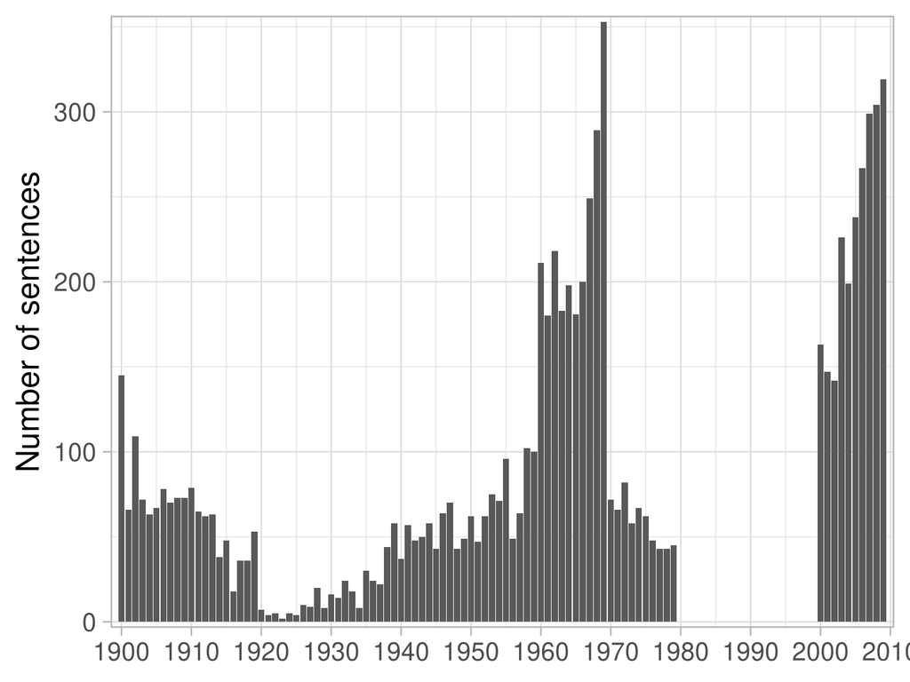

### Closest sentence from ‘rational’ and ‘rationality’ of the backbone community

| Sentence | Title | Year | Journal | Authors | Words Similarity |
| --- | --- | --- | --- | --- | --- |
| Basing ourselves on two alternative interpretations of the requirement of rationality in social choice, we identify in this paper the respective sets of necessary and sufficient conditions on the patt… | Necessary and sufficient conditions for rational choice under majority decision | 1969 | Journal of Economic Theory | Sen A. | 0.716 |
| To the extent that politicians are rational, voters cannot be so; to the extent that voters are rational they cannot have the equal effective demand that democratic theory asserts; if all men are rati… | [Market Concepts in Political Theory](https://http://www.jstor.org/stable/139435) | 1961 | The Canadian Journal of Economics and Political Science / Revue canadienne d’Economique et de Science politique | C. B. Macpherson | 0.708 |
| This aspect of bounded rationality is often neglected in a policy setting. | [An experimental study of compliance and leverage in auditing and regulatory enforcement](https://doi.org/10.1093/ei/cbj019) | 2006 | Economic Inquiry | Cason T.N. | 0.704 |
| Policy analysts therefore rely on technical rationality, with its foundations in instrumental rationality, as the essential arbiter of these claims for attention (Meppem and Bourke, 1999). | The discursive community: Evolving institutional structures for planning sustainability | 2000 | Ecological Economics | Meppem T. | 0.696 |
| Thus the elimination of C might have-and legitimately so from the point of view of individual rationality as well as social welfare-an effect upon the outcome.7 C. Another Collective Decision, with Vo… | [The Possibility of a Social Welfare Function](https://http://www.jstor.org/stable/1815299) | 1966 | The American Economic Review | James S. Coleman | 0.696 |
| In both cases, however, the argument presupposed the possibility of the achievement, by rulers and by ruled, of a level of intelligence or rationality at which conduct would be determined, not by the … | [Economics and the Idea of Natural Laws](https://http://www.jstor.org/stable/1885439) | 1929 | The Quarterly Journal of Economics | O. H. Taylor | 0.694 |
| Such a schematic approach is preferred over a messy and more naturalistic representation of the policy domain, because the assumption is that the ‘rationality’ of a process can be determined in relati… | [The production and use of knowledge in regulatory impact assessment - An empirical analysis](https://doi.org/10.1016/j.forpol.2009.01.004) | 2009 | Forest Policy and Economics | Hertin J. | 0.693 |
| This paper provides an answer to this question in the sense that it states conditions under which the optimal policy is to provide a signal that solves the bounded rationality problem. | Investors’s distrust and the marketing of new financial assets | 2004 | Quarterly Review of Economics and Finance | Kawamura E. | 0.692 |
| Buchanan and Tullock (1962, especially p. 32) argue that there is no reason to expect social choice to be rational or to suggest that it is desirable, and in an appendix to this book, Tullock states t… | [Graph-Theoretic Approaches to the Theory of Social Choice](https://http://www.jstor.org/stable/30022566) | 1968 | Public Choice | Michael Taylor | 0.692 |
| It is natural for the policy maker in exercising this control to aspire to rational decisions. | [Some Reflections on Rational Policy for Economic Development in Underdeveloped Areas](https://http://www.jstor.org/stable/1151649) | 1954 | Economic Development and Cultural Change | Ponna Wignaraja | 0.692 |
| There has to be a decision-making and an executing function on both levels and in a more rational association than at present. | [THE COMPREHENSIVE REFORM OF MANAGING THE NATIONAL ECONOMY IN HUNGARY](https://http://www.jstor.org/stable/40694541) | 1966 | Acta Oeconomica | R. Nyers | 0.690 |
| If the various constituent elements out of which such pseudo-principles are made up be separated from each other, if the general proposition be carefully distinguished from all kinds of working hypoth… | [What has Philosophy to Contribute to the Social Sciences, and to Economics in Particular?](https://http://www.jstor.org/stable/2549250) | 1936 | Economica | Harro Bernadelli | 0.685 |
| The use of an appropriate theory governing policy making procedures thus forms a crucial condition of rational policy. | [The Ambiguous Rationality of Economic Policy](https://http://www.jstor.org/stable/1991399) | 1972 | Journal of Money, Credit and Banking | Karl Brunner | 0.685 |
| In such instances again genuine decisions based on the emergence of new expectations are one but not the only possibility. | [Psychological Analysis of Business Decisions and Expectations](https://http://www.jstor.org/stable/1802255) | 1946 | The American Economic Review | George Katona | 0.680 |
| There are thus some contradictions, in the implementation of policies which are by themselves rational and defensible. | [Employment and Unemployment in the Indian Economy: Problems of Classification, Measurement, and Policy](https://http://www.jstor.org/stable/1151636) | 1959 | Economic Development and Cultural Change | K. N. Raj | 0.680 |
| We also verify the rationality of our initial assumptions that sequentially deciding policymakers can take as given the current policy choice of the other policymaker, as well as all future policies a… | [Monetary conservatism and fiscal policy](https://doi.org/10.1016/j.jmoneco.2008.09.003) | 2008 | Journal of Monetary Economics | Adam K. | 0.679 |
| We summarise them in relation to five ‘illusions of rational policy analysis’. | [The production and use of knowledge in regulatory impact assessment - An empirical analysis](https://doi.org/10.1016/j.forpol.2009.01.004) | 2009 | Forest Policy and Economics | Hertin J. | 0.678 |
| The rational model of policy-making assumes that decision-makers base their actions on knowledge (Simon, 1957; Dror, 1989). | Information-Communications Technologies (ICT) and transport: Does knowledge underpin policy? | 2002 | Telecommunications Policy | Cohen G. | 0.678 |
| The above discussion should be sufficient to show that when individuals are released from restrictive conditions upon behavior and information (i.e., voting on only one issue and complete absence of i… | [The Possibility of a Social Welfare Function](https://http://www.jstor.org/stable/1815299) | 1966 | The American Economic Review | James S. Coleman | 0.676 |
| Given the process of policy evaluation and decision-making as outlined above, it would be too restraining to award a policy the grade “rational” only if it reached the highest score possible under pre… | [Synoptic versus Incremental Scholarly Advice in Economic Policy: Some Implications of So-Called “Rational” Tax Systems](https://http://www.jstor.org/stable/40910769) | 1970 | FinanzArchiv / Public Finance Analysis | Gunther Engelhardt | 0.676 |

### Closest sentences of the backbone community’s centroid

| Sentence | Title | Year | Journal | Authors | Similarity to Backbone Centroid |
| --- | --- | --- | --- | --- | --- |
| This interpretation led historically to the interesting question whether governmental policy rules are optimal or even effective (Sargent & Wallace, 1976). | [Is integration I(d) applicable to observed economics and finance time series?](https://doi.org/10.1016/j.irfa.2009.03.004) | 2009 | International Review of Financial Analysis | McCauley J.L. | 0.787 |
| This kind of reasoning also leads to the already mentioned “consistency problem” of Kydland and Prescott [1977] and their plea for rules instead of discretionary policy. | [On the Influence of Uncertainty on the Solution of an Optimal Economic Policy](https://http://www.jstor.org/stable/40750420) | 1978 | Zeitschrift für die gesamte Staatswissenschaft / Journal of Institutional and Theoretical Economics | Reinhard Neck | 0.782 |
| It is hoped that this paper will help clarify these issues, even for those who do not share its policy conclusions. | International capital flows: Identifying the gender dimension | 2000 | World Development | Singh A. | 0.778 |
| The analysis yields some interesting policy implications. | [Quality, trade, and growth](https://doi.org/10.1016/j.jebo.2003.09.011) | 2004 | Journal of Economic Behavior and Organization | Fan C. | 0.774 |
| For this reason, it is useful to study possible policy implications of the results in these sections. | An analytic approach to the study of gun control policies | 2001 | Socio Economic Planning Sciences | Correa H. | 0.773 |
| Within this framework we ask whether policy decisions are complementary. | [Complementarities in innovation policy](https://doi.org/10.1016/j.euroecorev.2003.12.003) | 2005 | European Economic Review | Mohnen P. | 0.773 |
| The following policy implications are obtained. | [An economic analysis of apathetic behavior: Theory and experiment](https://doi.org/10.1016/j.socec.2006.12.026) | 2008 | Journal of Socio Economics | Shibata A. | 0.773 |
| A potential policy option may be technically sound and economically virtuous, yet may not be selected (for whatever reason) because policy makers cannot agree that it should be chosen. | Integrating science and policy development: Case of the national research council and US national policy focused on non-federal forests | 2000 | Forest Policy and Economics | Ellefson P.V. | 0.772 |
| Various policies presented to a government by enthusiastic theoreticians are, more or less successfully, tried and after some time, often abandoned in order to make room for those put forward by other… | East European economic reform: Some simulations on a structural VAR model | 2001 | Journal of Policy Modeling | Blangiewicz M. | 0.771 |
| The results lend credibility to using this theoretical setup to explore policy issues. | Competition between private and public schools: Testing stratification and pricing predictions | 2004 | Journal of Public Economics | Epple D. | 0.771 |
| The result is interesting in terms of policy implication. | [Causal relationship between energy consumption and GDP growth revisited: A dynamic panel data approach](https://doi.org/10.1016/j.ecolecon.2007.11.006) | 2008 | Ecological Economics | Huang B.N. | 0.771 |
| The above analysis also has an interesting policy implication. | [Quality, trade, and growth](https://doi.org/10.1016/j.jebo.2003.09.011) | 2004 | Journal of Economic Behavior and Organization | Fan C. | 0.771 |
| The point we stress here is that, in deriving optimal policies we do not compare choices made in autarchy with unconstrained efficient choices, but choices of those who intend to deviate from truthful… | [The risk properties of human capital and the design of government policies](https://doi.org/10.1016/j.euroecorev.2006.02.004) | 2007 | European Economic Review | da Costa C. | 0.770 |
| Issues are often decided not “on their merits,” but with an eye to the decision’s effect on changes in the likelihood of some highly feared or highly desired event. | [Models of Reformmongering](https://http://www.jstor.org/stable/1884401) | 1963 | The Quarterly Journal of Economics | Albert O. Hirschman | 0.770 |
| The paper concludes in Section 5 with a few remarks on the need for an integration of the argument presented here with other relevant arguments in policy applications. | [A utilitarian approach to the provision and pricing of excludable public goods](https://doi.org/10.1016/j.jpubeco.2004.12.006) | 2005 | Journal of Public Economics | Hellwig M. | 0.769 |

### Closest sentences of each HDBSCAN cluster’s centroid composing the backbone community

| Sentence | Title | Year | Journal | Authors | Similarity to HDSBSCAN Centroid |
| --- | --- | --- | --- | --- | --- |
| Proof of this, in the ordinary sense of demonstration or deduction from axioms, on such a subject is not to be expected.2 It might be suggested in favor of A2 that it is less subjective, less ” sickli… | [The Subjective Element in the First Principles of Taxation](https://http://www.jstor.org/stable/1885206) | 1910 | The Quarterly Journal of Economics | F. Y. Edgeworth | 0.648 |
| The extra height of the final successive utility over the marginal utility of income is caused by the fact that ex hypothesi the former, regarded as a sacrifice, cannot be reduced by modifying the exp… | [The Utility of Income and Progressive Taxation](https://http://www.jstor.org/stable/2222207) | 1913 | The Economic Journal | S. J. Chapman | 0.613 |
| It leads logically only to the clear-income theory, or to the exemption of a certain minimum with proportional taxation thereafter.5 Meyer endeavors to avoid these objections by declaring that the sac… | [Progressive Taxation in Theory and Practice](https://www.jstor.org/stable/10.2307/3000009) | 1908 | American Economic Association Quarterly | E. R. A. Seligman | 0.585 |
| The propositions respecting incipient taxes can best be dis cussed by mathematical methods, but first of all an attempt will be made to show, by general reasoning, that they are not opposed to common … | [The Theory of Incipient Taxes](https://http://www.jstor.org/stable/2221475) | 1906 | The Economic Journal | C. F. Bickerdike | 0.572 |
| A closer approach to some of the implications of the Levy may be made by an examination of a curious conflict in the arguments by which it is supported. | [Some Aspects of the Proposed Capital Levy](https://http://www.jstor.org/stable/2222792) | 1918 | The Economic Journal | W. R. Scott | 0.567 |
| It is sufficient to have shown that, if a special levy on material capital alone is considered too unfair to be admissible, means exist by which the unfairness can be iemoved. | [A Special Levy to Discharge War Debt](https://http://www.jstor.org/stable/2221865) | 1918 | The Economic Journal | A. C. Pigou | 0.566 |
| An investigation of the different possible applications of the principle which might be made to the advantage of the state might show the subjects of the tax to be monopolistic in character, and there… | [The Place of the Service Tax in Modern Finance](https://http://www.jstor.org/stable/1817476) | 1900 | Journal of Political Economy | J. H. Hamilton | 0.565 |
| Without dwelling upon the extreme cases (which constitute a reductio ad absurdurn of some forms of the Levy) it is clear that the initial rate would be so high that it must tend to check effort in the… | [Some Aspects of the Proposed Capital Levy](https://http://www.jstor.org/stable/2222792) | 1918 | The Economic Journal | W. R. Scott | 0.565 |
| But this assumption implies not merely the improbable or the incredible with regard to future tax collections, but also both the incredible and the impossible with regard to the necessary current sacr… | [The War-Tax Paradox](https://http://www.jstor.org/stable/1803593) | 1919 | The American Economic Review | H. J. Davenport | 0.564 |
| But if that is the case one could expect that it would be recognised also in the theory of taxation, quite independenitly of the conisequences to which it might lead. | [The Theory of Progressive Taxation](https://http://www.jstor.org/stable/2957408) | 1901 | The Economic Journal | G. Cassel | 0.564 |

| Sentence | Title | Year | Journal | Authors | Similarity to HDSBSCAN Centroid |
| --- | --- | --- | --- | --- | --- |
| If, however, I am wrong in believing that the purpose and possible result of local option is what I have represented it, and if the outcome of the experiment would be the establishment of diverse loca… | [The Separation of State and Local Revenues](https://http://www.jstor.org/stable/1885205) | 1910 | The Quarterly Journal of Economics | Charles J. Bullock | 0.583 |
| Plainly, the consideration of the subjective use of each other’s provisions. | [Marginal Utility and Exchange Value](https://http://www.jstor.org/stable/1819501) | 1905 | Journal of Political Economy | R. S. Padan | 0.579 |
| This variable quality is not appreciated, however, if the common law attains its goal of estab? | [The Economic Function of the Common Law](https://http://www.jstor.org/stable/1820903) | 1918 | Journal of Political Economy | Homer Hoyt | 0.573 |
| balancing of conflicting principles. | [The Present Position of the Doctrine of Free Trade](https://www.jstor.org/stable/10.2307/2999922) | 1905 | Publications of the American Economic Association | Frank W. Taussig | 0.568 |
| Most thinkers are now willing to concede that however accurate may be the conceptioll of inviolable law and however legitimate may be the inclusion of econoznic principle in this category, the law hol… | [Economics and Social Progress](https://www.jstor.org/stable/10.2307/2485840) | 1903 | Publications of the American Economic Association | Edwin R. A. Seligman | 0.563 |
| The existing variety at least offers an opportunity for free experimentation, and if the assumption be justified that the goodness of the good law (as well as the badness of the bad law) may be demons… | [Medical Benefits Under Workmen’s Compensation: I](https://http://www.jstor.org/stable/1819877) | 1917 | Journal of Political Economy | I. M. Rubinow | 0.559 |
| -To exchange this single criterion for the loftier but vaguer and more numerous objects which constitute the public welfare is to embark upon a sea of troubles; it becomes necessary to balance against… | [The Reports of the Coal Industry Commission](https://http://www.jstor.org/stable/2223401) | 1919 | The Economic Journal | H. D. H. | 0.558 |
| Betterments and Public Necessity One point raised in the foregoing discussion seems to deserve separate treatment. | [Some Neglected Phases of Rate Regulation](https://http://www.jstor.org/stable/1814945) | 1914 | The American Economic Review | J. Maurice Clark | 0.556 |
| held, also, on a number of occasions that the law is its own measure of right and wrong and that the fact that a combination is justified by other criteria of reasonableness than those recognized by t… | [The Legality of the Combination of Competitors Under the Sherman Act](https://http://www.jstor.org/stable/1820986) | 1917 | Journal of Political Economy | Sumner H. Slichter | 0.555 |
| If they do not choose to enter under these circumstances, it is contended that it is unreasonable to hold the combination responsible for the lack of substantial com? | [The Legality of the Combination of Competitors Under the Sherman Act](https://http://www.jstor.org/stable/1820986) | 1917 | Journal of Political Economy | Sumner H. Slichter | 0.552 |

| Sentence | Title | Year | Journal | Authors | Similarity to HDSBSCAN Centroid |
| --- | --- | --- | --- | --- | --- |
| Says he: “The ultimate deterrninant of value where there are noncompeting groups is marginal utility, not cost in the sense of labor or effort. | [Economic Investigation as a Basis for Tariff Legislation](https://http://www.jstor.org/stable/475) | 1912 | The American Economic Review | H. Parker Willis | 0.611 |
| He says, for example, that ” foras- much as almost all Commodities have their Substitutes or Succedanea, and that almost all uses may be answered several wayes; and for that novelty, surprise, example… | [Petty’s Place in the History of Economic Theory](https://http://www.jstor.org/stable/1882563) | 1900 | The Quarterly Journal of Economics | Charles H. Hull | 0.603 |
| Yet he would doubtless have added then, as he did a few years later, that, if we undertake to ascertain what are “the essential qualities of a standard,” and to study ” the causes of the variation in … | [The Development of Ricardo’s Theory of Value](https://http://www.jstor.org/stable/1882412) | 1904 | The Quarterly Journal of Economics | Jacob H. Hollander | 0.601 |
| His interest thus lay not with positive, but with relative value, and consequently less with the cause than with the measure of exchange value. | [The Development of Ricardo’s Theory of Value](https://http://www.jstor.org/stable/1882412) | 1904 | The Quarterly Journal of Economics | Jacob H. Hollander | 0.584 |
| For this assumes that the rewards of labor merely equal subsistence or that the laborer is characteristically improvident and that he draws at once upon the stock of completed goods to the full amount… | [Present Work and Present Wages](https://http://www.jstor.org/stable/1885209) | 1910 | The Quarterly Journal of Economics | J. G. Thompson, F. W. Taussig | 0.577 |
| But, in any case, for average or aggregate purposes, a certain degree of significance must be attached to the iron law of wages in any possible society, if only the quasi-biological assumption of an i… | [Wage Theory and Theories](https://http://www.jstor.org/stable/1884735) | 1919 | The Quarterly Journal of Economics | H. J. Davenport | 0.576 |
| With these assumptions out of the way he is able to concern himself with the production of “surplus value” by his theory of the working day and the cost of living. | [American Shoemakers, 1648-1895: A Sketch of Industrial Evolution](https://http://www.jstor.org/stable/1886057) | 1909 | The Quarterly Journal of Economics | John R. Commons | 0.570 |
| It is found that wants can be satisfied with less labor in the aggregate if part of the labor is applied to preparatory operations, and the whole is spread over a considerable time, than would be nece… | [The Nature of Interest and the Causes of Its Fluctuations](https://http://www.jstor.org/stable/1884035) | 1917 | The Quarterly Journal of Economics | A. F. McGoun | 0.563 |
| The laborer’s reward is primarily a money wage and one of the functions of money being that of a “store of value,” the laborer is not compelled to turn his money wage at once and to the full extent, i… | [Present Work and Present Wages](https://http://www.jstor.org/stable/1885209) | 1910 | The Quarterly Journal of Economics | J. G. Thompson, F. W. Taussig | 0.548 |
| When we speak, therefore, of a class of commodities as produced under circumstances of equal competition, or as the result of labor and abstinence, unassisted by any other appropriated agent, and cons… | [Capital as a Competitive Concept](https://http://www.jstor.org/stable/1817716) | 1904 | Journal of Political Economy | H. J. Davenport | 0.540 |

| Sentence | Title | Year | Journal | Authors | Similarity to HDSBSCAN Centroid |
| --- | --- | --- | --- | --- | --- |
| No other factor suggests so strong an argument against the practicability of making rates upon the experience of a particular state, whatever may be the additional weakness of the plan on purely theor… | [Fire Insurance Rates and State Regulation](https://http://www.jstor.org/stable/1884983) | 1914 | The Quarterly Journal of Economics | W. F. Gephart | 0.613 |
| This principle is so familiar as applied to the classifying of freight by railways that it needs no elabora-ation here, except to say that concessions need to be subject to much the same limitations o… | [Rates for Public Utilities](https://http://www.jstor.org/stable/1828093) | 1911 | The American Economic Review | J. Maurice Clark | 0.607 |
| The proper conclusion would seem to be that in attempting to determine whether the entire schedule of rates of a railroad is excessive, the physical valuation of the road is a relevant and important b… | [Valuation of Public Service Corporations](https://www.jstor.org/stable/10.2307/3000031) | 1910 | American Economic Association Quarterly | W. H. Williams | 0.581 |
| The fact that the commissions have developed a course of action on the subject of allowances for pavements, the reverse of what might naturally be expected as the logical interpretation of the decisio… | [The Development by Commissions of the Principles of Public Utility Valuation](https://http://www.jstor.org/stable/1883623) | 1914 | The Quarterly Journal of Economics | Ralph E. Heilman | 0.565 |
| In substance it was stated that the determination of what constituted a reasonable rate depended upon the facts of the particular case, and that the ” power to pass upon the reasonableness of existing… | [Federal Regulation of Railways in the United States](https://http://www.jstor.org/stable/2957335) | 1900 | The Economic Journal | Simon J. McLean | 0.564 |
| It is true that such conservative action postpones the day when, if ever, the ideal basis of rates can be established, but it accomplishes something instead of nothing. | [Railroad Rate Control in Its Legal Aspects: A Study of the Effect of Judicial Decisions Upon Public Regulation of Railroad Rates](https://www.jstor.org/stable/10.2307/2999949) | 1906 | Publications of the American Economic Association | Harrison Standish Smalley | 0.560 |
| This distinction is ingenious, and in making it the Court has perhaps saved from annihilation the state’s right of rate control, but whatever merit may be claimed for it on that account, it may be adm… | [Railroad Rate Control in Its Legal Aspects: A Study of the Effect of Judicial Decisions Upon Public Regulation of Railroad Rates](https://www.jstor.org/stable/10.2307/2999949) | 1906 | Publications of the American Economic Association | Harrison Standish Smalley | 0.557 |
| It is difficult to think of a calamity so great as that which is certain to follow a valuation based upon the theory that the federal Constitution does not protect the full present value of railroad p… | [“Valuation of Railway Property for Purposes of Rate Regulation”](https://http://www.jstor.org/stable/1819530) | 1915 | Journal of Political Economy | Pierce Butler | 0.556 |
| For if the road’s profits were small, it might be held that the rate or schedule was reasonable; whereas the fact might be that the particular rate or schedule in question was excessive and that the s… | [Shall Railway Profits be Limited?](https://http://www.jstor.org/stable/1821037) | 1910 | Journal of Political Economy | Samuel O. Dunn | 0.555 |
| 1 The theory would seem to be that the testimony of even the most eminent expert witness hardly makes that show of scientific procedure which is created by arrays of cost figures, however incomparable… | [Railroad Valuation by the Interstate Commerce Commission](https://http://www.jstor.org/stable/1884488) | 1919 | The Quarterly Journal of Economics | Homer B. Vanderblue | 0.554 |

| Sentence | Title | Year | Journal | Authors | Similarity to HDSBSCAN Centroid |
| --- | --- | --- | --- | --- | --- |
| It is in this general reasoning that the ordinary free-trader shows his common sense; it is here that the triumphs of a Bastiat are won. | [Disputed Points in the Theory of International Trade](https://http://www.jstor.org/stable/2957423) | 1901 | The Economic Journal | F. Y. Edgeworth | 0.560 |
| If the board had assumed for the purpose of making a set of rates that a given political tariff theory were desirable, it would have been face to face with the question of efficiency. | [The Tariff Board and Wool Legislation](https://http://www.jstor.org/stable/1828259) | 1913 | The American Economic Review | William S. Culbertson | 0.540 |
| The first difficulty with this practical reasoning is that it presupposes that the whole undertaking is simply what is currently called a “mnanufacturer’s proposition,” and that the purpose of the tar… | [Economic Investigation as a Basis for Tariff Legislation](https://http://www.jstor.org/stable/475) | 1912 | The American Economic Review | H. Parker Willis | 0.520 |
| It is for reasons like these that the familiar assertion of fiscal controversy that the purchase of an import implies the sale of an export, visible or invisible, does not bring the complete consolati… | [Economic Theory and Fiscal Policy](https://http://www.jstor.org/stable/2221360) | 1904 | The Economic Journal | L. L. Price | 0.517 |
| Perhaps no experience, however prolonged, would be adequate; as in the argument for Free Trade, we must depend largely upon general reasoning.2 The suggested analogy with Protection will perhaps be ac… | [Recent Schemes for Rating Urban Land Values](https://http://www.jstor.org/stable/2221141) | 1906 | The Economic Journal | F. Y. Edgeworth | 0.512 |
| e., free trade with foreign countries-means the acceptance of the similar easy and simple argument in favour of dogmatic protection. | [The Economics of Imperialism](https://http://www.jstor.org/stable/2220913) | 1910 | The Economic Journal | J. Shield Nicholson | 0.511 |
| The dual aim of rendering the tariff more simple and effective for its purpose of raising revenue, arnd of purging it of Protectionist suspicion, may indeed have been present to their minds; but they … | [Economic Theory and Fiscal Policy](https://http://www.jstor.org/stable/2221360) | 1904 | The Economic Journal | L. L. Price | 0.508 |
| One who argues after this fashion would seem not to be able to use the principle of a ” competitive tariff,” which assumes a partition of the market between the domestic producer and the foreign; or a… | [The Tariff Act of 1913](https://http://www.jstor.org/stable/1884927) | 1913 | The Quarterly Journal of Economics | F. W. Taussig | 0.506 |
| Why a tariff based upon foreign costs should be regarded as essentially fair and just to all concerned is difficult to comprehend, unless a condition of commercial isolation and of complete embargo up… | [Cost of Production as a Basis of Tariff Revision](https://http://www.jstor.org/stable/1820498) | 1909 | Journal of Political Economy | John Cummings | 0.502 |
| No dispassionate observer can question that the tariff issue was the main problem presented to the electorate, not only in the congres? | [The Tariff of 1913: I](https://http://www.jstor.org/stable/1821090) | 1914 | Journal of Political Economy | H. Parker Willis | 0.502 |

| Sentence | Title | Year | Journal | Authors | Similarity to HDSBSCAN Centroid |
| --- | --- | --- | --- | --- | --- |
| So the institution of ownership is taken into the inquiry not as a factor of growth or an element subject to change, but as one of the primordial and immutable facts of the order of nature, underlying… | [The Limitations of Marginal Utility](https://http://www.jstor.org/stable/1822146) | 1909 | Journal of Political Economy | Thorstein Veblen | 0.524 |
| The doctrine of purchase for value without notice, of constructive trusts, of unjust enrichment, the ethical and moral tenets of equity, the recognized limitations on contractual capacity, the nature,… | [The Relation of Law and Economics](https://http://www.jstor.org/stable/1823141) | 1917 | Journal of Political Economy | Eugene Allen Gilmore | 0.505 |
| sidered that national interests require such action, without over much regard to the losses which may be inflicted on certain owners of property, is that the national gain is believed to be greater th… | [The Principle of Land Value Taxation](https://http://www.jstor.org/stable/2221622) | 1912 | The Economic Journal | C. F. Bickerdike | 0.503 |
| 2 By this I understand all property which, in contrast with productive property, plays no active part in the carrying on of a business, so that its surrender entails no diminution of profits. | [The Readjustment of German Finance by Means of a Capital Levy-II](https://http://www.jstor.org/stable/2223417) | 1919 | The Economic Journal | NA | 0.499 |
| Moreover, there is little reason to suppose that assessment difficulties in respect to the most tangible of property will be removed by relieving | [Home Rule in Taxation](https://http://www.jstor.org/stable/1884985) | 1914 | The Quarterly Journal of Economics | Horace Secrist | 0.498 |
| Unlike concrete wealth, which carries with it the responsibility of administration, abstract property is susceptible either of indefinite and equal subdivision, or of any degree of concentration. | [The Growth of Large Fortunes](https://www.jstor.org/stable/10.2307/2999952) | 1907 | Publications of the American Economic Association | George P. Watkins | 0.493 |
| Nor can one psychological consideration be safely overlooked, namely, that the longer such a condition prevails the more the owners of such property become convinced not only that they are right, and … | [Economics and the Law: Annual Address of the President](https://http://www.jstor.org/stable/1810777) | 1915 | The American Economic Review | John H. Gray | 0.492 |
| He remarks that all reasonable persons are aware that great property adds less to the cheerfulness of life in the best sense, than does a mind educated and moulded so as to be capable of making a wise… | [A Bibliographical Discovery in Political Economy](https://http://www.jstor.org/stable/1819679) | 1901 | Journal of Political Economy | Leopold Katscher | 0.492 |
| If then, we admit for the sake of argument that the content of property will change, and ought to change from time to time, as the needs of society change, and that no person and no class of persons o… | [Economics and the Law: Annual Address of the President](https://http://www.jstor.org/stable/1810777) | 1915 | The American Economic Review | John H. Gray | 0.490 |
| The assurance that property rights in great investments of fixed capital will be kept inviolate is essential before men will make the mental resolve to transfer their goods from the monetary form, tha… | [The Economic Function of the Common Law](https://http://www.jstor.org/stable/1820903) | 1918 | Journal of Political Economy | Homer Hoyt | 0.487 |

| Sentence | Title | Year | Journal | Authors | Similarity to HDSBSCAN Centroid |
| --- | --- | --- | --- | --- | --- |
| In both cases, however, the argument presupposed the possibility of the achievement, by rulers and by ruled, of a level of intelligence or rationality at which conduct would be determined, not by the … | [Economics and the Idea of Natural Laws](https://http://www.jstor.org/stable/1885439) | 1929 | The Quarterly Journal of Economics | O. H. Taylor | 0.565 |
| It would require a certainty of language which excludes the possibility of doubt to justify the opinion that the government of any commercial nation had annulled its natural right to meet these specia… | [The Most-Favored-Nation Clause in American Commercial Treaties](https://http://www.jstor.org/stable/1822463) | 1924 | Journal of Political Economy | Jacob Viner | 0.505 |
| With the preceding discussion as a background, it is now possible to make an analysis of the principles underlying the Kansas cases. | [The Supreme Court and Compulsory Arbitration: An Analysis Based on the Kansas Cases](https://http://www.jstor.org/stable/1806138) | 1928 | The American Economic Review | Edward Berman | 0.504 |
| To overcome the handicap of having only a scant fraction of conveyances showing true consideration in deeds, repeated attempts have been made to enact a law requiring this information to be shown, in … | [Railway Terminal Air Rights Developments and the Movement of Local Land Values](https://http://www.jstor.org/stable/3138807) | 1929 | The Journal of Land & Public Utility Economics | William D. Pence | 0.495 |
| It is a fundamental assumption of the reasoning indicated in the supposititious quotation set down above that individuals, when they seek to satisfy their respective interests within the limitations o… | [The Theoretical Bases of Economic Policy](https://http://www.jstor.org/stable/1822346) | 1929 | Journal of Political Economy | Corrado Gini | 0.485 |
| I i6 HNATHAN ISAACS discover some of these theories, and we may leave them discussing their views with very edifying results so far as facility in the handling of legal principles is concerned. | [The Teaching of Law in Collegiate Schools of Business](https://http://www.jstor.org/stable/1822572) | 1920 | Journal of Political Economy | Nathan Isaacs | 0.478 |
| duced his subject thus: The amounts involved and the momentous consequence in public bur? | [Value for Rate Making and Recapture of Excess Income](https://http://www.jstor.org/stable/1820808) | 1928 | Journal of Political Economy | George G. Tunell | 0.477 |
| When a group of facts comes before an English Court for adjudication, the whole course of the discussion between the judge and the advocate assumes that no question is, or can be, raised which will ca… | [Sir Henry Maine](https://http://www.jstor.org/stable/2548385) | 1928 | Economica | K. B. Smellie | 0.468 |
| We may well imagine a law teacher holding out the case before his class by suggesting, after himself making a very careful study, that there are eleven or thirteen or seventeen different theories by w… | [The Teaching of Law in Collegiate Schools of Business](https://http://www.jstor.org/stable/1822572) | 1920 | Journal of Political Economy | Nathan Isaacs | 0.466 |
| the doctrine that every one is chargeable with the natural consequence of his conduct is expressed in the meaningless form that everyone is presumed to intend those consequences ;5 the rule that ignor… | [Sir Henry Maine](https://http://www.jstor.org/stable/2548385) | 1928 | Economica | K. B. Smellie | 0.466 |

#### Closes sentences 3_13_1900-1919: tariff, free_trade, duties, protection, tariffs (1930-1939)

Sentence

Title

Year

Journal

Authors

Similarity to HDSBSCAN Centroid

If the various constituent elements out of which such pseudo-principles are made up be separated from each other, if the general proposition be carefully distinguished from all kinds of working hypotheses concerning the facts, then the limitations of the generality of the law will disappear, and the general principle will be reached ” on which each individual, deliberately, blindly, or impulsively, adapts his conduct to the terms on which alternatives are offered to him by nature or by man,” and it will 1 Of wide scope is here the assumption that an individual chooses his objectives in a ” rational way ” as a ” normal business man ” does.

[What has Philosophy to Contribute to the Social Sciences, and to Economics in Particular?](https://http://www.jstor.org/stable/2549250)

1936

Economica

Harro Bernadelli

0.669

This position assumes that force and fraud are ruled out of individual competition by improved morality rather than by the strengthening of authority, and is in so far like that of Locke, and again Marshall.4 At this stage it is hardly possible to speak of radical anti-intellectualism in spite of the difference of opinion on the scope of reason.

[Economics and Sociology: Marshall in Relation to the Thought of His Time](https://http://www.jstor.org/stable/1883233)

1932

The Quarterly Journal of Economics

Talcott Parsons

0.647

Then follow some justifiable strictures on the undue preference shown in the past by the courts “to contemplate the probable intent of the parties rather than to analyse the consequences of behavior,” on the “Unreason wasted upon the ‘rule of reason,’” on “a fantastic verbalism” of the courts and their “naive notion of competition” (along with other suggestions less justified); and then comes the verdict: “Judicial bodies are not especially qualified for the function of selecting desirable ends or analyzing the means of attaining them” (pp.

[Planning For Totalitarian Monopoly](https://http://www.jstor.org/stable/1824057)

1937

Journal of Political Economy

Frank Albert Fetter

0.604

It is not merely a question of the conflicting individual interests of different individuals.

[Ethics and Economic Reform. I. The Ethics of Liberalism](https://http://www.jstor.org/stable/2549075)

1939

Economica

F. H. Knight

0.587

Both points illustrate our contention that many important phenomena in the international or world field are not to be explained by referring to the bargaining of individuals in a laissez faire regime.

[An Approach to World Economics](https://http://www.jstor.org/stable/1802981)

1931

The American Economic Review

Ernest Minor Patterson

0.583

As recognized by Professor Commons in his sentence, “Then the working rule is not a foreordained harmony of interests, as assumed in the hypotheses of natural rights or mechanical equilibrium of the classical and hedonic schools .

[Institutional Economics of Professor Commons](https://http://www.jstor.org/stable/1805294)

1932

The American Economic Review

Joseph E. Shafer

0.581

1. It substitutes a mystical line of approach, calculated to bewilder the layman and the politician, for a common-sense one, and cramps governments in evolving their policies.

[Dr. Neisser on Secondary Employment: A Note](https://http://www.jstor.org/stable/1927840)

1936

The Review of Economics and Statistics

R. F. Kahn

0.581

1. It substitutes a mystical line of approach, calculated to bewilder the layman and the politician, for a common-sense one, and cramps governments in evolving their policies.

[Dr. Neisser on Secondary Employment: A Rejoinder](https://http://www.jstor.org/stable/1927841)

1936

The Review of Economics and Statistics

H. Neisser

0.581

Practical considerations may have dictated the necessity for compromise with ideals in granting past approvals, but it is unrealistic to hold that, had control been by initiation rather than by veto, the same sort of practical considerations would not have dictated the necessity for compromis

[Railroad Fixed Charges in Bankruptcy Proceedings](https://http://www.jstor.org/stable/1829692)

1939

Journal of Political Economy

William H. Moore

0.577

A different and, one is disposed to believe, a more accurate and impartial interpretation (one at any rate more in accord with past law) might have retarded, if it could not have prevented, the victory of individualism.

[Coke and the Rise of Economic Liberalism](https://http://www.jstor.org/stable/2590029)

1935

The Economic History Review

Donald O. Wagner

0.575

| Sentence | Title | Year | Journal | Authors | Similarity to HDSBSCAN Centroid |
| --- | --- | --- | --- | --- | --- |
| It is clear that the general precept of equality in political affairs does not necessarily dictate equality of sacrifice of utility in taxat | [Recent and Contemporary Theories of Progressive Taxation](https://http://www.jstor.org/stable/1824777) | 1938 | Journal of Political Economy | Elmer D. Fagan | 0.658 |
| But from the fact that the minimum sacrifice theory gives a prominent role to the indirect and long-run sacrifice as well as to direct and immediate sacrifice in taxation, it follows that the practica… | [Recent and Contemporary Theories of Progressive Taxation](https://http://www.jstor.org/stable/1824777) | 1938 | Journal of Political Economy | Elmer D. Fagan | 0.653 |
| The fact that it is impossible to compare the satisfactions of different people appears to have been the reason why the proponents of the sacrifice theories have adopted the assumption of identical ma… | [Recent and Contemporary Theories of Progressive Taxation](https://http://www.jstor.org/stable/1824777) | 1938 | Journal of Political Economy | Elmer D. Fagan | 0.638 |
| For the early steps in a purely theoretical discussion of sacrifice in taxation, this hypothesis is highly valuable if not indispensable. | [Recent and Contemporary Theories of Progressive Taxation](https://http://www.jstor.org/stable/1824777) | 1938 | Journal of Political Economy | Elmer D. Fagan | 0.635 |
| This doctrine has been accepted by numerous economists in various forms and on various grounds; other economists have ignored it or openly rejected it; while the framers of our tax laws have considere… | [Taxation and the Minimum of Subsistence](https://http://www.jstor.org/stable/253) | 1933 | The American Economic Review | Alfred G. Buehler | 0.631 |
| The points made respecting application of the principle of declining marginal utility to money, and the existence of sacrifice in progressive taxation hold for this view also. | [The Ability-to-Pay Theory of Taxation](https://http://www.jstor.org/stable/1806989) | 1939 | The American Economic Review | M. Slade Kendrick | 0.628 |
| Until there is established a reasonable basis for a belief not only in the reality of the hypothesis that the curve of diminishing marginal utility of money income is steeper than a rectangular hyperb… | [Recent and Contemporary Theories of Progressive Taxation](https://http://www.jstor.org/stable/1824777) | 1938 | Journal of Political Economy | Elmer D. Fagan | 0.625 |
| But despite the wide adoption of the assumption of “common benefit only” in taxation, general observation compels the recognition of the fact that our assumption does not square completely with actual… | [Recent and Contemporary Theories of Progressive Taxation](https://http://www.jstor.org/stable/1824777) | 1938 | Journal of Political Economy | Elmer D. Fagan | 0.615 |
| To hold that the law about taxes ought to affect different people’s satisfactions equally, while allowing that the rest of the legal system may properly affect them very unequally, seems not a little … | [Recent and Contemporary Theories of Progressive Taxation](https://http://www.jstor.org/stable/1824777) | 1938 | Journal of Political Economy | Elmer D. Fagan | 0.610 |
| The degree of soundness to be kept up in a system of public finances being the basic principle of fiscal policy, it must be established by a political decision. | [Fiscal Policy in the Business Cycle](https://http://www.jstor.org/stable/1806966) | 1939 | The American Economic Review | Gunnar Myrdal | 0.609 |

| Sentence | Title | Year | Journal | Authors | Similarity to HDSBSCAN Centroid |
| --- | --- | --- | --- | --- | --- |
| The special case in which the postulate of the primacy of multitudinous conflicting group interests is valid is limited to societies where antagonism between classes is not too strong to permit compro… | [The Political Theory of Social Credit](https://http://www.jstor.org/stable/138098) | 1949 | The Canadian Journal of Economics and Political Science / Revue canadienne d’Economique et de Science politique | C. B. Macpherson | 0.546 |
| This recognition of the principle of different powers for different circumstances is most important; it means that further change is mainly a matter of the facts. | [Municipal Government in Ontario](https://http://www.jstor.org/stable/137085) | 1942 | The Canadian Journal of Economics and Political Science / Revue canadienne d’Economique et de Science politique | C. A. Curtis | 0.530 |
| If this outline of conditions leading to political decision-making seems to de-emphasize this type of “legislation” unrealistically in favor of its opposite, the writer will plead as a defense the fac… | [The Problem of Evaluating Regulatory Policy](https://http://www.jstor.org/stable/1052211) | 1945 | Southern Economic Journal | Howard R. Smith | 0.524 |
| Conceding that there is no more democratic institution than a market, he says: “But this maximum is only a short-run one and, moreover, is relative to the actual desires of the comrades as they are fe… | [Schumpeter on Capitalism, Socialism, and Democracy](https://http://www.jstor.org/stable/1826906) | 1945 | Journal of Political Economy | Charles O. Hardy | 0.515 |
| It is at least conceivable that these often probably incomprehensible uncertainties in the policies of “the government” may have constituted a greater danger to morale and a greater incentive toward f… | [Unemployment in the United States, 1930-40](https://http://www.jstor.org/stable/1816433) | 1941 | The American Economic Review | Paul Webbink | 0.505 |
| If this principle is followed, because of the discretion of the institutions, the requirements of the government supervisors, or both, there will be no | [The Flow of Savings–I](https://http://www.jstor.org/stable/2975485) | 1948 | The Journal of Finance | Homer Jones | 0.498 |
| ’7 This passage is of special interest because it is among the first attempts to analyze a specific problem in public affairs with the tools of pure theory. | [Mathematical Economics before Cournot](https://http://www.jstor.org/stable/1826556) | 1949 | Journal of Political Economy | Ross M. Robertson | 0.492 |
| He holds that the survival of democratic institutions depends upon “the possibility of effecting, by the pragmatic democratic method, a sufficient equalization of possessions and of opportunity to pro… | [The Growth of an Indigenous Social Philosophy in America](https://http://www.jstor.org/stable/3483788) | 1944 | The American Journal of Economics and Sociology | Grover Cleveland Loud | 0.488 |
| On the other hand, an impressive case can be made for the view that all human society is federal in its nature, that people are always torn between the common interests which unite them and the partic… | [The Federal Dilemma](https://http://www.jstor.org/stable/137114) | 1941 | The Canadian Journal of Economics and Political Science / Revue canadienne d’Economique et de Science politique | J. A. Corry | 0.484 |
| It should be noted in this connection that this political construction is not to be applied uniformly to all parts of the whole structure, but that variation should be permitted to exist according to … | [THE THEORY OF WIDER TERRITORY ECONOMY](https://www.jstor.org/stable/10.2307/43216890) | 1941 | Kyoto University Economic Review | Kichihiko Taniguchi | 0.479 |

#### Closes sentences 3_15_1900-1919: tlle, alld, tllat, bills, legislation (1940-1949)

| Sentence | Title | Year | Journal | Authors | Similarity to HDSBSCAN Centroid |
| --- | --- | --- | --- | --- | --- |
| Policy may be based on one of two possible hypotheses. | [A Model of the Forty-Month or Trade Cycle](https://http://www.jstor.org/stable/1825433) | 1942 | Journal of Political Economy | Joshua C. Hubbard | 0.612 |
| The wisdom of this policy depends on numerous factors. | [The Official and Unofficial Markets for Sterling](https://http://www.jstor.org/stable/1884725) | 1940 | The Quarterly Journal of Economics | S. E. Harris | 0.566 |
| Other policies may be such that they influence the behavior of individuals or groups in a manner that can be determined by a priori considerations. | [Quantitative Research in Agricultural Economics: The Interdependence between Agriculture and the National Economy](https://http://www.jstor.org/stable/1232628) | 1947 | Journal of Farm Economics | Trygve Haavelmo | 0.563 |
| In line with the trend in social values, however, we are probably on safe grounds if we accept the hypothesis that any policy which tends to increase the dispersion in a relative or absolute sense is … | [Contribution of Price Policy to the Income and Resource Problems in Agriculture](https://http://www.jstor.org/stable/1232112) | 1944 | Journal of Farm Economics | D. Gale Johnson | 0.555 |
| III Our approach to matters of policy will depend on our choice between the “can” and the “will” hypotheses. | [The Problem of Capital Accumulation](https://http://www.jstor.org/stable/1811691) | 1948 | The American Economic Review | Evsey D. Domar | 0.553 |
| How much difference of opinion is compatible with the maintenance of common policy depends on many varying factors. | [The Concerted Regulation of Price and Output](https://http://www.jstor.org/stable/2225936) | 1948 | The Economic Journal | E. G. Dowdell | 0.545 |
| Such responsibility and investigation may conceivably diminish the tendency to implement policies which confer benefits which are obvious because concentrated, but which impose larger though more diff… | [On Some Appendices to the Rowell-Sirois Report](https://http://www.jstor.org/stable/137164) | 1941 | The Canadian Journal of Economics and Political Science / Revue canadienne d’Economique et de Science politique | J. B. Brebner, V. C. Fowke, Paul Studenski, F. C. Cronkite, G. A. Elliott | 0.535 |
| On the propriety of this criterion of policy there should be general agreement. | [Tariff Policy and Employment in Depression](https://http://www.jstor.org/stable/137057) | 1940 | The Canadian Journal of Economics and Political Science / Revue canadienne d’Economique et de Science politique | V. W. Bladen | 0.533 |
| V Sometimes right policies are followed for the wrong reasons. | [The Effect of Interest Rate Increases on the Banking System](https://http://www.jstor.org/stable/1810106) | 1945 | The American Economic Review | Paul A. Samuelson | 0.533 |
| It cannot help but be discouraging to a research analyst to refine his materials to the nth degree only to find that actual policy is determined in large part (perhaps even the largest part) upon the … | [The Rôle of Science in the Formulation of Economic Policy](https://http://www.jstor.org/stable/1053291) | 1946 | Southern Economic Journal | Howard R. Smith | 0.532 |

| Sentence | Title | Year | Journal | Authors | Similarity to HDSBSCAN Centroid |
| --- | --- | --- | --- | --- | --- |
| In such instances again genuine decisions based on the emergence of new expectations are one but not the only possibility. | [Psychological Analysis of Business Decisions and Expectations](https://http://www.jstor.org/stable/1802255) | 1946 | The American Economic Review | George Katona | 0.664 |
| the possible results of alternative courses of action under real or assumed conditions. | [A Reappraisal of Farm Tenure Research](https://http://www.jstor.org/stable/3159285) | 1948 | Land Economics | Max M. Tharp | 0.662 |
| A more intelligent or realistic choice makes its object more valuable. | [An Ethics for Today](https://http://www.jstor.org/stable/3483698) | 1943 | The American Journal of Economics and Sociology | Everett W. Hall | 0.657 |
| Again, not only are decisions arrived at, and indeed conditioned by an environment of social, political, and economic factors (including contemporary thought), but one decision in some measure conditi… | [An Approach to the Study of Entrepreneurship: A Tribute to Edwin F. Gay](https://http://www.jstor.org/stable/2113071) | 1946 | The Journal of Economic History | Arthur H. Cole | 0.645 |
| Such assumptions recognize the supreme importance of the individual decision upon the actual outcome of a particular theoretical situation. | [Imperfect Competition in Agricultural Processing and Distributing Industries](https://http://www.jstor.org/stable/137496) | 1944 | The Canadian Journal of Economics and Political Science / Revue canadienne d’Economique et de Science politique | William H. Nicholls | 0.636 |
| When a man takes a decision on any matter whatever, he tacitly or unconsciously takes into account a great range of circumstances which are all relevant, in the sense that if any one of them were mate… | [Interest-Rates and the Pace of Investment](https://http://www.jstor.org/stable/2225616) | 1946 | The Economic Journal | G. L. S. Shackle | 0.627 |
| In such cases, it is necessary to ascertain the real objective of the decisions (e.g. | [The Scope and Method of Economics](https://http://www.jstor.org/stable/2296113) | 1945 | The Review of Economic Studies | O. Lange | 0.626 |
| It is erroneous to assume that consciousness of such alternatives and therefore choice is necessarily given before every human action, and that in consequence all acting involves deliberation and pref… | [The Problem of Rationality in the Social World](https://http://www.jstor.org/stable/2549460) | 1943 | Economica | Alfred Schuetz | 0.617 |
| However, an incidental, and contrary, view of decision-making is also stated (ibid., pp. | [The Entrepreneur: The Firm](https://http://www.jstor.org/stable/1829414) | 1944 | Journal of Political Economy | James H. Stauss | 0.611 |
| The very fact that a selection is made in passing judgment, logically implies a choice of suitableness, importance, worth- 26 G. A. Lundberg, “Foundations of Sociology,” p. 101. | [The Place of Value-Judgments in the Social Sciences](https://http://www.jstor.org/stable/3483397) | 1945 | The American Journal of Economics and Sociology | Melvin J. Williams | 0.605 |

| Sentence | Title | Year | Journal | Authors | Similarity to HDSBSCAN Centroid |
| --- | --- | --- | --- | --- | --- |
| If, as an isolated event, a moderate tax is placed upon, say, cosmetics, it is difficult for me to see that the relations of that event to total equilibrium, to saving and investment, or to consumptio… | [Ad Valorem and Specific Taxes: Rejoinder](https://http://www.jstor.org/stable/1884729) | 1940 | The Quarterly Journal of Economics | Donald W. Gilbert | 0.609 |
| Surely it is reasonable to presume, rather, that men purchase their property or make their other commitments knowing that tax policies and taxed objects have changed, do change and are likely again to… | [The Alleged Injustice of Increasing Land Value Taxation without Compensation](https://http://www.jstor.org/stable/3483495) | 1946 | The American Journal of Economics and Sociology | Harry Gunnison Brown | 0.593 |
| There are probably those who will hesitate to accept the author’s basic premise that taxation should perform a dual function. | [Temporary National Economic Committee: Reviews of Monographs](https://http://www.jstor.org/stable/1805819) | 1941 | The American Economic Review | NA | 0.580 |
| ’That is to say, aside from the limitations to which government spending policies are subject owing to the desirability of avoiding significant price increases or owing to adverse psychological reperc… | [Monetary Policy and the Elasticity of Liquidity Functions](https://http://www.jstor.org/stable/1927625) | 1948 | The Review of Economics and Statistics | William Fellner | 0.574 |
| 1 If individuals behaved with the degree of rationality assumed in economic theory, they would charge some proportion of the income tax payable at the present time to capital account, and not to incom… | [The Income Burden of Capital Taxes](https://http://www.jstor.org/stable/2967666) | 1942 | The Review of Economic Studies | Nicholas Kaldor | 0.573 |
| This may not be the case if we assume (i) that the government, in either case, is determined to get, and will get, a certain absolute amount of goods and services that it needs,’ and (2) that the econ… | [Choice of Tax Measures to Avert Inflation](https://http://www.jstor.org/stable/1927511) | 1941 | The Review of Economics and Statistics | Carl Shoup | 0.572 |
| An income tax is to some extent objectionable because it affects the choice between effort and leisure and the choice between immediate and postponed consumption. | [The Marginal Cost Controversy](https://http://www.jstor.org/stable/2549764) | 1946 | Economica | R. H. Coase | 0.564 |
| Such a person, if he is realistic and willing to consider possible results of his reasoning, must recognize that if Mr. Welch disagrees and fails to make his investment, because he considers taxes too… | [Venture Capital and Taxation](https://http://www.jstor.org/stable/1884123) | 1941 | The Quarterly Journal of Economics | Charles C. Abbott, Eugene M. Zuckert | 0.562 |
| With an omniscient understanding of the various economic effects of taxes any one person may arrive at a pattern of effects which he considers the most desirable to achieve. | [Economic Research and Tax Policy](https://http://www.jstor.org/stable/1910465) | 1944 | The American Economic Review | Roy Blough | 0.555 |
| In arriving at this proposition, we shall reconsider certain elements of the theory of war inflation. | [Postscript on War Inflation: A Lesson from World War II](https://http://www.jstor.org/stable/1802859) | 1947 | The American Economic Review | William J. Fellner | 0.552 |

#### Closes sentences 3_13_1900-1919: tariff, free_trade, duties, protection, tariffs (1950-1959)

| Sentence | Title | Year | Journal | Authors | Similarity to HDSBSCAN Centroid |
| --- | --- | --- | --- | --- | --- |
| There are at present two limitations of the theory: (1) One can imagine other theories, directed to the same end, that would take into account, in each individual decision, the presumptions (of the in… | [Commentary on the Three Notes of Emile Borel](https://http://www.jstor.org/stable/1906949) | 1953 | Econometrica | Maurice Fréchet | 0.710 |
| Some decisions, as between given pairs of alternatives, may be assumed to be imposed. | [A Difficulty in the Concept of Social Welfare](https://http://www.jstor.org/stable/1828886) | 1950 | Journal of Political Economy | Kenneth J. Arrow | 0.695 |
| It goes beyond the problem of making meaningful and correct statements and tries to furnish criteria for choosing a course of action. | [Are Business History and Economic Theory Compatible?](https://www.jstor.org/stable/10.2307/3111860) | 1955 | The Business History Review | Donald E. Stout | 0.684 |
| We assume that people can make better decisions when they take a realistic view of their total situation, 4. | [Farm and Home Planning-Incentive For Better Family Living and Better Farming](https://www.jstor.org/stable/10.2307/44013426) | 1955 | Proceedings of the Annual Meeting (Western Farm Economics Association) | Mrs. Lila B. Dickerson | 0.667 |
| This is despite any change in the individual’s orderings on other alternatives.2 One’s view of this requirement will turn partly on whether he desires to allow different individuals an unequal influen… | [On the Concept of Social Welfare](https://http://www.jstor.org/stable/1884448) | 1954 | The Quarterly Journal of Economics | Abram Bergson | 0.664 |
| For this purpose, theories of “optimal” decision-making may not be close enough; we need theories of actual decision-making. | [A Final Comment](https://http://www.jstor.org/stable/1927413) | 1958 | The Review of Economics and Statistics | Daniel Ellsberg | 0.662 |
| Otherwise the effects of decisions may be contrary to those intended. | [An Empirical Test of Sales-Tax Regressivity](https://http://www.jstor.org/stable/1826700) | 1959 | Journal of Political Economy | David G. Davies | 0.661 |
| In some areas of decision the isolation and definition of the limiting factors has for so long been considered impracticable that it has almost come to be considered undesirable. | [Operational Research A New Tool for Management](https://http://www.jstor.org/stable/2097565) | 1953 | The Journal of Industrial Economics | I. S. Lloyd | 0.660 |
| In order to define properly the realizable alternatives for comparison, it is necessary to consider them as of the moment of initial decision or choice. | [External and Internal Public Debt](https://http://www.jstor.org/stable/1810048) | 1957 | The American Economic Review | James M. Buchanan | 0.659 |
| It is not to be expected that influences of this character would ordinarily be perceived by a decision-maker, even though such factors may sometimes be more important than influences which operate at … | [Some Sociological Aspects of Occupational Choice](https://http://www.jstor.org/stable/3484558) | 1959 | The American Journal of Economics and Sociology | W. L. Slocum | 0.658 |

| Sentence | Title | Year | Journal | Authors | Similarity to HDSBSCAN Centroid |
| --- | --- | --- | --- | --- | --- |
| The ultimate test, under this approach, is whether an arrangement involves presence or absence of prejudice to the public interest,” after all the economic facts are known.’ | [The per Se Doctrine and the New Rule of Reason](https://http://www.jstor.org/stable/1054007) | 1955 | Southern Economic Journal | Jesse W. Markham | 0.559 |
| The decisive thing must be the system of wants and preferences with regard to politically dependent variables, and not the question of whether the motivation is materialistic interest, ethics or any i… | [Recent Developments in Economics](https://http://www.jstor.org/stable/1884444) | 1954 | The Quarterly Journal of Economics | F. Zeuthen | 0.550 |
| The reasons for political and social considerations are also evident from the results wvhich would be attained in each instance. | [Some Observations on Experience Rating in Unemployment Insurance](https://www.jstor.org/stable/10.2307/250335) | 1959 | The Journal of Insurance | John F. Adams | 0.540 |
| When it comes to efficient thinking about political problems and we consequently transgress the limits of pure science - the choice of simplifications must be tested partly by the harmony between inte… | [Recent Developments in Economics](https://http://www.jstor.org/stable/1884444) | 1954 | The Quarterly Journal of Economics | F. Zeuthen | 0.538 |
| constantly presented.19 The choice he makes is bound to be influenced to some degree by the impact of his social and economic philosophy on the particular facts under consideration. | [The Supreme Court and the Decline of State Power](https://http://www.jstor.org/stable/724937) | 1959 | The Journal of Law & Economics | Roger C. Cramton | 0.534 |
| Moreover, in many, if not most, cases the efficacy of any particular economic measure in achieving the indicated end or goal will depend to a very considerable extent on political factors. | [Public Policy and Political Considerations](https://http://www.jstor.org/stable/1927016) | 1957 | The Review of Economics and Statistics | Betty G. Fishman, Leo Fishman | 0.526 |
| Where different agencies of government counter one another with opposing policies without bargaining, an agency’s formulation of a policy inconsistent with some other agency’s policy may be the only p… | [Tinbergen on Policy-Making](https://http://www.jstor.org/stable/1826993) | 1958 | Journal of Political Economy | Charles E. Lindblom | 0.525 |
| Decisions are essentially political ? | [Alternate Solutions: Voluntary and Compulsory Medical Care Insurance](https://www.jstor.org/stable/10.2307/250040) | 1951 | Journal of the American Association of University Teachers of Insurance | C. A. Kulp | 0.522 |
| While an analysis limited to the dynamics of State action is not adequate to predict in which direction State action will proceed, it may be noted that the existence of adversary organized interests a… | [Government and Labor-Management Relations](https://http://www.jstor.org/stable/3483436) | 1950 | The American Journal of Economics and Sociology | Murray Edelman | 0.516 |
| In any event let me conclude with one last observation: In the final analysis the overall importance of the present methodological skirmish is probably subordinate to the overall objective implied in … | [Value Judgments in Economics: A Rejoinder](https://http://www.jstor.org/stable/1054223) | 1957 | Southern Economic Journal | Campbell R. McConnell | 0.515 |

| Sentence | Title | Year | Journal | Authors | Similarity to HDSBSCAN Centroid |
| --- | --- | --- | --- | --- | --- |
| Thus we can say that each policy will have in the person’s mind a range of imaginable capital values, and to each of these we can think of him as attaching its own degree of potential surprise. | [Expectation, Income and Profit](https://www.jstor.org/stable/10.2307/3438644) | 1955 | Ekonomisk Tidskrift | G. L. S. Shackle | 0.592 |
| In principle, there exist two ways in which a sufficient basis for policy may be obtained. | [Collusion and its Limits under Oligopoly](https://http://www.jstor.org/stable/1818023) | 1950 | The American Economic Review | William Fellner | 0.590 |
| This does not mean that we cannot say in any concrete case what the consequences of any given policy will be and under what value assumptions it would be desirable. | [Welfare and Freer Trade–A Reply](https://http://www.jstor.org/stable/2226611) | 1951 | The Economic Journal | T. Balogh | 0.583 |
| “43 This does not mean that a specific theory necessarily implies specific policies, for a good general theory will permit many alternative policies to be intelligently discussed, including the policy… | [The Pragmatic Basis of Economic Theory](https://http://www.jstor.org/stable/137857) | 1950 | The Canadian Journal of Economics and Political Science / Revue canadienne d’Economique et de Science politique | H. Scott Gordon | 0.576 |
| About this, Farrell argues first, that policy rules cannot be expected to hold with logical certainty,’ and second, that such rules should not be tested against a theoretical criterion but against the… | [The Theory of Public Utility Price: A Further Note](https://http://www.jstor.org/stable/2661790) | 1959 | Oxford Economic Papers | J. Wiseman | 0.573 |
| Otherwise, we arrive at the impasse of a certain course of action being “economically desirable” but “legally impossible.” | [Integration of Law and Economics in Analyzing Agricultural Land Use Problems](https://http://www.jstor.org/stable/1234007) | 1955 | Journal of Farm Economics | John F. Timmons | 0.568 |
| Rather it should be used as a framework for anticipating changes under the given set of assumptions2 (which, of course, rarely if ever duplicate reality), and for studying and weighing the effects of … | [Location Theory and Trade Theory: Short-Run Analysis](https://http://www.jstor.org/stable/1884452) | 1954 | The Quarterly Journal of Economics | Walter Isard | 0.567 |
| Once it is granted that basic values or goals must be employed as criteria for selecting lines of policy, he would presumably agree that the predicted workability or probability of success of a policy… | [Economic Theory, Value Judgments, and Economic Policy](https://http://www.jstor.org/stable/3485033) | 1955 | The American Journal of Economics and Sociology | Forest G. Hill | 0.559 |
| This illustrates the second misconception-that policy rules should be tested against the purely theoretical criterion of whether they give optimal results, and rejected if they do not. | [In Defence of Public-Utility Price Theory](https://http://www.jstor.org/stable/2661878) | 1958 | Oxford Economic Papers | M. J. Farrell | 0.554 |
| If these criteria can be found and agreed upon, a rational exploration of and choice among alternative policies can take place. | [Economic Theory, Value Judgments, and Economic Policy](https://http://www.jstor.org/stable/3485033) | 1955 | The American Journal of Economics and Sociology | Forest G. Hill | 0.554 |

| Sentence | Title | Year | Journal | Authors | Similarity to HDSBSCAN Centroid |
| --- | --- | --- | --- | --- | --- |
| The above discussion should be sufficient to show that when individuals are released from restrictive conditions upon behavior and information (i.e., voting on only one issue and complete absence of i… | [The Possibility of a Social Welfare Function](https://http://www.jstor.org/stable/1815299) | 1966 | The American Economic Review | James S. Coleman | 0.660 |
| It may also reflect a planner’s view that ” diminishing marginal utility ” is present in some cardinal sense, and its effect on the intensity of preferences in voting should be allowed for. | [The Evaluation of Development Programmes](https://http://www.jstor.org/stable/2296569) | 1967 | The Review of Economic Studies | D. McFadden | 0.653 |
| The solution to this question which is adopted implicitly in the present formulation is to suppose that the citizens in using the market to acquire votes take the prices as fixed data without determin… | [An Axiomatic Model of Logrolling](https://http://www.jstor.org/stable/1808962) | 1969 | The American Economic Review | Robert Wilson | 0.647 |
| Then individual X, to whom the first decision is of such importance, could offer to Z enough to express this importance.- He could, for example, offer Z his vote on decisions 2 and 3, an offer which w… | [The Possibility of a Social Welfare Function](https://http://www.jstor.org/stable/1815299) | 1966 | The American Economic Review | James S. Coleman | 0.643 |
| It seems probable that the individual in his voting behaviour, will tend to choose among alternatives on the basis of a somewhat broader and more inclusive value scale than that which will direct his … | [Politics, Policy, and the Pigovian Margins](https://http://www.jstor.org/stable/2601517) | 1962 | Economica | James M. Buchanan | 0.635 |
| Using the previous model of a three faction society, but leaving out the possibility of a communist takeover, let the individual anticipate the probability that he could produce a stalemate if he join… | [The Rationale of Revolt](https://www.jstor.org/stable/10.2307/30022059) | 1967 | Papers on Non-Market Decision Making | Thomas Ireland | 0.628 |
| Yet an economic man will be willing to spend various other resources, such as votes on other issues, etc., in proportion to his expected utility gain from their expenditure. | [The Possibility of a Social Welfare Function](https://http://www.jstor.org/stable/1815299) | 1966 | The American Economic Review | James S. Coleman | 0.624 |
| Whenever expected benefit levels exceed collective decisionmaking costs for at least some rule, a potential political surplus can be said to exist. | [Some Postulated Effects of Learning on Constitutional Behavior](https://http://www.jstor.org/stable/30022582) | 1968 | Public Choice | Elinor Ostrom | 0.623 |
| Then he might consider an exchange of votes with Z such that A and C’ would win.8 His utility under this possible action could 7 An incidental point may be made here concerning the apparent reasonable… | [The Possibility of a Social Welfare Function](https://http://www.jstor.org/stable/1815299) | 1966 | The American Economic Review | James S. Coleman | 0.621 |
| Basing ourselves on two alternative interpretations of the requirement of rationality in social choice, we identify in this paper the respective sets of necessary and sufficient conditions on the patt… | Necessary and sufficient conditions for rational choice under majority decision | 1969 | Journal of Economic Theory | Sen A. | 0.619 |

#### Closes sentences 3_13_1900-1919: tariff, free_trade, duties, protection, tariffs (1960-1969)

| Sentence | Title | Year | Journal | Authors | Similarity to HDSBSCAN Centroid |
| --- | --- | --- | --- | --- | --- |
| 7 Even where there is no particular problem of incomplete or inaccurate information, in the narrow sense, the individual may nevertheless make choices which an external observer may regard as “irratio… | [Merit Goods Revisited](https://http://www.jstor.org/stable/40910613) | 1969 | FinanzArchiv / Public Finance Analysis | John G. Head | 0.723 |
| There has to be a decision-making and an executing function on both levels and in a more rational association than at present. | [THE COMPREHENSIVE REFORM OF MANAGING THE NATIONAL ECONOMY IN HUNGARY](https://http://www.jstor.org/stable/40694541) | 1966 | Acta Oeconomica | R. Nyers | 0.713 |
| Rather, we shall argue that there is a “natural unit” for decision-making and that this unit is responsive to market forces. | [Externalities, Welfare, and the Theory of Games](https://http://www.jstor.org/stable/1828857) | 1962 | Journal of Political Economy | Otto A. Davis, Andrew Whinston | 0.708 |
| It must provide in some form for the possibility to account for circumstances which do not, or hardly, depend on our own decisions, since these circumstances constitute the most important external lim… | [ON A POSSIBLE MATHEMATICAL MODEL OF LONG-TERM (15-20 YEAR) NATIONAL ECONOMIC PLANNING](https://http://www.jstor.org/stable/40727877) | 1969 | Acta Oeconomica | P. Bod | 0.708 |
| vii-viii), and since nothing would get done if some action were not taken in “original” situations, the presence of this regression is sidestepped above but acknowledged in this footnote with the comm… | [The Roles of Policy Makers and Scientists in Planning Useful Research](https://www.jstor.org/stable/10.2307/40472238) | 1962 | Nebraska Journal of Economics and Business | Richard F. Barton | 0.708 |
| itate a more rational choice by the decision maker in that the consequences of each action are more completely specified. | [An Application of Statistical Decision Theory to Commercial Turkey Production](https://http://www.jstor.org/stable/1236942) | 1967 | Journal of Farm Economics | Vernon R. Eidman, Gerald W. Dean, Harold O. Carter | 0.690 |
| It has been remarked before that, since a model of this type is seeking to explain people’s decision-making behaviour, it is important to recognise that perceptions, on which decisions are based, may … | [Choice of Travel Mode for the Journey to Work: Some Findings](https://http://www.jstor.org/stable/20052067) | 1967 | Journal of Transport Economics and Policy | D. A. Quarmby | 0.686 |
| Decisions of this kind have been the academic domain of psychologists, economists, mathematicians, and others as well. | [A Behavioral Approach to the Investment-Management Decision and to the Securities Markets](https://http://www.jstor.org/stable/2326142) | 1969 | The Journal of Finance | Randolph Westerfield | 0.686 |
| 1 Here and henceforth I abstract from the cases where the ‘wrong’ choice takes the form of (a) the adoption of a neutral attitude as between A and B when B should be chosen, or (b) the choice of A whe… | [Ideal and Reality in the Choice between Alternative Techniques](https://http://www.jstor.org/stable/2662573) | 1964 | Oxford Economic Papers | Ronald L. Meek | 0.685 |
| Be it noted here that even market behaviour, which is supposed to give precise scientific measurements of intra-personal preferences, does so only on the assumptions of rationality and consistency, wh… | [Themes in Dynamic Theory](https://http://www.jstor.org/stable/2228576) | 1963 | The Economic Journal | R. F. Harrod | 0.684 |

| Sentence | Title | Year | Journal | Authors | Similarity to HDSBSCAN Centroid |
| --- | --- | --- | --- | --- | --- |
| In analyzing future possibilities, alternative values for the policy variables, representing different directions of policy, will be assumed. | [Development Policies for Southern Italy](https://http://www.jstor.org/stable/1879545) | 1962 | The Quarterly Journal of Economics | Hollis B. Chenery | 0.628 |
| Issues are often decided not “on their merits,” but with an eye to the decision’s effect on changes in the likelihood of some highly feared or highly desired event. | [Models of Reformmongering](https://http://www.jstor.org/stable/1884401) | 1963 | The Quarterly Journal of Economics | Albert O. Hirschman | 0.625 |
| The importance of the problem arises from the fact that the choice of future policy is influenced by the policymaker’s estimate of the effect of his current policy. | [Monetary-Policy Targets and Indicators](https://http://www.jstor.org/stable/1832148) | 1967 | Journal of Political Economy | Thomas R. Saving | 0.611 |
| This, of course, does not imply that economic considerations will necessarily be dominant when the final decision is made. | [DISCUSSION: FORESTRY AND RECREATION](https://www.jstor.org/stable/10.2307/44013317) | 1962 | Proceedings of the Annual Meeting (Western Farm Economics Association) | Emery N. Castle | 0.608 |
| when some policy measure is determined by other considerations than those of (1) above. | [On the Theory of “Second Best”](https://http://www.jstor.org/stable/2296678) | 1967 | The Review of Economic Studies | P. Bohm | 0.598 |
| The choice of a definition 1 While I do not believe that the distinction between desirability and effectiveness has been emphasized sufficiently in the past, it is implicit in Theil’s (1964) applicati… | [On the Desirability of Discretionary Policy](https://http://www.jstor.org/stable/1829087) | 1967 | Journal of Political Economy | Rudolph G. Penner | 0.595 |
| A number of theorists have produced results which raise very serious doubts about the reliability and utility of practical judgment in a number of important areas of public policy. | [Informed Judgment, Rigorous Theory and Public Policy](https://http://www.jstor.org/stable/1055141) | 1965 | Southern Economic Journal | William J. Baumol | 0.584 |
| under alternative assumptions as to internal policies. | [Foreign Assistance and Economic Development: Reply](https://http://www.jstor.org/stable/1815546) | 1968 | The American Economic Review | Hollis B. Chenery, Alan M. Strout | 0.584 |
| What is more important, however, is that given the high probability of accepting false hypotheses, inferences about public policy, such as the authorities’ ability to influence the market, should be t… | [Interest Rates, the Meiselman Model and Random Numbers](https://http://www.jstor.org/stable/1829545) | 1967 | Journal of Political Economy | A. Buse | 0.583 |
| Since the desired ends of different decision-makers and different economic decision units do not always coincide on an issue, conceivably the result must either be a complete victory for one or some f… | [On the Concept of Function Transfer](https://http://www.jstor.org/stable/3439020) | 1966 | The Swedish Journal of Economics | Jan Valdelin, Kjell Öström | 0.583 |

Sentence

Title

Year

Journal

Authors

Similarity to HDSBSCAN Centroid

Summarising this comparison, we see that it is favourable to, or at least not unfavourable to, planning without prices on all issues except the quantity of information to be handled by the C.P.B.

[Planning Without Prices](https://http://www.jstor.org/stable/2296432)

1969

The Review of Economic Studies

G. M. Heal

0.638

If it were a mistake rigidly to enforce the plan in case of deviations between the plan and the market, nor would it be satisfactory completely to rely on the market.

[IDEAS ON THE IMPROVEMENT OF NATIONAL ECONOMIC PLANNING](https://http://www.jstor.org/stable/40727749)

1967

Acta Oeconomica

I. Friss

0.612

Let us further assume that this is not a trivial plan but rather a plan which calls for a shift in the decisions which these independent decision makers would have made had the plan not been made public.

[Towards a Sociology of National Development Planning](https://www.jstor.org/stable/10.2307/4189532)

1968

The Journal of Developing Areas

Guy Benveniste

0.608

Taken into account will be the interdependence among successive current plans, the possibility of variation over time of the standard effectiveness, and, always, the fact that a decision with regard to one aspect of the economy has effects on the optimality of many other decisions.

[Kantorovich on Economic Calculation](https://http://www.jstor.org/stable/1829943)

1960

Journal of Political Economy

Benjamin Ward

0.606

It may be possible, therefore, to analyze the relation of plans to expectations and the relation of plans to actual behavior and to compare actual behavior with that considered to be optimal.

[The Analysis of Changes in Agricultural Supply: Problems and Approaches](https://http://www.jstor.org/stable/1235403)

1960

Journal of Farm Economics

Marc Nerlove, Kenneth L. Bachman

0.600

We are not thinking here of the cases - not infrequent in the past - where competent bodies accepted and enacted a plan whose internal contradictions had been known; what we have in mind is the theoretical problem of ensuring the fullest possible consistency of the plan.

[ECONOMIC RESEARCH IN THE SERVICE OF NATIONAL ECONOMIC PLANNING](https://http://www.jstor.org/stable/40727834)

1968

Acta Oeconomica

I. Friss

0.600

1. Under these conditions, it may be said that every plan is an ensemble of equations based on a certain choice of hypotheses, which may prove to be provisional or incorrect, i.e., in the event that political factors alter the planner’s choice, or simply when predictions of the future prove to be unfounded.

[The “Plan as Conception” and the “Administrative Plan”](https://http://www.jstor.org/stable/4379334)

1966

Eastern European Economics

Czeslaw Bobrowski

0.598

There is a point in favor of extending, as far as conceivable, the extent of preliminary political issues and choices: if not, there will be the risk of planners overcoming the indefiniteness in the computation through additional “assumptions” which will express their own subjective, generally moralizing convictions.

[French Planning: Retrospect and Prospect](https://http://www.jstor.org/stable/1927918)

1963

The Review of Economics and Statistics

S. Wickham

0.594

Sometimes alternatives are given which make it possible to select a “less desirable” plan if exogenous factors such as “politicians” or “vested landowning interests” or “labor unions” or just nonmeasurable values are important to the decision.

[Assessment of Regional Planning Experiences at Differing Governmental Levels](https://http://www.jstor.org/stable/1237014)

1967

Journal of Farm Economics

Raymond J. Penn, Harold C. Jordahl, Jr.

0.585

If, on the other hand, the planners could set relative prices so as to yield decentralized decisions in accordance with the plan, then there would be no need for central commands.

[The Enterprise Under Central Planning](https://http://www.jstor.org/stable/2296837)

1969

The Review of Economic Studies

R. D. Portes

0.584

| Sentence | Title | Year | Journal | Authors | Similarity to HDSBSCAN Centroid |
| --- | --- | --- | --- | --- | --- |
| After adding some rough assumptions about the probable form of the behavior functions, he comes to the conclusion that Fohl’s view about the effects of a profit tax may not be so mistaken after all. | [The Old and the New–Some Recent Trends in the Literature of German Economics](https://http://www.jstor.org/stable/1809373) | 1964 | The American Economic Review | K. W. Rothschild | 0.654 |
| The same line of analysis applies mutatis mutandis, for example, to such problems as the income tax law: we do not tax most types of “imputed income” for what in the end are reasons of procedural dece… | [Rationing Justice](https://http://www.jstor.org/stable/724783) | 1965 | The Journal of Law & Economics | Geoffrey C. Hazard, Jr. | 0.635 |
| It is possible to accept his proposition about fiscal politics as conceptually satisfactory, and yet to feel that the weight to be attached to his argument must be influenced (for example) by the degr… | [The Public Economy](https://http://www.jstor.org/stable/2601678) | 1960 | Economica | Jack Wiseman | 0.623 |
| A careful application of the reasoning underlying (1) and (2) will reveal circumstances in which the above conclusions do not hold and the allocation of the burden may -be independent of the form of f… | [Long-Run Implications of Alternative Fiscal Policies and the Burden of the National Debt](https://http://www.jstor.org/stable/2228247) | 1961 | The Economic Journal | Franco Modigliani | 0.613 |
| The official who said that the limit to this expenditure was set by the money available was leaving out a number of steps in the argument; but he was not being as stupid in relation to practical decis… | [The Economics of Under-Developed Countries](https://http://www.jstor.org/stable/2228400) | 1963 | The Economic Journal | W. B. Reddaway | 0.608 |
| A finding which supports the third assumption or its equivalent, that there is no significant correlation between income size and marginal valuation, would not, indeed, destroy the case for any kind o… | [Marginal Utility, Interpersonal Comparisons and the Theory of Taxation](https://http://www.jstor.org/stable/3484330) | 1963 | The American Journal of Economics and Sociology | David Carney | 0.605 |
| Since the determination of the just initial distribution of property is beyond the competence of the fiscal theorist, his “purely fiscal” theory of the second requirement must remain entirely “hypothe… | [Lindahl’s Theory of the Budget](https://http://www.jstor.org/stable/40909788) | 1963 | FinanzArchiv / Public Finance Analysis | J. G. Head | 0.604 |
| This objection appears to be levelled at the purely fiscal principle, but, as we shall see, it is also intimately related to LindahVs interpretation of the socio-political principle. | [Lindahl’s Theory of the Budget](https://http://www.jstor.org/stable/40909788) | 1963 | FinanzArchiv / Public Finance Analysis | J. G. Head | 0.603 |
| It was suggested that such a tax will shift the possibilities schedule leftward by the amount of the tax, and the effect on risk taking depends on the particular shape of the indifference curves we ch… | [Cardinal Utility, Portfolio Selection and Taxation](https://http://www.jstor.org/stable/2296077) | 1960 | The Review of Economic Studies | Marcel K. Richter | 0.600 |
| But if the model is at all realistic, the above reasoning may perhaps be interpreted as a case for earmarkinig separate taxes for covering different types of expenditure-a system which is usually not … | [Some Notes on the Lindahl Theory of Determination of Public Expenditures](https://http://www.jstor.org/stable/2525312) | 1963 | International Economic Review | Leif Johansen | 0.592 |

#### Closes sentences 3_13_1900-1919: tariff, free_trade, duties, protection, tariffs (1970-1979)

| Sentence | Title | Year | Journal | Authors | Similarity to HDSBSCAN Centroid |
| --- | --- | --- | --- | --- | --- |
| This kind of reasoning also leads to the already mentioned “consistency problem” of Kydland and Prescott [1977] and their plea for rules instead of discretionary policy. | [On the Influence of Uncertainty on the Solution of an Optimal Economic Policy](https://http://www.jstor.org/stable/40750420) | 1978 | Zeitschrift für die gesamte Staatswissenschaft / Journal of Institutional and Theoretical Economics | Reinhard Neck | 0.723 |
| As a result, what should have been decided in accordance with economic and social objectives frequently seems to have been resolved on the basis of rather narrow legalistic principles of comparability… | [Real Wages of Industrial Workers in Pakistan: 1954 to 1970](https://www.jstor.org/stable/10.2307/41258255) | 1974 | The Pakistan Development Review | Stephen Guisinger, Mohammad Irfan | 0.673 |
| The rationalization of these two sets of policies is not completely independent, of course. | [Current Challenges for Agricultural Policy](https://http://www.jstor.org/stable/40987464) | 1978 | Western Journal of Agricultural Economics | G. Edward Schuh | 0.669 |
| The use of an appropriate theory governing policy making procedures thus forms a crucial condition of rational policy. | [The Ambiguous Rationality of Economic Policy](https://http://www.jstor.org/stable/1991399) | 1972 | Journal of Money, Credit and Banking | Karl Brunner | 0.667 |
| Decisions made at some prior time as to the desired levels of policy variables result, through some process in time, in their actual levels. | [Optimal Policies for Economic Stabilization](https://http://www.jstor.org/stable/1913374) | 1973 | Econometrica | Robert S. Pindyck | 0.658 |
| Yet, the evidence seems to indicate that whatever ‘rationality’ may be found in policy making3s is as much a feature of the policy-making process as of the data that inform it. | Information systems in policy making. Computer technology and organizational arrangements | 1978 | Telecommunications Policy | Kling R. | 0.653 |
| On the one hand, if the aggregate behaves as if it were responding to, say, viability considerations, this will be of interest to political decisionmakers. | [Viability, Preference, and Coalitions in the French Election of 1951](https://http://www.jstor.org/stable/30022796) | 1975 | Public Choice | Howard Rosenthal | 0.650 |
| Yet another implication is that consistency is not necessarily to be taken as a norm of the rationality of government policies, for the maintenance of authority and the balancing of competing groups m… | [The Possibilities of Development Planning](https://http://www.jstor.org/stable/2662692) | 1976 | Oxford Economic Papers | Tony Killick | 0.647 |
| In terms of our rationalist approach, this can be understood as an attempt simply to reduce uncertainty about what government policy will be. | The case of the United States: Energy as a political good | 1978 | Journal of Comparative Economics | Wright A.W. | 0.644 |
| But another set of conclusions follows from a particular set of choices among objectives and policies. | [An Evaluation of Tax Incentives for on-the-Job Training of the Disadvantaged](https://www.jstor.org/stable/10.2307/3003169) | 1971 | The Bell Journal of Economics and Management Science | Daniel M. Holland | 0.643 |

| Sentence | Title | Year | Journal | Authors | Similarity to HDSBSCAN Centroid |
| --- | --- | --- | --- | --- | --- |
| The model described in the previous section yields several interesting policy implications. | Privatization: A theoretical framework | 2001 | Journal of International Financial Markets Institutions and Money | Errunza V.R. | 0.731 |
| These discussions are of particular importance as the optimal policy may change when expectations are no longer rational. | [Learning process and rational expectations: An analysis using a small macro-economic model for New Zealand](https://doi.org/10.1016/j.econmod.2005.07.002) | 2005 | Economic Modelling | Basdevant O. | 0.731 |
| In view of our empirical results some implications for policymakers and modelers may be derived. | [Macroeconomic forecasting in the EMU. Does disaggregate modeling improve forecast accuracy?](https://doi.org/10.1016/j.jpolmod.2007.12.002) | 2008 | Journal of Policy Modeling | Ruth K. | 0.722 |
| A mathematical Appendix derives the technical conditions under which policymakers’ priors lead to the features of optimal policy described in the text. | [Optimal nonlinear policy: Signal extraction with a non-normal prior](https://doi.org/10.1016/j.jedc.2004.10.007) | 2006 | Journal of Economic Dynamics and Control | Swanson E. | 0.720 |
| Before continuing it is worth noting that the optimal decision of a dependable policymaker, π D(x), is independent of the public’s expectations, π e. This is due to the fact that the policymaker’s obj… | The choice of exchange rate bands: Balancing credibility and flexibility | 2004 | Journal of International Economics | Cukierman A. | 0.717 |
| As argued by McCallum and Nelson (2005), the optimality of a rule with respect to a given economic environment begs the question of its evaluation when the true model of the economy is not known. | [Simple versus optimal rules as guides to policy](https://doi.org/10.1016/j.jmoneco.2007.06.008) | 2007 | Journal of Monetary Economics | Brock W.A. | 0.711 |
| While the argument put forth in this paper should be viewed as complementary to the more standard ones mentioned in the Introduction, it may help explain policies inexplicable by alternative theories. | An economic rationale for public education: The value of commitment | 2000 | Journal of Monetary Economics | Gradstein M. | 0.710 |
| Empirical verification of such conditions and an explanation of how these conditions contrived to produce such a counterintuitive policy reaction are the two main purposes of the current paper. | Contractionary effects of expansionary fiscal policy: Theory and tests | 2002 | Economic Modelling | Ahtiala P. | 0.708 |
| Kydland and Prescott (1977) find that clearly established and time-consistent rules allow economic agents to benefit from greater stability, certainty, and transparency in their decision making. | [WTO financial services commitments: Determinants and impact on financial stability](https://doi.org/10.1016/j.irfa.2004.02.028) | 2004 | International Review of Financial Analysis | Valckx N. | 0.708 |
| The second case is important because it demonstrates what can happen if one conditions estimation on the erroneous assumption that observed policy actions are the outcome of optimal behavior. | [Generalized method of moments and inverse control](https://doi.org/10.1016/j.jedc.2007.11.007) | 2008 | Journal of Economic Dynamics and Control | Givens G. | 0.707 |

### Top articles (most sentences) of the backbone cluster

| Title | Year | Journal | Authors | Number sentences | Words Similarity |
| --- | --- | --- | --- | --- | --- |
| [Currency and Banking in the Province of the Massachusetts-Bay: Part I. Currency](https://www.jstor.org/stable/10.2307/2485780) | 1900 | Publications of the American Economic Association | Andrew McFarland Davis | 50 | 0.555 |
| [Progressive Taxation in Theory and Practice](https://www.jstor.org/stable/10.2307/3000009) | 1908 | American Economic Association Quarterly | E. R. A. Seligman | 35 | 0.551 |
| [Currency and Banking in the Province of the Massachusetts-Bay: Part II. Banking](https://www.jstor.org/stable/10.2307/2485752) | 1901 | Publications of the American Economic Association | Andrew McFarland Davis | 25 | 0.563 |
| [The production and use of knowledge in regulatory impact assessment - An empirical analysis](https://doi.org/10.1016/j.forpol.2009.01.004) | 2009 | Forest Policy and Economics | Hertin J. | 23 | 0.579 |
| [A History of Taxation in New Hampshire](https://www.jstor.org/stable/10.2307/2485865) | 1902 | Publications of the American Economic Association | Maurice H. Robinson | 21 | 0.558 |
| Policy advice, secrecy, and reputational concerns | 2000 | European Journal of Political Economy | Swank O.H. | 21 | 0.552 |
| [The Earlier Commercial Policy of the United States](https://http://www.jstor.org/stable/1820710) | 1902 | Journal of Political Economy | Thomas Walker Page | 20 | 0.564 |
| [Some Notes on Voting Schemes and the Will of the Majority](https://http://www.jstor.org/stable/30022610) | 1969 | Public Choice | Bernard Grofman | 20 | 0.559 |
| [Recent and Contemporary Theories of Progressive Taxation](https://http://www.jstor.org/stable/1824777) | 1938 | Journal of Political Economy | Elmer D. Fagan | 17 | 0.533 |
| [The Marginal Utility of a Vote Commitment](https://http://www.jstor.org/stable/30022579) | 1968 | Public Choice | James S. Coleman | 17 | 0.542 |
| [Model uncertainty and policy evaluation: Some theory and empirics](https://doi.org/10.1016/j.jeconom.2005.11.009) | 2007 | Journal of Econometrics | Brock W.A. | 17 | 0.557 |
| [Railroad Rate Control in Its Legal Aspects: A Study of the Effect of Judicial Decisions Upon Public Regulation of Railroad Rates](https://www.jstor.org/stable/10.2307/2999949) | 1906 | Publications of the American Economic Association | Harrison Standish Smalley | 16 | 0.558 |
| [Optimal nonlinear policy: Signal extraction with a non-normal prior](https://doi.org/10.1016/j.jedc.2004.10.007) | 2006 | Journal of Economic Dynamics and Control | Swanson E. | 16 | 0.554 |
| [Lindahl’s Theory of the Budget](https://http://www.jstor.org/stable/40909788) | 1963 | FinanzArchiv / Public Finance Analysis | J. G. Head | 15 | 0.528 |
| Necessary and sufficient conditions for rational choice under majority decision | 1969 | Journal of Economic Theory | Sen A. | 14 | 0.562 |

### Top articles (most sentences) of the cluster for each time window

| Title | Year | Journal | Authors | Number sentences | Words Similarity |
| --- | --- | --- | --- | --- | --- |
| [Progressive Taxation in Theory and Practice](https://www.jstor.org/stable/10.2307/3000009) | 1908 | American Economic Association Quarterly | E. R. A. Seligman | 31 | 0.550 |
| [The Incidence of Urban Rates](https://http://www.jstor.org/stable/2957336) | 1900 | The Economic Journal | F. Y. Edgeworth | 11 | 0.566 |
| [A History of Taxation in New Hampshire](https://www.jstor.org/stable/10.2307/2485865) | 1902 | Publications of the American Economic Association | Maurice H. Robinson | 9 | 0.556 |
| [The Subjective Element in the First Principles of Taxation](https://http://www.jstor.org/stable/1885206) | 1910 | The Quarterly Journal of Economics | F. Y. Edgeworth | 8 | 0.571 |
| [Some Aspects of the Proposed Capital Levy](https://http://www.jstor.org/stable/2222792) | 1918 | The Economic Journal | W. R. Scott | 6 | 0.565 |
| [The Theory of Progressive Taxation](https://http://www.jstor.org/stable/2957408) | 1901 | The Economic Journal | G. Cassel | 6 | 0.557 |
| [The Measure of Income for Taxation](https://http://www.jstor.org/stable/1819425) | 1911 | Journal of Political Economy | Truxtun Beale | 4 | 0.546 |
| [The Utility of Income and Progressive Taxation](https://http://www.jstor.org/stable/2222207) | 1913 | The Economic Journal | S. J. Chapman | 4 | 0.536 |
| [The Special Taxation of Business Profits in Relation to the Present Position of National Finance](https://http://www.jstor.org/stable/2223351) | 1919 | The Economic Journal | J. C. Stamp | 4 | 0.527 |
| [The Progress of Taxation during the Past Twenty-Five Years, and Present Tendencies](https://www.jstor.org/stable/10.2307/3000038) | 1910 | American Economic Association Quarterly | Edwin R. A. Seligman | 4 | 0.565 |

| Title | Year | Journal | Authors | Number sentences | Words Similarity |
| --- | --- | --- | --- | --- | --- |
| [Currency and Banking in the Province of the Massachusetts-Bay: Part I. Currency](https://www.jstor.org/stable/10.2307/2485780) | 1900 | Publications of the American Economic Association | Andrew McFarland Davis | 50 | 0.555 |
| [Currency and Banking in the Province of the Massachusetts-Bay: Part II. Banking](https://www.jstor.org/stable/10.2307/2485752) | 1901 | Publications of the American Economic Association | Andrew McFarland Davis | 24 | 0.563 |
| [The Earlier Commercial Policy of the United States](https://http://www.jstor.org/stable/1820710) | 1902 | Journal of Political Economy | Thomas Walker Page | 17 | 0.569 |
| [A History of Taxation in New Hampshire](https://www.jstor.org/stable/10.2307/2485865) | 1902 | Publications of the American Economic Association | Maurice H. Robinson | 12 | 0.559 |
| [The Economic Function of the Common Law](https://http://www.jstor.org/stable/1820903) | 1918 | Journal of Political Economy | Homer Hoyt | 11 | 0.567 |
| [The Legality of the Combination of Competitors Under the Sherman Act](https://http://www.jstor.org/stable/1820986) | 1917 | Journal of Political Economy | Sumner H. Slichter | 7 | 0.555 |
| [Industrial Liberty](https://www.jstor.org/stable/10.2307/2485757) | 1902 | Publications of the American Economic Association | Richard T. Ely | 7 | 0.565 |
| [The Commodities Clause](https://http://www.jstor.org/stable/1820884) | 1909 | Journal of Political Economy | L. C. Marshall | 6 | 0.540 |
| [The Right to Labor](https://http://www.jstor.org/stable/1882413) | 1904 | The Quarterly Journal of Economics | John Bascom | 6 | 0.571 |
| [The Historical Basis of English Poor-Law Policy](https://http://www.jstor.org/stable/2220915) | 1910 | The Economic Journal | Helen Bosanquet | 6 | 0.556 |

| Title | Year | Journal | Authors | Number sentences | Words Similarity |
| --- | --- | --- | --- | --- | --- |
| [Hours of Labour](https://http://www.jstor.org/stable/2221102) | 1909 | The Economic Journal | S. J. Chapman | 9 | 0.540 |
| [The Development of Ricardo’s Theory of Value](https://http://www.jstor.org/stable/1882412) | 1904 | The Quarterly Journal of Economics | Jacob H. Hollander | 6 | 0.568 |
| [The Present Legal Status of Organized Labor in the United States](https://http://www.jstor.org/stable/1817541) | 1905 | Journal of Political Economy | Lindley D. Clark | 4 | 0.532 |
| [The Trade-Union Point of View](https://http://www.jstor.org/stable/1819493) | 1907 | Journal of Political Economy | Robert F. Hoxie | 4 | 0.561 |
| [The Report of the Royal Commission on Trade Disputes](https://http://www.jstor.org/stable/2221278) | 1906 | The Economic Journal | W. M. Geldart | 4 | 0.538 |
| [The Economic Theory of a Legal Minimum Wage](https://http://www.jstor.org/stable/1820545) | 1912 | Journal of Political Economy | Sidney Webb | 3 | 0.539 |
| [The Nature of Interest and the Causes of Its Fluctuations](https://http://www.jstor.org/stable/1884035) | 1917 | The Quarterly Journal of Economics | A. F. McGoun | 3 | 0.547 |
| [Wage Theory and Theories](https://http://www.jstor.org/stable/1884735) | 1919 | The Quarterly Journal of Economics | H. J. Davenport | 3 | 0.553 |
| [American Shoemakers, 1648-1895: A Sketch of Industrial Evolution](https://http://www.jstor.org/stable/1886057) | 1909 | The Quarterly Journal of Economics | John R. Commons | 3 | 0.554 |
| [The Assessment of Wages in England by the Justices of the Peace](https://www.jstor.org/stable/10.2307/20724757) | 1913 | Vierteljahrschrift für Sozial- und Wirtschaftsgeschichte | R. H. Tawney | 3 | 0.528 |

| Title | Year | Journal | Authors | Number sentences | Words Similarity |
| --- | --- | --- | --- | --- | --- |
| [Railroad Rate Control in Its Legal Aspects: A Study of the Effect of Judicial Decisions Upon Public Regulation of Railroad Rates](https://www.jstor.org/stable/10.2307/2999949) | 1906 | Publications of the American Economic Association | Harrison Standish Smalley | 10 | 0.558 |
| [Shall Railway Profits be Limited?](https://http://www.jstor.org/stable/1821037) | 1910 | Journal of Political Economy | Samuel O. Dunn | 6 | 0.549 |
| [The English Railway and Canal Commission of 1888](https://http://www.jstor.org/stable/1882554) | 1905 | The Quarterly Journal of Economics | S. J. McLean | 6 | 0.530 |
| [Reasonable Railway Mail Pay](https://http://www.jstor.org/stable/1817335) | 1900 | Journal of Political Economy | George G. Tunell | 5 | 0.537 |
| [Railway Rate Theories of the Interstate Commerce Commission](https://http://www.jstor.org/stable/1883614) | 1911 | The Quarterly Journal of Economics | M. B. Hammond | 5 | 0.541 |
| [Railroad Valuation by the Interstate Commerce Commission](https://http://www.jstor.org/stable/1884488) | 1919 | The Quarterly Journal of Economics | Homer B. Vanderblue | 5 | 0.545 |
| [Valuation of Public Service Corporations](https://www.jstor.org/stable/10.2307/3000031) | 1910 | American Economic Association Quarterly | W. H. Williams | 5 | 0.557 |
| [The Taxation of the Gross Receipts of Railways in Wisconsin](https://www.jstor.org/stable/10.2307/2999914) | 1906 | Publications of the American Economic Association | Guy Edward Snider | 4 | 0.541 |
| [Government Regulation of Railway Rates](https://www.jstor.org/stable/10.2307/2999966) | 1906 | Publications of the American Economic Association | Balthasar Henry Meyer | 4 | 0.544 |
| [The Regulation of Railway Rates Under the Fourteenth Amendment](https://http://www.jstor.org/stable/1883530) | 1912 | The Quarterly Journal of Economics | Francis J. Swayze | 3 | 0.542 |

| Title | Year | Journal | Authors | Number sentences | Words Similarity |
| --- | --- | --- | --- | --- | --- |
| [“Costs” and Tariff Revision](https://http://www.jstor.org/stable/1819213) | 1911 | Journal of Political Economy | H. Parker Willis | 4 | 0.531 |
| [Economic Theory and Fiscal Policy](https://http://www.jstor.org/stable/2221360) | 1904 | The Economic Journal | L. L. Price | 4 | 0.570 |
| [Reciprocity with Germany](https://http://www.jstor.org/stable/1819492) | 1907 | Journal of Political Economy | H. Parker Willis | 3 | 0.557 |
| [The Earlier Commercial Policy of the United States](https://http://www.jstor.org/stable/1820710) | 1902 | Journal of Political Economy | Thomas Walker Page | 3 | 0.538 |
| [The Tariff Board and Wool Legislation](https://http://www.jstor.org/stable/1828259) | 1913 | The American Economic Review | William S. Culbertson | 3 | 0.537 |
| [Free Trade and Protection](https://http://www.jstor.org/stable/2956894) | 1902 | The Economic Journal | L. L. Price | 3 | 0.536 |
| [Foreign Markets](https://http://www.jstor.org/stable/1817715) | 1904 | Journal of Political Economy | Carl C. Plehn | 2 | 0.535 |
| [The Sugar Question in the United States](https://http://www.jstor.org/stable/1884711) | 1902 | The Quarterly Journal of Economics | Frank R. Rutter | 2 | 0.539 |
| [The Tariff and the Trusts](https://http://www.jstor.org/stable/1885197) | 1901 | The Quarterly Journal of Economics | Charles Beardsley | 2 | 0.552 |
| [The Study of Economic History](https://http://www.jstor.org/stable/2221137) | 1906 | The Economic Journal | L. L. Price | 2 | 0.548 |

| Title | Year | Journal | Authors | Number sentences | Words Similarity |
| --- | --- | --- | --- | --- | --- |
| [Property, Philosophically and Religiously Regarded](https://http://www.jstor.org/stable/2222024) | 1914 | The Economic Journal | William Kennedy | 8 | 0.545 |
| [Economics and the Law: Annual Address of the President](https://http://www.jstor.org/stable/1810777) | 1915 | The American Economic Review | John H. Gray | 5 | 0.559 |
| [The Limitations of Marginal Utility](https://http://www.jstor.org/stable/1822146) | 1909 | Journal of Political Economy | Thorstein Veblen | 4 | 0.558 |
| [The Economics of Henry George’s “Progress and Poverty”](https://http://www.jstor.org/stable/1820687) | 1910 | Journal of Political Economy | Edgar H. Johnson | 3 | 0.552 |
| [The Adjustment of Crop Statistics: III](https://http://www.jstor.org/stable/1819313) | 1903 | Journal of Political Economy | H. Parker Willis | 2 | 0.579 |
| [The Economic Function of the Common Law](https://http://www.jstor.org/stable/1820903) | 1918 | Journal of Political Economy | Homer Hoyt | 2 | 0.550 |
| [Marginal Utility and Marginal Disutility as Ultimate Standards of Value](https://http://www.jstor.org/stable/1883442) | 1913 | The Quarterly Journal of Economics | Charles E. Persons | 2 | 0.559 |
| [The Negro in Africa and America](https://www.jstor.org/stable/10.2307/2485874) | 1902 | Publications of the American Economic Association | Joseph Alexander Tillinghast | 2 | 0.549 |
| [Theoretical Issues in the Single Tax](https://http://www.jstor.org/stable/1814350) | 1917 | The American Economic Review | H. J. Davenport | 1 | 0.522 |
| [The Extent and the Significance of the Unearned Increment](https://http://www.jstor.org/stable/1814938) | 1911 | The American Economic Review | H. J. Davenport | 1 | 0.542 |

#### Top articles for 3_12_1900-1919: workman, workmen, hours, employers, employer (1920-1929)

| Title | Year | Journal | Authors | Number sentences | Words Similarity |
| --- | --- | --- | --- | --- | --- |
| [Sir Henry Maine](https://http://www.jstor.org/stable/2548385) | 1928 | Economica | K. B. Smellie | 9 | 0.553 |
| [Law and the State](https://http://www.jstor.org/stable/2548277) | 1929 | Economica | Harold J. Laski | 5 | 0.532 |
| [The Doctrine of Non-Justiciable Disputes in International Law](https://http://www.jstor.org/stable/2548052) | 1928 | Economica | H. Lauterpacht | 4 | 0.518 |
| [Pragmatic Ethics, Positivistic Law, and the Constitutional State](https://http://www.jstor.org/stable/2548353) | 1927 | Economica | W. Y. Elliott | 4 | 0.549 |
| [Sovereignty Again](https://http://www.jstor.org/stable/2547814) | 1926 | Economica | C. H. McIlwain | 3 | 0.553 |
| [Recent Contributions to Political Science](https://http://www.jstor.org/stable/2548508) | 1921 | Economica | Harold J. Laski | 3 | 0.510 |
| [The Social Philosophy of Mr. Bertrand Russell](https://http://www.jstor.org/stable/1807179) | 1924 | The American Economic Review | William Orton | 2 | 0.532 |
| [Value for Rate Making and Recapture of Excess Income](https://http://www.jstor.org/stable/1820808) | 1928 | Journal of Political Economy | George G. Tunell | 2 | 0.516 |
| [The Teaching of Law in Collegiate Schools of Business](https://http://www.jstor.org/stable/1822572) | 1920 | Journal of Political Economy | Nathan Isaacs | 2 | 0.530 |
| [Validity of Comprehensive Zoning](https://http://www.jstor.org/stable/3138735) | 1927 | The Journal of Land & Public Utility Economics | E. W. Morehouse | 2 | 0.525 |

#### Top articles for 3_13_1900-1919: tariff, free_trade, duties, protection, tariffs (1930-1939)

| Title | Year | Journal | Authors | Number sentences | Words Similarity |
| --- | --- | --- | --- | --- | --- |
| [Economics and the Idea of Jus Naturale](https://http://www.jstor.org/stable/1885248) | 1930 | The Quarterly Journal of Economics | O. H. Taylor | 4 | 0.534 |
| [The Concept of the State](https://http://www.jstor.org/stable/2548973) | 1932 | Economica | Hermann Kantorowicz | 4 | 0.548 |
| [Disallowance of Provincial Acts, Reservation of Provincial Bills, and Refusal of Assent by Lieutenant-Governors since 1867](https://http://www.jstor.org/stable/136754) | 1938 | The Canadian Journal of Economics and Political Science / Revue canadienne d’Economique et de Science politique | Eugene Forsey | 3 | 0.521 |
| [Ethics and Economic Reform. I. The Ethics of Liberalism](https://http://www.jstor.org/stable/2549075) | 1939 | Economica | F. H. Knight | 3 | 0.556 |
| [The Soil and the Law: II](https://http://www.jstor.org/stable/1231280) | 1938 | Journal of Farm Economics | Philip M. Glick | 2 | 0.521 |
| [Institutional Economics of Professor Commons](https://http://www.jstor.org/stable/1805294) | 1932 | The American Economic Review | Joseph E. Shafer | 2 | 0.586 |
| [English Theories of Foreign Trade Before Adam Smith (Concluded)](https://http://www.jstor.org/stable/1822833) | 1930 | Journal of Political Economy | Jacob Viner | 2 | 0.548 |
| [The Newer Economics and the Control of Economic Activity](https://http://www.jstor.org/stable/1822849) | 1932 | Journal of Political Economy | Frank H. Knight | 2 | 0.534 |
| [Planning For Totalitarian Monopoly](https://http://www.jstor.org/stable/1824057) | 1937 | Journal of Political Economy | Frank Albert Fetter | 2 | 0.559 |
| [Railroad Fixed Charges in Bankruptcy Proceedings](https://http://www.jstor.org/stable/1829692) | 1939 | Journal of Political Economy | William H. Moore | 2 | 0.549 |

| Title | Year | Journal | Authors | Number sentences | Words Similarity |
| --- | --- | --- | --- | --- | --- |
| [Recent and Contemporary Theories of Progressive Taxation](https://http://www.jstor.org/stable/1824777) | 1938 | Journal of Political Economy | Elmer D. Fagan | 17 | 0.533 |
| [Tax Relief through Rational Expenditure Control](https://http://www.jstor.org/stable/1231484) | 1935 | Journal of Farm Economics | Harley L. Lutz | 7 | 0.556 |
| [The Voluntary Exchange Theory of Public Economy](https://http://www.jstor.org/stable/1882886) | 1939 | The Quarterly Journal of Economics | Richard Abel Musgrave | 7 | 0.531 |
| [The Ability-to-Pay Theory of Taxation](https://http://www.jstor.org/stable/1806989) | 1939 | The American Economic Review | M. Slade Kendrick | 6 | 0.532 |
| [Rates and Taxes](https://http://www.jstor.org/stable/2224799) | 1939 | The Economic Journal | H. O. Meredith | 5 | 0.543 |
| [Classificatory Note on The Theory of Public Finance](https://http://www.jstor.org/stable/136798) | 1937 | The Canadian Journal of Economics and Political Science / Revue canadienne d’Economique et de Science politique | Stewart Bates | 4 | 0.536 |
| [The Nature of Budgetary Balance and the Case for the Capital Budget](https://http://www.jstor.org/stable/1803624) | 1939 | The American Economic Review | Richard Abel Musgrave | 4 | 0.539 |
| [Fiscal Policy in the Business Cycle](https://http://www.jstor.org/stable/1806966) | 1939 | The American Economic Review | Gunnar Myrdal | 4 | 0.552 |
| [The Changing Theory of Property Taxation](https://http://www.jstor.org/stable/137) | 1939 | The American Economic Review | Herbert D. Simpson | 3 | 0.517 |
| [Taxation and the Minimum of Subsistence](https://http://www.jstor.org/stable/253) | 1933 | The American Economic Review | Alfred G. Buehler | 3 | 0.544 |

| Title | Year | Journal | Authors | Number sentences | Words Similarity |
| --- | --- | --- | --- | --- | --- |
| [The Preservation of Civil Liberties](https://http://www.jstor.org/stable/137451) | 1947 | The Canadian Journal of Economics and Political Science / Revue canadienne d’Economique et de Science politique | H. McD. Clokie | 3 | 0.540 |
| [Emergency Powers and Civil Liberties](https://http://www.jstor.org/stable/137765) | 1947 | The Canadian Journal of Economics and Political Science / Revue canadienne d’Economique et de Science politique | H. McD. Clokie | 3 | 0.513 |
| [Law and Economics](https://http://www.jstor.org/stable/1802253) | 1946 | The American Economic Review | I. L. Sharfman | 3 | 0.551 |
| [Canadian Dominion-Provincial Relations](https://http://www.jstor.org/stable/1884119) | 1941 | The Quarterly Journal of Economics | J. A. Maxwell | 3 | 0.518 |
| [Planning under the Research and Marketing Act of 1946; A Study in the Sociology of Knowledge](https://http://www.jstor.org/stable/1232412) | 1949 | Journal of Farm Economics | Edward C. Banfield | 2 | 0.552 |
| [The Cabinet-Position and Personnel](https://http://www.jstor.org/stable/137282) | 1946 | The Canadian Journal of Economics and Political Science / Revue canadienne d’Economique et de Science politique | R. MacGregor Dawson | 2 | 0.512 |
| [The Courts and the Sovereignty of the Canadian Parliament](https://http://www.jstor.org/stable/137497) | 1944 | The Canadian Journal of Economics and Political Science / Revue canadienne d’Economique et de Science politique | J. R. Mallory | 2 | 0.535 |
| [The Modern Party State](https://http://www.jstor.org/stable/137721) | 1949 | The Canadian Journal of Economics and Political Science / Revue canadienne d’Economique et de Science politique | H. McD. Clokie | 2 | 0.532 |
| [Unemployment in the United States, 1930-40](https://http://www.jstor.org/stable/1816433) | 1941 | The American Economic Review | Paul Webbink | 2 | 0.522 |
| [Using Private Business Agencies to Achieve Public Goals in the Postwar World](https://http://www.jstor.org/stable/1818989) | 1943 | The American Economic Review | Lewis H. Brown | 2 | 0.527 |

#### Top articles for 3_15_1900-1919: tlle, alld, tllat, bills, legislation (1940-1949)

| Title | Year | Journal | Authors | Number sentences | Words Similarity |
| --- | --- | --- | --- | --- | --- |
| [The Short View and the Long in Economic Policy](https://http://www.jstor.org/stable/1807636) | 1940 | The American Economic Review | Jacob Viner | 3 | 0.536 |
| [The Rôle of Science in the Formulation of Economic Policy](https://http://www.jstor.org/stable/1053291) | 1946 | Southern Economic Journal | Howard R. Smith | 2 | 0.556 |
| [The Effects of the War on the Concept of National Interest](https://http://www.jstor.org/stable/136950) | 1942 | The Canadian Journal of Economics and Political Science / Revue canadienne d’Economique et de Science politique | B. S. Keirstead | 2 | 0.557 |
| [Law and Economics](https://http://www.jstor.org/stable/1802253) | 1946 | The American Economic Review | I. L. Sharfman | 2 | 0.535 |
| [Exchange Control and Discrimination](https://http://www.jstor.org/stable/1812858) | 1947 | The American Economic Review | Howard S. Ellis | 2 | 0.553 |
| [Russia and the International Trade Organization](https://http://www.jstor.org/stable/1821168) | 1947 | The American Economic Review | Alexander Gerschenkron | 2 | 0.516 |
| [Laissez-Faire thought in Pennsylvania, 1776-1860](https://http://www.jstor.org/stable/2113061) | 1943 | The Journal of Economic History | Louis Hartz | 2 | 0.540 |
| [The Concerted Regulation of Price and Output](https://http://www.jstor.org/stable/2225936) | 1948 | The Economic Journal | E. G. Dowdell | 2 | 0.547 |
| [The Problem of Evaluating Regulatory Policy](https://http://www.jstor.org/stable/1052211) | 1945 | Southern Economic Journal | Howard R. Smith | 1 | 0.528 |
| [Electric Power as a Regional Problem](https://http://www.jstor.org/stable/1052336) | 1941 | Southern Economic Journal | Melvin G. De Chazeau | 1 | 0.567 |

| Title | Year | Journal | Authors | Number sentences | Words Similarity |
| --- | --- | --- | --- | --- | --- |
| [An Ethics for Today](https://http://www.jstor.org/stable/3483698) | 1943 | The American Journal of Economics and Sociology | Everett W. Hall | 6 | 0.589 |
| [The Entrepreneur: The Firm](https://http://www.jstor.org/stable/1829414) | 1944 | Journal of Political Economy | James H. Stauss | 5 | 0.566 |
| [The Logical Foundations of Economic Research](https://http://www.jstor.org/stable/1232709) | 1949 | Journal of Farm Economics | Kenneth H. Parsons | 4 | 0.557 |
| [Research in the Succession of Farms: A Comment on Methodology](https://http://www.jstor.org/stable/3159694) | 1948 | Land Economics | Kenneth H. Parsons | 3 | 0.543 |
| [Training Agricultural Economists for Public Careers](https://http://www.jstor.org/stable/1232763) | 1947 | Journal of Farm Economics | K. H. Parsons | 2 | 0.521 |
| [Political Economy and Enterprise](https://http://www.jstor.org/stable/138093) | 1949 | The Canadian Journal of Economics and Political Science / Revue canadienne d’Economique et de Science politique | W. T. Easterbrook | 2 | 0.538 |
| [Psychological Analysis of Business Decisions and Expectations](https://http://www.jstor.org/stable/1802255) | 1946 | The American Economic Review | George Katona | 2 | 0.595 |
| [The Short View and the Long in Economic Policy](https://http://www.jstor.org/stable/1807636) | 1940 | The American Economic Review | Jacob Viner | 2 | 0.546 |
| [Occupational Choice in a Collectivist Economy](https://http://www.jstor.org/stable/1826406) | 1948 | Journal of Political Economy | D. J. Dewey | 2 | 0.528 |
| [Professor Heimann on Religion and Economics](https://http://www.jstor.org/stable/1826407) | 1948 | Journal of Political Economy | Frank H. Knight | 2 | 0.527 |

| Title | Year | Journal | Authors | Number sentences | Words Similarity |
| --- | --- | --- | --- | --- | --- |
| [Excess Profits Taxation](https://http://www.jstor.org/stable/137098) | 1941 | The Canadian Journal of Economics and Political Science / Revue canadienne d’Economique et de Science politique | J. Ross Tolmie, Campbell W. Leach | 3 | 0.539 |
| [A Monetary and Fiscal Framework for Economic Stability](https://http://www.jstor.org/stable/1810624) | 1948 | The American Economic Review | Milton Friedman | 3 | 0.548 |
| [Hansen on Fiscal Policy](https://http://www.jstor.org/stable/1825432) | 1942 | Journal of Political Economy | Henry C. Simons | 3 | 0.513 |
| [Economic Research and Tax Policy](https://http://www.jstor.org/stable/1910465) | 1944 | The American Economic Review | Roy Blough | 3 | 0.528 |
| [The Terminology of Tax Analysis](https://http://www.jstor.org/stable/2225619) | 1946 | The Economic Journal | Ursula K. Hicks | 3 | 0.524 |
| [Postscript on War Inflation: A Lesson from World War II](https://http://www.jstor.org/stable/1802859) | 1947 | The American Economic Review | William J. Fellner | 2 | 0.531 |
| [The Burden of a Domestic Debt](https://http://www.jstor.org/stable/1803955) | 1942 | The American Economic Review | B. U. Ratchford | 2 | 0.518 |
| [War and the Pattern of Business Cycles](https://http://www.jstor.org/stable/1807579) | 1940 | The American Economic Review | E. M. Bernstein | 2 | 0.529 |
| [“Model-Building” and Fiscal Policy](https://http://www.jstor.org/stable/1809377) | 1945 | The American Economic Review | Albert Gailord Hart | 2 | 0.544 |
| [The Corporate Income Tax and the Price Level](https://http://www.jstor.org/stable/1810108) | 1945 | The American Economic Review | Richard Goode | 2 | 0.532 |

#### Top articles for 3_13_1900-1919: tariff, free_trade, duties, protection, tariffs (1950-1959)

| Title | Year | Journal | Authors | Number sentences | Words Similarity |
| --- | --- | --- | --- | --- | --- |
| [Parity Price and the Farm Problem: A Case Study of the Concept of a Solution of an Economic Problem](https://http://www.jstor.org/stable/1816925) | 1958 | The American Economic Review | Rutledge Vining | 9 | 0.551 |
| [An Extension Philosophy for Farm and Home Development Work](https://http://www.jstor.org/stable/1234117) | 1955 | Journal of Farm Economics | Peter Dorner | 7 | 0.553 |
| [A Critique of Concepts of Workable Competition](https://http://www.jstor.org/stable/1882232) | 1958 | The Quarterly Journal of Economics | Stephen H. Sosnick | 6 | 0.529 |
| [Utilities, Attitudes, Choices: A Review Note](https://http://www.jstor.org/stable/1907381) | 1958 | Econometrica | Kenneth J. Arrow | 6 | 0.527 |
| [Theories of Decision-Making in Economics and Behavioral Science](https://http://www.jstor.org/stable/1809901) | 1959 | The American Economic Review | Herbert A. Simon | 5 | 0.539 |
| [On the Concept of Social Welfare](https://http://www.jstor.org/stable/1884448) | 1954 | The Quarterly Journal of Economics | Abram Bergson | 5 | 0.565 |
| [Identifying Management Alternatives](https://http://www.jstor.org/stable/1234173) | 1957 | Journal of Farm Economics | F. L. Overley, R. G. Wheeler | 4 | 0.539 |
| [A Revised Theory of Expectations](https://http://www.jstor.org/stable/2226641) | 1953 | The Economic Journal | C. F. Carter | 4 | 0.525 |
| [Choice in Psychology and as Economic Assumption](https://http://www.jstor.org/stable/2227128) | 1953 | The Economic Journal | A. L. Macfie | 4 | 0.520 |
| [Expectation, Income and Profit](https://www.jstor.org/stable/10.2307/3438644) | 1955 | Ekonomisk Tidskrift | G. L. S. Shackle | 4 | 0.547 |

| Title | Year | Journal | Authors | Number sentences | Words Similarity |
| --- | --- | --- | --- | --- | --- |
| [Tinbergen on Policy-Making](https://http://www.jstor.org/stable/1826993) | 1958 | Journal of Political Economy | Charles E. Lindblom | 4 | 0.517 |
| [Public Policy and Political Considerations](https://http://www.jstor.org/stable/1927016) | 1957 | The Review of Economics and Statistics | Betty G. Fishman, Leo Fishman | 4 | 0.551 |
| [The Impact of Technical Advance and Migration on Agricultural Society and Policy](https://http://www.jstor.org/stable/1235259) | 1959 | Journal of Farm Economics | John M. Brewster | 2 | 0.532 |
| [Ideal and Working Concepts of Full Employment](https://http://www.jstor.org/stable/1831581) | 1957 | The American Economic Review | Edwin G. Nourse | 2 | 0.561 |
| [The Market Structure of Commercial Banking in the United States](https://http://www.jstor.org/stable/1879500) | 1951 | The Quarterly Journal of Economics | David A. Alhadeff | 2 | 0.585 |
| [Recent Developments in Economics](https://http://www.jstor.org/stable/1884444) | 1954 | The Quarterly Journal of Economics | F. Zeuthen | 2 | 0.614 |
| [The Unity of Political and Economic Science](https://http://www.jstor.org/stable/2226793) | 1950 | The Economic Journal | Duncan Black | 2 | 0.549 |
| [The Iron and Steel Act, 1949](https://http://www.jstor.org/stable/2227057) | 1950 | The Economic Journal | S. J. Langley | 2 | 0.574 |
| [Rate of Return and the Value of Money in Public Utilities](https://http://www.jstor.org/stable/3159540) | 1952 | Land Economics | Walter A. Morton | 2 | 0.579 |
| [Government and Labor-Management Relations](https://http://www.jstor.org/stable/3483436) | 1950 | The American Journal of Economics and Sociology | Murray Edelman | 2 | 0.528 |

| Title | Year | Journal | Authors | Number sentences | Words Similarity |
| --- | --- | --- | --- | --- | --- |
| [Economic Theory, Value Judgments, and Economic Policy](https://http://www.jstor.org/stable/3485033) | 1955 | The American Journal of Economics and Sociology | Forest G. Hill | 4 | 0.617 |
| [Questions for Designers of Future Water Policy](https://http://www.jstor.org/stable/1234240) | 1956 | Journal of Farm Economics | Edward A. Ackerman | 3 | 0.503 |
| [Policy Analysis](https://http://www.jstor.org/stable/1809767) | 1958 | The American Economic Review | Charles E. Lindblom | 3 | 0.557 |
| [Some Reflections on Rational Policy for Economic Development in Underdeveloped Areas](https://http://www.jstor.org/stable/1151649) | 1954 | Economic Development and Cultural Change | Ponna Wignaraja | 2 | 0.613 |
| [The Agricultural Economist in the Political Environment of Policy Making](https://http://www.jstor.org/stable/1233918) | 1955 | Journal of Farm Economics | Earl L. Butz | 2 | 0.595 |
| [Increasing Farmers’ Understanding of Public Problems and Policies](https://http://www.jstor.org/stable/1234034) | 1955 | Journal of Farm Economics | J. Carroll Bottum | 2 | 0.539 |
| [Some Empirical Issues in Canadian Combines Policy](https://http://www.jstor.org/stable/138735) | 1957 | The Canadian Journal of Economics and Political Science / Revue canadienne d’Economique et de Science politique | J. N. Wolfe | 2 | 0.558 |
| [“Realism” In Policy Espousal](https://http://www.jstor.org/stable/1808734) | 1953 | The American Economic Review | Clarence Philbrook | 2 | 0.548 |
| [Collusion and its Limits under Oligopoly](https://http://www.jstor.org/stable/1818023) | 1950 | The American Economic Review | William Fellner | 2 | 0.541 |
| [Four Comments on “The Measurement of Industrial Concentration”: With A Rejoinder by Professor Adelman](https://http://www.jstor.org/stable/1928466) | 1952 | The Review of Economics and Statistics | Corwin D. Edwards, M. A. Adelman | 2 | 0.530 |

[output not shown]

| Title | Year | Journal | Authors | Number sentences | Words Similarity |
| --- | --- | --- | --- | --- | --- |
| [Teaching Managers How to Improve Their Decision-Making Processes](https://http://www.jstor.org/stable/1235589) | 1961 | Journal of Farm Economics | Stephen J. Brannen | 11 | 0.549 |
| [Risk, Impersonality, and the Social Welfare Function](https://http://www.jstor.org/stable/1830155) | 1968 | Journal of Political Economy | Prasanta K. Pattanaik | 10 | 0.541 |
| [An Introduction to Bernoullian Utility Theory: II. Interpretation, Evaluation and Application; A Critical Survey](https://http://www.jstor.org/stable/3439377) | 1967 | The Swedish Journal of Economics | Niels Erik Jensen | 9 | 0.537 |
| [The Managerial Factor and Research on Decision Making in Agricultural Marketing Firms](https://http://www.jstor.org/stable/1236150) | 1965 | Journal of Farm Economics | Charles E. French | 8 | 0.543 |
| [Utility, Strategy, and Social Decision Rules](https://http://www.jstor.org/stable/1884349) | 1960 | The Quarterly Journal of Economics | William Vickrey | 8 | 0.534 |
| [The Roles of Policy Makers and Scientists in Planning Useful Research](https://www.jstor.org/stable/10.2307/40472238) | 1962 | Nebraska Journal of Economics and Business | Richard F. Barton | 8 | 0.550 |
| [The Application of Decision-Making Processes in Extension Work: In Public Policy](https://http://www.jstor.org/stable/1236096) | 1962 | Journal of Farm Economics | John O. Dunbar | 7 | 0.518 |
| [The Application of Decision-Making Processes in Extension Work: In Farm Management](https://http://www.jstor.org/stable/1236098) | 1962 | Journal of Farm Economics | H. G. Routhe | 7 | 0.540 |
| [How to Co-operate in Business without Really Trying: A Learning Model of Decentralized Decision Making](https://http://www.jstor.org/stable/1830051) | 1968 | Journal of Political Economy | Richard H. Day, E. Herbert Tinney | 7 | 0.532 |
| [Policy, Poetry and Success](https://http://www.jstor.org/stable/2229081) | 1966 | The Economic Journal | G. L. S. Shackle | 6 | 0.532 |

| Title | Year | Journal | Authors | Number sentences | Words Similarity |
| --- | --- | --- | --- | --- | --- |
| [Ideology, Democracy, and the Foundations of Local Self-Government](https://http://www.jstor.org/stable/138785) | 1960 | The Canadian Journal of Economics and Political Science / Revue canadienne d’Economique et de Science politique | Hugh Whalen | 9 | 0.544 |
| [Can People Be Trusted with Natural Resources?](https://http://www.jstor.org/stable/3144582) | 1962 | Land Economics | J. W. Milliman | 4 | 0.579 |
| [Systems Analysis and the Political Process](https://http://www.jstor.org/stable/724942) | 1968 | The Journal of Law & Economics | James R. Schlesinger | 4 | 0.530 |
| [Ordo and Coercion: A Logical Critique](https://http://www.jstor.org/stable/1055165) | 1960 | Southern Economic Journal | Henry M. Oliver, Jr. | 3 | 0.526 |
| [U.S. Economic Policy toward the Developing Countries](https://http://www.jstor.org/stable/1152488) | 1968 | Economic Development and Cultural Change | Harry G. Johnson | 3 | 0.511 |
| [The Economist and the State](https://http://www.jstor.org/stable/1816174) | 1965 | The American Economic Review | George J. Stigler | 3 | 0.516 |
| [Monetary and Fiscal Policies in Open Economies under Fixed Exchange Rates: An Optimizing Approach](https://http://www.jstor.org/stable/1830389) | 1968 | Journal of Political Economy | Jürg Niehans | 3 | 0.514 |
| [Development Strategy and Investment Criteria: Complementary or Competitive?](https://http://www.jstor.org/stable/1880582) | 1966 | The Quarterly Journal of Economics | Timothy King | 3 | 0.519 |
| [Models of Reformmongering](https://http://www.jstor.org/stable/1884401) | 1963 | The Quarterly Journal of Economics | Albert O. Hirschman | 3 | 0.560 |
| [Federalism, Pluralism, and Public Policy](https://http://www.jstor.org/stable/2116102) | 1962 | The Journal of Economic History | E. A. J. Johnson | 3 | 0.531 |

| Title | Year | Journal | Authors | Number sentences | Words Similarity |
| --- | --- | --- | --- | --- | --- |
| [The Enterprise Under Central Planning](https://http://www.jstor.org/stable/2296837) | 1969 | The Review of Economic Studies | R. D. Portes | 7 | 0.530 |
| [The Theory of Indicative Planning](https://http://www.jstor.org/stable/2662196) | 1968 | Oxford Economic Papers | J. Black | 7 | 0.527 |
| [Planners’ Preferences, Priorities and Reforms](https://http://www.jstor.org/stable/2229713) | 1966 | The Economic Journal | A. Nove | 6 | 0.565 |
| [The “Plan as Conception” and the “Administrative Plan”](https://http://www.jstor.org/stable/4379334) | 1966 | Eastern European Economics | Czeslaw Bobrowski | 6 | 0.524 |
| [Towards a Sociology of National Development Planning](https://www.jstor.org/stable/10.2307/4189532) | 1968 | The Journal of Developing Areas | Guy Benveniste | 6 | 0.536 |
| [New Approaches in Organizing for Land and Water Use](https://http://www.jstor.org/stable/1236128) | 1962 | Journal of Farm Economics | Stephen C. Smith | 5 | 0.545 |
| [The Information Effect of Economic Planning](https://http://www.jstor.org/stable/139702) | 1964 | The Canadian Journal of Economics and Political Science / Revue canadienne d’Economique et de Science politique | Fernand Martin | 5 | 0.559 |
| [A Note on “Accounting Prices” and the Role of the Price Mechanism in Planning for Development](https://http://www.jstor.org/stable/3438939) | 1966 | The Swedish Journal of Economics | Gunnar Myrdal | 5 | 0.528 |
| [ECONOMIC RESEARCH IN THE SERVICE OF NATIONAL ECONOMIC PLANNING](https://http://www.jstor.org/stable/40727834) | 1968 | Acta Oeconomica | I. Friss | 5 | 0.545 |
| [Contributions to Indian Economic Analysis: A Survey](https://http://www.jstor.org/stable/1812104) | 1969 | The American Economic Review | Jagdish N. Bhagwati, Sukhamoy Chakravarty | 4 | 0.528 |

| Title | Year | Journal | Authors | Number sentences | Words Similarity |
| --- | --- | --- | --- | --- | --- |
| [Lindahl’s Theory of the Budget](https://http://www.jstor.org/stable/40909788) | 1963 | FinanzArchiv / Public Finance Analysis | J. G. Head | 14 | 0.528 |
| [Economic Reasoning and Military Science](https://http://www.jstor.org/stable/25602533) | 1960 | The American Economist | T. C. Schelling | 7 | 0.537 |
| [Excess Burden and the Voluntary Theory of Public Finance](https://http://www.jstor.org/stable/2551807) | 1969 | Economica | David B. Johnson, Mark V. Pauly | 5 | 0.514 |
| [Public Attitudes Toward Fiscal Programs](https://http://www.jstor.org/stable/1884400) | 1963 | The Quarterly Journal of Economics | Eva Mueller | 4 | 0.529 |
| [Budgetary Reform: Notes on Principles and Strategy](https://http://www.jstor.org/stable/1924641) | 1963 | The Review of Economics and Statistics | F. M. Bator | 4 | 0.540 |
| [The Public Economy](https://http://www.jstor.org/stable/2601678) | 1960 | Economica | Jack Wiseman | 4 | 0.551 |
| [A Note on Progression and Leisure: Comment](https://http://www.jstor.org/stable/1821206) | 1966 | The American Economic Review | J. G. Head | 3 | 0.514 |
| [Reply to Ando and Modigliani and to DePrano and Mayer](https://http://www.jstor.org/stable/1823934) | 1965 | The American Economic Review | Milton Friedman, David Meiselman | 3 | 0.526 |
| [Earmarked Taxes and Majority Rule Budgetary Processes](https://http://www.jstor.org/stable/1831659) | 1968 | The American Economic Review | Charles J. Goetz | 3 | 0.510 |
| [Where Stands the New Fiscal Policy?](https://http://www.jstor.org/stable/1991198) | 1969 | Journal of Money, Credit and Banking | Herbert Stein | 3 | 0.530 |

| Title | Year | Journal | Authors | Number sentences | Words Similarity |
| --- | --- | --- | --- | --- | --- |
| [Rules Rather than Discretion: The Inconsistency of Optimal Plans](https://http://www.jstor.org/stable/1830193) | 1977 | Journal of Political Economy | Finn E. Kydland, Edward C. Prescott | 6 | 0.548 |
| [The Ambiguous Rationality of Economic Policy](https://http://www.jstor.org/stable/1991399) | 1972 | Journal of Money, Credit and Banking | Karl Brunner | 6 | 0.550 |
| [Flexibility and Consistency in Project Evaluation](https://http://www.jstor.org/stable/2553426) | 1974 | Economica | E. J. Mishan | 5 | 0.547 |
| [Synoptic versus Incremental Scholarly Advice in Economic Policy: Some Implications of So-Called “Rational” Tax Systems](https://http://www.jstor.org/stable/40910769) | 1970 | FinanzArchiv / Public Finance Analysis | Gunther Engelhardt | 4 | 0.551 |
| Computing revealed preferences and limits to the validity of quadratic objective functions for policy optimization | 1979 | Economics Letters | Hughes Hallett A. | 3 | 0.549 |
| [Preferential Tax Treatment of Capital Gains, Optimal Dividend Policy, and Capital Budgeting](https://http://www.jstor.org/stable/1880561) | 1972 | The Quarterly Journal of Economics | Gordon Pye | 3 | 0.511 |
| [Reflections on U.S. Macroeconomic Policy](https://http://www.jstor.org/stable/2534077) | 1974 | Brookings Papers on Economic Activity | William Poole | 3 | 0.524 |
| [Economic Policy, Forecasting and Flexibility](https://http://www.jstor.org/stable/40437608) | 1971 | Weltwirtschaftliches Archiv | Clem Tisdell | 3 | 0.527 |
| [A Note on Economic Policy, Forecasting and Flexibility](https://http://www.jstor.org/stable/40438747) | 1974 | Weltwirtschaftliches Archiv | John F. Muth | 3 | 0.543 |
| [Study of Relationships between Economic and Political Systems](https://http://www.jstor.org/stable/4224258) | 1973 | Journal of Economic Issues | Henry Oliver | 3 | 0.534 |

[output not shown]

### Most cited references in the backbone community

| First Author | Year | Journal | Citation by article | Citation by sentence |
| --- | --- | --- | --- | --- |
| TAYLOR-J | 1993 | CARNEGIE-ROCHESTER C | 89 | 1958 |
| CLARIDA-R | 1999 | J ECON LIT | 93 | 1581 |
| CALVO-G | 1983 | J MONETARY ECON | 41 | 246 |
| BRAINARD-W | 1967 | AM EC REV | 17 | 136 |
| CLARIDA-R | 2000 | Q J ECON | 44 | 132 |
| FRIEDMAN-M | 1948 | J POLITICAL ECONOMY | 7 | 126 |
| MUTH-J | 1961 | ECONOMETRICA | 8 | 56 |
| WICKSELL-K | 1958 | CLASSICS THEORY PUBL | 2 | 42 |
| POOLE-W | 1970 | Q J EC | 14 | 42 |
| ROGOFF-K | 1985 | Q J ECON | 40 | 40 |
| KYDLAND-F | 1977 | JPE | 39 | 39 |
| BERGSON-A | 1938 | Q J ECON | 2 | 36 |
| BARRO-R | 1983 | J POLITICAL EC | 29 | 29 |
| GALI-J | 1999 | J MONETARY ECON | 25 | 25 |
| LIPSEY-R | 1956 | REV EC STUDIES | 6 | 24 |

| First Author | Year | Journal | Citation by article | Citation by sentence |
| --- | --- | --- | --- | --- |
| ARROW-K | 1951 | SOCIAL CHOICE INDIVI | 48 | 1632 |
| WOODFORD-M | 2003 | INTEREST PRICES | 112 | 1568 |
| DOWNS-A | 1957 | EC THEORY DEMOCRACY | 23 | 483 |
| BLINDER-A | 1998 | CTR BANKING THEORY P | 42 | 462 |
| MUSGRAVE-R | 1959 | THEORY PUBLIC FINANC | 22 | 418 |
| BLACK-D | 1958 | THEORY COMMITTEES EL | 20 | 400 |
| OLSON-M | 1965 | LOGIC COLLECTIVE ACT | 12 | 180 |
| FRIEDMAN-M | 1953 | ESSAYS POSITIVE ECON | 18 | 162 |
| BUCHANAN-J | 1962 | CALCULUS CONSENT LOG | 9 | 153 |
| THEIL-H | 1964 | OPTIMAL DECISION RUL | 15 | 75 |
| ROTHENBERG-J | 1961 | MEASUREMENT SOCIAL W | 7 | 70 |
| DEBREU-G | 1959 | THEORY VALUE AXIOMAT | 8 | 56 |
| VONNEUMANN-J | 1947 | THEORY GAMES EC BEHA | 7 | 42 |
| CYERT-R | 1963 | BEHAVIORAL THEORY FI | 6 | 42 |
| LUCE-R | 1957 | GAMES DECISIONS | 4 | 40 |

### Most cited references per kmean clusters

| First Author | Year | Journal | Citation by article | Citation by sentence |
| --- | --- | --- | --- | --- |
| PHILLIPSLH | 1946 | CANADIAN J EC POLITI | 1 | 3 |
| HARDIN-C | 1946 | J FARM ECON | 1 | 2 |
| SCHULTZ-T | 1947 | J FARM EC | 1 | 2 |
| BILKEYP | 1940 | PERSONS PAPERS THING | 1 | 2 |
| SCHULTZ-T | 1938 | J FARM ECON | 1 | 2 |
| *COMMFEDSTATREL | 1932 | P 45 ANN CONV ASS LA | 1 | 2 |
| *NATCOTTCOUNC | 1948 | 9 NAT COTT COUNC | 1 | 2 |
| BLACK-J | 1948 | FUTURE FOOD AGR POLI | 1 | 2 |
| COOK-W | 1946 | AGR I REV OTTAWA | 1 | 2 |
| EVANS-W | 1931 | P 44 ANN CONV ASS LA | 1 | 2 |

| First Author | Year | Journal | Citation by article | Citation by sentence |
| --- | --- | --- | --- | --- |
| MORGENTHAU-H | 1946 | SCI MAN POWER POLITI | 2 | 4 |
| COTENO | 1917 | POLITICAL APPOINTMEN | 2 | 4 |
| CLOKIEHM | 1941 | CANADIAN J EC POLITI | 1 | 3 |
| CLOKIEHM | 1947 | CANADIAN J EC POLITI | 1 | 3 |
| CLOKIEHM | 1937 | ROYAL COMMISSIONS EN | 1 | 3 |
| COLEAH | 1939 | FINDING LIST DOMINIO | 1 | 3 |
| *AMECASS | 1946 | 58 ANN M AM EC ASS | 1 | 3 |
| HAYEKFA | 1941 | ECONOMICA MAY | 3 | 3 |
| *NATCOTTCOUNC | 1948 | COTT COUNC 10 ANN M | 1 | 2 |
| HALE-W | 1934 | FARM CHEMURGIC | 1 | 2 |

| First Author | Year | Journal | Citation by article | Citation by sentence |
| --- | --- | --- | --- | --- |
| CRITICISM | 1947 | ECONOMIST JUL | 1 | 2 |
| ROBBINS | 1928 | ECON J | 1 | 2 |
| BAYKOVAM | 1946 | SOVIET FOREIGN TRADE | 1 | 2 |
| DOBBM | 1943 | SOVIET EC WAR | 1 | 2 |
| MISHUSTINDD | 1938 | VNESHNYAYA TORGOVLYA | 1 | 2 |
| VINERJ | 1943 | TRADE RELATIONS FREE | 1 | 2 |

| First Author | Year | Journal | Citation by article | Citation by sentence |
| --- | --- | --- | --- | --- |
| SMITHA | 1812 | THEORY MORAL SENTI 6 | 3 | 3 |
| *USSTATDEP | 1947 | US STAT DEP PUBS | 2 | 2 |
| *AMECASS | 1946 | 58 ANN M AM EC ASS | 1 | 2 |
| *DEPSTAT | 1946 | SUGG CHART INT ORG U | 1 | 2 |
| GERSCHENKRONA | 1945 | EC RELATIONS USSR | 1 | 2 |

| First Author | Year | Journal | Citation by article | Citation by sentence |
| --- | --- | --- | --- | --- |
| BOULDING-K | 1941 | EC ANAL | 1 | 4 |
| DEWEY-J | 1929 | EXPERIENCE NATURE | 1 | 4 |
| FRAZER-L | 1937 | EC THOUGHT LANGUAGE | 1 | 4 |
| JOHNSON-G | 1944 | J FARM ECON | 1 | 4 |
| KNIGHT | 1940 | J POLITICAL EC | 1 | 4 |
| KNIGHT | 1941 | J POLITICAL EC | 1 | 4 |
| SHEPHERD-G | 1941 | AGR PRICE ANAL | 1 | 4 |
| SCOVILLEOJ | 1947 | J FARM EC MAY | 1 | 3 |
| TOYNBEEAJ | 1947 | HIST CIVILIZATION | 1 | 3 |
| WALRATHAJ | 1947 | J FARM EC 1 | 1 | 3 |

| First Author | Year | Journal | Citation by article | Citation by sentence |
| --- | --- | --- | --- | --- |
| PARSONS | 1945 | WIS EXP STA RES B | 2 | 8 |
| LANGEO | 1938 | EC THEORY SOCIALISM | 3 | 6 |
| SALTERLA | 1948 | CRITICAL REV RES LAN | 2 | 6 |
| BOWLEY-A | 1937 | ELEMENTS STAT | 1 | 4 |
| CHADDOCK-R | 1925 | PRINCIPLES METHODS S | 1 | 4 |
| DEWEY-J | 1938 | LOGIC THEORY INQUIRY | 1 | 4 |
| HUTCHISON-T | 1938 | SIGNIFICANCE BASIC P | 1 | 4 |
| SALTER-L | 1948 | THESIS | 1 | 4 |
| TIMMONS-J | 1945 | SOCIAL EC ASPECTS DE | 1 | 4 |
| PORTINARIT | 1464 | COMMUNICATION 0215 | 4 | 4 |

| First Author | Year | Journal | Citation by article | Citation by sentence |
| --- | --- | --- | --- | --- |
| SIMONS-H | 1936 | J POLITICAL EC | 1 | 3 |
| PIGOU-A | 1947 | ECONOMICA | 1 | 3 |
| SIMONSHC | 1944 | J POLITICAL EC | 1 | 3 |
| PIGOU-A | 1943 | EC J | 1 | 3 |
| *COMMNATDEBTTAX | 1927 | CMD2800 | 1 | 3 |
| FRIEDMANM | 1947 | J POLIT ECON | 1 | 3 |
| DOMAR-E | 1944 | Q J ECON | 1 | 2 |
| ROBERTSONDH | 1927 | ECON J | 1 | 2 |
| BROWNHG | 1939 | J POLITICAL EC | 1 | 2 |
| FRIEDMANM | 1942 | AM ECON REV | 1 | 2 |

| First Author | Year | Journal | Citation by article | Citation by sentence |
| --- | --- | --- | --- | --- |
| LIVINGSTONM | 1945 | ECONOMETRICA JAN | 2 | 4 |
| PATINKIND | 1948 | PRICE FLEXIBIL UNPUB | 1 | 3 |
| RUMLB | 1944 | FISCAL MONETARY POLI | 1 | 3 |
| SIMONSHC | 1934 | POSITIVE PROGRAM LAI | 1 | 3 |
| BODIN | 1577 | 6 LIVRES REPUBLIQUE | 1 | 3 |
| BOWLEY | 1940 | MEASUREMENT REAL INC | 1 | 3 |
| HICKSJR | 1940 | ECONOMICA | 1 | 3 |
| ILSLEYJL | 1941 | COMMUNICATION 0429 | 2 | 2 |
| *NATPLANNASS | 1945 | NAT BUDG FULL EMPL | 1 | 2 |
| KLEINL | 1943 | ECONOMETRICA | 1 | 2 |

| First Author | Year | Journal | Citation by article | Citation by sentence |
| --- | --- | --- | --- | --- |
| FRIEDMAN-M | 1948 | J POLITICAL ECONOMY | 5 | 10 |
| FRIEDMAN-M | 1948 | J POLITICAL ECONOMY | 1 | 6 |
| MARKOWITZ-H | 1952 | J POLITICAL EC | 1 | 6 |
| DEFINETTI-B | 1937 | ANN I H POINCARE | 1 | 6 |
| BERNOULLI-D | 1738 | COMMENTARII ACADEMIA | 1 | 6 |
| NASH-J | 1950 | P NATIONAL ACADEMY S | 1 | 6 |
| EDWARDS-W | 1954 | PSYCHOLOGICAL B | 1 | 6 |
| DEBREU-G | 1951 | ECONOMETRICA | 1 | 6 |
| ARROW-K | 1954 | ECONOMETRICA | 1 | 6 |
| NEYMAN-J | 1937 | PHILOS T ROYAL SOC A | 1 | 6 |

| First Author | Year | Journal | Citation by article | Citation by sentence |
| --- | --- | --- | --- | --- |
| VONNEUMANN-J | 1947 | THEORY GAMES EC BEHA | 7 | 42 |
| SAVAGE-L | 1954 | FDN STAT | 5 | 30 |
| ARROW-K | 1951 | SOCIAL CHOICE INDIVI | 4 | 24 |
| DAVIDSON-D | 1957 | DECISION MAKING EXPT | 4 | 24 |
| KATONA-G | 1951 | PSYCHOL ANAL EC BEHA | 4 | 24 |
| RAMSEY-F | 1931 | F MATH OTHER LOGICAL | 4 | 24 |
| FRIEDMAN-M | 1953 | ESSAYS POSITIVE EC | 4 | 20 |
| KNIGHT-F | 1921 | RISK UNCERTAINTY PRO | 3 | 18 |
| SIMON-H | 1957 | MODELS MAN SOCIAL RA | 3 | 18 |
| WALD-A | 1950 | STATISTICAL DECISION | 3 | 18 |

| First Author | Year | Journal | Citation by article | Citation by sentence |
| --- | --- | --- | --- | --- |
| ZWICK-C | 1957 | CURRENT EC COMMENT | 1 | 4 |
| STREETEN-P | 1954 | Q J EC | 1 | 4 |
| NOURSE-E | 1953 | EC PUBLIC SERVICE | 1 | 4 |
| MYRDAL-G | 1954 | POLITICAL ELEMENT DE | 1 | 4 |
| GOLDENWEISER-E | 1951 | REV ECON ST | 1 | 4 |
| GOLDENWEISER-E | 1946 | 25TH ANN M NAT BUR E | 1 | 4 |
| FRIEDMAN-M | 1953 | REV ECON ST | 1 | 4 |
| FRIEDMANM | 1951 | REV ECON STAT | 1 | 4 |
| BAILEY-S | 1955 | AM EC REV | 1 | 4 |
| HOBBES-T | 1651 | LEVIATHAN | 1 | 2 |

| First Author | Year | Journal | Citation by article | Citation by sentence |
| --- | --- | --- | --- | --- |
| WILSON | 1932 | COMMUNICATION 0311 | 7 | 7 |
| WILSON | 1956 | COMMUNICATION 0117 | 4 | 4 |
| TINBERGEN-J | 1956 | EC POLICY PRINCIPLES | 1 | 4 |
| MACHLUP | 1955 | EC PUBLIC POLICY | 1 | 4 |
| SPENGLER-J | 1954 | THEORY PUBLIC POLICY | 1 | 4 |
| BLACK | 1948 | ECONOMETRICA JUL | 2 | 4 |
| TUGWELL | 1933 | COMMUNICATION 0112 | 3 | 3 |
| WOOD | 1936 | COMMUNICATION 1016 | 3 | 3 |
| DOWNS-A | 1957 | EC THEORY DEMOCRACY | 2 | 2 |
| *HOUSCOMM | 1952 | 24 HOUS COMM | 2 | 2 |

| First Author | Year | Journal | Citation by article | Citation by sentence |
| --- | --- | --- | --- | --- |
| FRIEDMAN-M | 1948 | AM ECONOMIC REV | 1 | 3 |
| DICKINSON-J | 1930 | AM POL SCI REV | 1 | 3 |
| KAPLAN-A | 1946 | J PHILOS | 1 | 3 |
| DAHL-R | 1953 | POLITICS EC WELFARE | 1 | 3 |
| TINBERGEN-J | 1952 | THEORY EC POLICY | 1 | 3 |
| LERNER-D | 1951 | POLICY SCI | 1 | 3 |
| HART-A | 1948 | MONEY DEBT EC ACTIVI | 1 | 3 |
| BERGER-M | 1954 | FREEDOM CONTROL MODE | 1 | 3 |
| HICKS-J | 1939 | ECON J | 1 | 2 |
| HARROD-R | 1938 | ECON J | 1 | 2 |

| First Author | Year | Journal | Citation by article | Citation by sentence |
| --- | --- | --- | --- | --- |
| HICKSJR | 1939 | EC J DEC | 3 | 6 |
| ROBBINSL | 1952 | THEORY EC POLICY ENG | 3 | 6 |
| DAVIS-J | 1957 | CANADIAN CHEM IND | 4 | 4 |
| MEADE-J | 1951 | THEORY INT EC POLICY | 2 | 4 |
| BAKERJD | 1952 | J FARM EC NOV | 2 | 4 |
| KALDORN | 1939 | EC J SEP | 2 | 4 |
| TINBERGENJ | 1952 | THEORY EC POLICY | 2 | 4 |
| BENTLEY-A | 1908 | PROCESS GOVT | 1 | 3 |
| HEMPEL-C | 1952 | INT ENCY UNIFIED SCI | 1 | 3 |
| HERRING-P | 1940 | POLITICS DEMOCRACY | 1 | 3 |

[output not shown]

[output not shown]

| First Author | Year | Journal | Citation by article | Citation by sentence |
| --- | --- | --- | --- | --- |
| FRIEDMAN-M | 1948 | J POLITICAL ECONOMY | 1 | 10 |
| MAY-K | 1954 | ECONOMETRIC | 1 | 10 |
| HARSANYI-J | 1955 | J POLITICAL EC | 1 | 10 |
| MARSCHAK-J | 1950 | ECONOMETRICA | 1 | 10 |
| HARSANYI-J | 1953 | J POLITICAL EC | 1 | 10 |
| BERGSON-A | 1938 | Q J ECON | 1 | 10 |
| VICKREY-W | 1960 | Q J ECON | 1 | 10 |
| STEINHAUS-H | 1948 | ECONOMETRICA | 1 | 10 |
| RAWLS-J | 1951 | PHILOSOPHICAL REV | 1 | 10 |
| RAWLS-J | 1958 | PHILOSOPHICAL REV | 1 | 10 |

| First Author | Year | Journal | Citation by article | Citation by sentence |
| --- | --- | --- | --- | --- |
| ARROW-K | 1951 | SOCIAL CHOICE INDIVI | 20 | 160 |
| ROTHENBERG-J | 1961 | MEASUREMENT SOCIAL W | 7 | 70 |
| DEBREU-G | 1959 | THEORY VALUE AXIOMAT | 8 | 56 |
| CYERT-R | 1963 | BEHAVIORAL THEORY FI | 6 | 42 |
| LUCE-R | 1957 | GAMES DECISIONS | 4 | 40 |
| HOLT-C | 1960 | PLANNING PRODUCTION | 5 | 35 |
| FRISCH-R | 1932 | NEW METHODS MEASURIN | 4 | 32 |
| ARROW-K | 1964 | SOCIAL CHOICE INDIVI | 3 | 30 |
| FRIEDMAN-M | 1953 | ESSAYS POSITIVE ECON | 4 | 28 |
| MARKOWITZ-H | 1959 | PORTFOLIO SELECTION | 9 | 27 |

| First Author | Year | Journal | Citation by article | Citation by sentence |
| --- | --- | --- | --- | --- |
| WARREN-J | 1950 | PUBLIC ADM | 1 | 9 |
| SLY-J | 1930 | TOWN GOVT MASSACHUSE | 1 | 9 |
| REDLICH-J | 1903 | LOCAL GOVT ENGLAND | 1 | 9 |
| LIPSET-S | 1960 | POLITICAL MAN SOCIAL | 1 | 9 |
| LASKI-H | 1935 | CENTURY MUNICIPAL PR | 1 | 9 |
| FINER-H | 1933 | ENGLISH LOCAL GOVT | 1 | 9 |
| CRANSTON-M | 1954 | FREEDOM NEW ANAL | 1 | 9 |
| BRYCE-J | 1921 | MODERN DEMOCRACIES | 1 | 9 |
| BONNOR-J | 1954 | PUBLIC ADM | 1 | 9 |
| BERLIN-I | 1958 | 2 CONCEPTS LIBERTY | 1 | 9 |

| First Author | Year | Journal | Citation by article | Citation by sentence |
| --- | --- | --- | --- | --- |
| TINBERGEN-J | 1956 | ECONOMIC POLICY PRIN | 8 | 24 |
| TINBERGEN-J | 1952 | THEORY ECONOMIC POLI | 8 | 24 |
| ARROW-K | 1951 | SOCIAL CHOICE INDIVI | 7 | 21 |
| EULAU-H | 1956 | POLITICAL BEHAVIOR | 2 | 18 |
| HIRSCHMAN-A | 1958 | STRATEGY EC DEV | 6 | 18 |
| MEADE-J | 1951 | THEORY INT ECONOMI 3 | 4 | 12 |
| DENISON-E | 1962 | 13 COMM EC DEV PAP S | 3 | 12 |
| THEIL-H | 1964 | OPTIMAL DECISION RUL | 5 | 10 |
| BURNHAM-J | 1959 | C AM TRADITION | 1 | 9 |
| CHAPMAN-B | 1953 | INTRO FRENCH LOCAL G | 1 | 9 |

| First Author | Year | Journal | Citation by article | Citation by sentence |
| --- | --- | --- | --- | --- |
| CAZES-B | 1963 | ASTEF FEV | 2 | 10 |
| ROTHBART-E | 1941 | REV EC STUDIES | 1 | 7 |
| GROSSMAN-G | 1963 | SOVIET STUDIES | 1 | 7 |
| TOBIN-J | 1950 | REV ECON STUD | 1 | 7 |
| PORTES-R | 1968 | ECONOMICA | 1 | 7 |
| BORNSTEIN-M | 1962 | AM EC REV | 1 | 7 |
| ZIELINSKI-J | 1967 | ECONOMICS PLANNING | 1 | 7 |
| COOK-I | 1967 | ECONOMICA | 1 | 7 |
| CROZIER-M | 1965 | REVUE FRANCAISE SOCI | 1 | 6 |
| WATERSTON-A | 1965 | DEV PLANNING LESSONS | 1 | 6 |

| First Author | Year | Journal | Citation by article | Citation by sentence |
| --- | --- | --- | --- | --- |
| CIRIACYWANTRUP-S | 1952 | RESOURCE CONSERVATIO | 3 | 15 |
| MASSE-P | 1962 | REV 2 MONDES | 5 | 15 |
| BERGSON-A | 1964 | ECONOMICS SOVIET PLA | 2 | 14 |
| BERGSON-A | 1948 | SURVEY CONTEMPORARY | 2 | 14 |
| BERLINER-J | 1957 | FACTORY MANAGER USSR | 2 | 14 |
| GORMAN-W | 1968 | VALUE CAPITAL GROWTH | 2 | 14 |
| KORNAI-J | 1959 | OVERCENTRALIZATION E | 2 | 14 |
| BAUCHET-P | 1962 | PLANIFICATION FRAICA | 3 | 9 |
| *INDIAGOVMINAGR | 1965 | REP FOODGR POL COMM | 2 | 8 |
| MANNE-A | 1967 | DYNAMIC MULTISECTORA | 2 | 8 |

| First Author | Year | Journal | Citation by article | Citation by sentence |
| --- | --- | --- | --- | --- |
| HARBERGER-A | 1964 | ROLE DIRECT INDIRECT | 1 | 5 |
| HARBERGER-A | 1964 | AM ECON REV | 1 | 5 |
| GALBRAITH-J | 1958 | AFFLUENT SOC | 1 | 5 |
| MUSGRAVE-R | 1959 | THEORY PUBLIC FINANC | 1 | 4 |
| KATONA-G | 1960 | QUALITY EC SIGNIFICA | 1 | 4 |
| KATONA-G | 1951 | PSYCHOL ANAL EC BEHA | 1 | 4 |
| KATONA-G | 1960 | POWERFUL CONSUMER | 1 | 4 |
| KATONA-G | 1953 | CONSUMER ATTITUDES D | 1 | 4 |
| KATONA-G | 1961 | CHALLENGE | 1 | 4 |
| COLM-G | 1955 | ESSAYS PUBLIC FINANC | 1 | 4 |

| First Author | Year | Journal | Citation by article | Citation by sentence |
| --- | --- | --- | --- | --- |
| MUSGRAVE-R | 1959 | THEORY PUBLIC FINANC | 9 | 36 |
| TANEY | 1834 | COMMUNICATION 0107 | 17 | 17 |
| BUCHANAN-J | 1967 | DEMAND SUPPLY PUBLIC | 3 | 15 |
| GALBRAITH-J | 1958 | AFFLUENT SOC | 3 | 12 |
| SAMUELSON-P | 1954 | REV ECONOMICS STATIS | 2 | 10 |
| SAMUELSON-P | 1955 | REV ECONOMICS STATIS | 2 | 10 |
| BLACK-D | 1958 | THEORY COMMITTEES EL | 3 | 9 |
| ELLICOTT | 1833 | COMMUNICATION 0406 | 8 | 8 |
| KALDOR-N | 1955 | EXPENDITURE TAX | 3 | 6 |
| HESTER-D | 1964 | REV EC STATISTIC NOV | 2 | 6 |

| First Author | Year | Journal | Citation by article | Citation by sentence |
| --- | --- | --- | --- | --- |
| POOLE-W | 1970 | Q J EC | 11 | 11 |
| COASE-R | 1960 | J LAW EC | 9 | 9 |
| FRIEDMAN-M | 1968 | AER | 9 | 9 |
| SARGENT-T | 1975 | JPE | 9 | 9 |
| BRAINARD-W | 1967 | AM EC REV | 9 | 9 |
| MUTH-J | 1961 | ECONOMETRICA | 7 | 7 |
| BARRO-R | 1976 | J MONETARY EC | 7 | 7 |
| FISCHER-S | 1977 | JPE | 6 | 6 |
| GOULD-J | 1968 | REV EC STUDIES | 1 | 6 |
| JORGENSON-D | 1963 | AM EC REV | 1 | 6 |

| First Author | Year | Journal | Citation by article | Citation by sentence |
| --- | --- | --- | --- | --- |
| THEIL-H | 1964 | OPTIMAL DECISION RUL | 10 | 30 |
| FRIEDMAN-M | 1953 | ESSAYS POSITIVE ECON | 14 | 28 |
| BUCHANAN-J | 1962 | SEARCH MONETARY CONS | 12 | 24 |
| FRIEDMAN-M | 1969 | OPTIMUM QUANTITY MON | 12 | 24 |
| LITTLE-I | 1969 | SOCIAL COST BENEFIT | 4 | 20 |
| PHELPS-E | 1970 | MICROECONOMIC FOUNDA | 9 | 18 |
| EISNER-R | 1963 | IMPACTS MONETARY POL | 3 | 18 |
| DOWNS-A | 1957 | ECONOMIC THEORY DEMO | 8 | 16 |
| OLSON-M | 1965 | LOGIC COLLECTIVE ACT | 8 | 16 |
| MUSGRAVE-R | 1959 | THEORY PUBLIC FINANC | 8 | 16 |

[output not shown]

[output not shown]

## Intertemporal cluster *4: bounded_rationality, rationality, model, bounded*

The cluster gathers 32231 sentences from our corpus. It represents 11.89% of all the sentences selected over the whole period.

The community exists from 1900 to 2009.

The most recurring authors are Paul Weirich (186 sentences; 1 articles), Frank H. Knight (179 sentences; 48 articles), Jr. (142 sentences; 105 articles), Robert Sugden (122 sentences; 14 articles), Augier M. (111 sentences; 5 articles), Vatn A. (80 sentences; 3 articles), Joseph A. Schumpeter (79 sentences; 12 articles), Tomer J. (77 sentences; 5 articles), F. A. v. Hayek (76 sentences; 9 articles), Bryan Caplan (76 sentences; 3 articles), William H. Redmond (75 sentences; 5 articles), Oliver E. Williamson (73 sentences; 25 articles), Ferejohn J. (73 sentences; 2 articles), Michael Edmund O’Neill (67 sentences; 1 articles), Zafirovski M. (65 sentences; 6 articles), Nicholas Levis (65 sentences; 5 articles).

The most recurring journals are The American Economic Review (1476 sentences; 886 articles), Journal of Economic Issues (1091 sentences; 366 articles), Journal of Economic Behavior and Organization (1044 sentences; 458 articles), Journal of Socio Economics (1034 sentences; 239 articles), The Quarterly Journal of Economics (923 sentences; 466 articles), The Economic Journal (891 sentences; 526 articles).

### Top TF-IDF terms describing the community

| Token | TF-IDF |
| --- | --- |
| bounded_rationality | 0.0068560 |
| rationality | 0.0056636 |
| model | 0.0032052 |
| bounded | 0.0032022 |
| rationalism | 0.0029139 |
| individual_rationality | 0.0028537 |
| boundedly_rational | 0.0023433 |
| boundedly | 0.0023382 |
| rationality_constraint | 0.0021362 |
| rational_behavior | 0.0021357 |
| rationalizability | 0.0020232 |
| empirical_implications | 0.0019047 |
| rationalisation | 0.0017527 |
| rational_choice | 0.0017476 |
| models | 0.0016978 |
| irrationality | 0.0016710 |
| simon | 0.0015978 |
| social_life | 0.0015813 |
| rationalization | 0.0014051 |
| irrational | 0.0013976 |

### Top TF-IDF terms describing the different k-means clusters

#### Top terms 4_18_1900-1919: student, adams, trustworthy, reasonings, summed (1900-1919)

| Token | TF-IDF |
| --- | --- |
| student | 0.0021431 |
| adams | 0.0020241 |
| trustworthy | 0.0019783 |
| reasonings | 0.0017802 |
| summed | 0.0017124 |
| tlle | 0.0015785 |
| fault | 0.0015363 |
| inquiry | 0.0015176 |
| professor | 0.0014992 |
| thinkers | 0.0014850 |
| defects | 0.0014133 |
| principles | 0.0014025 |
| treatise | 0.0013907 |
| ingenuity | 0.0013817 |
| doctrine | 0.0013604 |

#### Top terms 4_19_1900-1919: men’s, exigencies, human_nature, sentiment, ideals (1900-1919)

| Token | TF-IDF |
| --- | --- |
| men’s | 0.0053601 |
| exigencies | 0.0050244 |
| human_nature | 0.0042617 |
| sentiment | 0.0039676 |
| ideals | 0.0039013 |
| instinct | 0.0037047 |
| human_conduct | 0.0034094 |
| dispositions | 0.0033351 |
| social_conditions | 0.0033322 |
| consciousness | 0.0028880 |
| scientist | 0.0024599 |
| passions | 0.0024465 |
| race | 0.0024197 |
| darwinian | 0.0023274 |
| historian | 0.0022730 |

#### Top terms 4_15_1920-1929: soundness, conceives, practical_importance, doctrines, professor (1920-1929)

| Token | TF-IDF |
| --- | --- |
| soundness | 0.0024231 |
| conceives | 0.0019215 |
| practical_importance | 0.0019026 |
| doctrines | 0.0018690 |
| professor | 0.0017871 |
| distinctions | 0.0017122 |
| tendencies | 0.0016957 |
| dissent | 0.0016955 |
| philosopher | 0.0016322 |
| controversial | 0.0016264 |
| orthodox_theory | 0.0016022 |
| truths | 0.0015184 |
| plane | 0.0014669 |
| argumentation | 0.0014424 |
| leviathan | 0.0014353 |

#### Top terms 4_14_1920-1929: sciences, scientific, eighteenth_century, social_sciences, eighteenth (1920-1929)

| Token | TF-IDF |
| --- | --- |
| sciences | 0.0049618 |
| scientific | 0.0037552 |
| eighteenth_century | 0.0033039 |
| social_sciences | 0.0031082 |
| eighteenth | 0.0029829 |
| humanity | 0.0027872 |
| human_nature | 0.0027582 |
| natural_laws | 0.0025822 |
| science | 0.0025425 |
| century | 0.0024222 |
| social_science | 0.0022963 |
| natural_sciences | 0.0022629 |
| scientific_method | 0.0022180 |
| mechanistic | 0.0021228 |
| social_institutions | 0.0021015 |

#### Top terms 4_6_1930-1939: rationalisation, rationalization, und, rationalism, die (1930-1939)

| Token | TF-IDF |
| --- | --- |
| rationalisation | 0.0151711 |
| rationalization | 0.0075441 |
| und | 0.0074306 |
| rationalism | 0.0056261 |
| die | 0.0035163 |
| irrational | 0.0034340 |
| germany | 0.0029416 |
| rational_action | 0.0028718 |
| rationality | 0.0027896 |
| der | 0.0025755 |
| rationally | 0.0025716 |
| custom | 0.0024328 |
| rational_conduct | 0.0024217 |
| instinctive | 0.0020717 |
| rationalistic | 0.0020350 |

#### Top terms 4_18_1930-1939: practical_significance, revolutionary, robbins, pitfalls, reasonings (1930-1939)

| Token | TF-IDF |
| --- | --- |
| practical_significance | 0.0016987 |
| revolutionary | 0.0014450 |
| robbins | 0.0013256 |
| pitfalls | 0.0012993 |
| reasonings | 0.0012993 |
| assumptions | 0.0012661 |
| guard | 0.0012264 |
| refutation | 0.0011213 |
| attractions | 0.0011191 |
| viewpoints | 0.0010838 |
| fallacy | 0.0010788 |
| deductive | 0.0010765 |
| flaws | 0.0010334 |
| illustrations | 0.0010150 |
| attacking | 0.0010084 |

#### Top terms 4_17_1930-1939: social_life, sciences, social_scientist, social_phenomena, scientist (1930-1939)

| Token | TF-IDF |
| --- | --- |
| social_life | 0.0063910 |
| sciences | 0.0051159 |
| social_scientist | 0.0048884 |
| social_phenomena | 0.0037498 |
| scientist | 0.0036180 |
| social_sciences | 0.0036052 |
| science | 0.0035878 |
| social_science | 0.0035514 |
| natural_sciences | 0.0029998 |
| scientific | 0.0029283 |
| social_philosophy | 0.0027711 |
| human_nature | 0.0027423 |
| laws | 0.0025323 |
| sentiment | 0.0023342 |
| scientific_method | 0.0022052 |

#### Top terms 4_19_1940-1949: constitutive, premises, assumptions, objections, reality (1940-1949)

| Token | TF-IDF |
| --- | --- |
| constitutive | 0.0019197 |
| premises | 0.0014018 |
| assumptions | 0.0011798 |
| objections | 0.0011734 |
| reality | 0.0011600 |
| purely_logical | 0.0011044 |
| fundamental_question | 0.0010583 |
| book | 0.0010410 |
| logical_necessity | 0.0010368 |
| douglas | 0.0010253 |
| actuality | 0.0010162 |
| bold | 0.0009964 |
| portions | 0.0009964 |
| soundness | 0.0009493 |
| swing | 0.0009010 |

#### Top terms 4_15_1940-1949: rationality, rationalism, irrationality, rationalist, rationalistic (1940-1949)

| Token | TF-IDF |
| --- | --- |
| rationality | 0.0077711 |
| rationalism | 0.0077193 |
| irrationality | 0.0042472 |
| rationalist | 0.0037963 |
| rationalistic | 0.0037228 |
| rationalization | 0.0034503 |
| irrational | 0.0028995 |
| rational_action | 0.0026268 |
| social_rationality | 0.0024247 |
| uncritical | 0.0023680 |
| rationalizations | 0.0023603 |
| thinkers | 0.0023164 |
| rational_conduct | 0.0022151 |
| postulate | 0.0021942 |
| locke | 0.0021690 |

#### Top terms 4_18_1940-1949: sciences, social_science, social_sciences, social_phenomena, social_life (1940-1949)

| Token | TF-IDF |
| --- | --- |
| sciences | 0.0068798 |
| social_science | 0.0052876 |
| social_sciences | 0.0048483 |
| social_phenomena | 0.0045384 |
| social_life | 0.0042973 |
| scientist | 0.0040545 |
| science | 0.0038380 |
| comte | 0.0037266 |
| social_scientist | 0.0026295 |
| physical_sciences | 0.0025893 |
| natural_science | 0.0024844 |
| natural_sciences | 0.0022692 |
| scientific | 0.0021658 |
| laws | 0.0021000 |
| historian | 0.0019668 |

#### Top terms 4_16_1950-1959: sciences, scientific, assumptions, historian, human_motives (1950-1959)

| Token | TF-IDF |
| --- | --- |
| sciences | 0.0011472 |
| scientific | 0.0011031 |
| assumptions | 0.0010525 |
| historian | 0.0010495 |
| human_motives | 0.0010231 |
| social_sciences | 0.0009701 |
| social_science | 0.0009556 |
| synthesis | 0.0008748 |
| morals | 0.0008746 |
| sufficient_reason | 0.0008360 |
| moral | 0.0008108 |
| civilization | 0.0008011 |
| ideals | 0.0008006 |
| mankind | 0.0007966 |
| materially | 0.0007778 |

#### Top terms 4_6_1950-1959: rationality, rationalism, irrational, rational_behavior, irrationality (1950-1959)

| Token | TF-IDF |
| --- | --- |
| rationality | 0.0069054 |
| rationalism | 0.0062007 |
| irrational | 0.0044526 |
| rational_behavior | 0.0044150 |
| irrationality | 0.0041475 |
| rationalization | 0.0033538 |
| behavior | 0.0029943 |
| rational | 0.0023168 |
| rational_approach | 0.0021885 |
| rationalistic | 0.0021109 |
| word_rational | 0.0020943 |
| social_rationality | 0.0018331 |
| called_rational | 0.0016986 |
| rationally | 0.0016302 |
| act_rationally | 0.0015823 |

#### Top terms 4_18_1960-1969: assumptions, model, practical_considerations, sciences, basic_assumptions (1960-1969)

| Token | TF-IDF |
| --- | --- |
| assumptions | 0.0019475 |
| model | 0.0019002 |
| practical_considerations | 0.0009958 |
| sciences | 0.0009797 |
| basic_assumptions | 0.0009545 |
| social_sciences | 0.0009205 |
| models | 0.0009145 |
| generalizations | 0.0008930 |
| priori_reasoning | 0.0008425 |
| empirical | 0.0008414 |
| realism | 0.0007951 |
| augmenting | 0.0007837 |
| theoretical_terms | 0.0007837 |
| criteria | 0.0007682 |
| machlup | 0.0007647 |

#### Top terms 4_5_1960-1969: rationality, rationalism, irrationality, irrational, rational_behavior (1960-1969)

| Token | TF-IDF |
| --- | --- |
| rationality | 0.0084691 |
| rationalism | 0.0052513 |
| irrationality | 0.0052436 |
| irrational | 0.0042190 |
| rational_behavior | 0.0040184 |
| irrational_behavior | 0.0039116 |
| behavior | 0.0029937 |
| rationality_postulates | 0.0027375 |
| rationalistic | 0.0025326 |
| rationalist | 0.0024596 |
| rational_action | 0.0023827 |
| rationalization | 0.0022354 |
| rational | 0.0022168 |
| intransitivity | 0.0019674 |
| rational_choice | 0.0018210 |

#### Top terms 4_15_1970-1979: rationality, bounded_rationality, bounded, rational_behavior, behavior (1970-1979)

| Token | TF-IDF |
| --- | --- |
| rationality | 0.0157567 |
| bounded_rationality | 0.0053201 |
| bounded | 0.0039974 |
| rational_behavior | 0.0036475 |
| behavior | 0.0028265 |
| rationalism | 0.0026752 |
| rationality_conditions | 0.0026422 |
| rationality_axioms | 0.0025600 |
| irrational | 0.0025121 |
| collective_rationality | 0.0023097 |
| rational | 0.0019216 |
| rationalization | 0.0019132 |
| rationalistic | 0.0018922 |
| rational_choice | 0.0017982 |
| model | 0.0016348 |

#### Top terms 4_8_1970-1979: model, assumptions, models, paper, alternative_assumptions (1970-1979)

| Token | TF-IDF |
| --- | --- |
| model | 0.0059201 |
| assumptions | 0.0033581 |
| models | 0.0019919 |
| paper | 0.0016238 |
| alternative_assumptions | 0.0014938 |
| realism | 0.0014869 |
| rationale | 0.0013024 |
| theoretical_rationale | 0.0009262 |
| underlying_assumptions | 0.0008921 |
| restrictive | 0.0008319 |
| intuitive | 0.0007791 |
| empirical | 0.0007696 |
| tobin | 0.0007685 |
| implications | 0.0007510 |
| section | 0.0007227 |

#### Top terms 4_7_1980-1989: rationality, bounded_rationality, bounded, individual_rationality, rational_behavior (1980-1989)

| Token | TF-IDF |
| --- | --- |
| rationality | 0.0156934 |
| bounded_rationality | 0.0055615 |
| bounded | 0.0047404 |
| individual_rationality | 0.0041793 |
| rational_behavior | 0.0027653 |
| rationalist_conception | 0.0024099 |
| rationality_principle | 0.0023287 |
| rationalizability | 0.0021077 |
| simon | 0.0020174 |
| behavior | 0.0020164 |
| rational_choice | 0.0020010 |
| rational | 0.0019031 |
| rationalist | 0.0018919 |
| subjective_rationality | 0.0018299 |
| rationalism | 0.0017632 |

#### Top terms 4_2_1980-1989: model, models, assumptions, paper, section (1980-1989)

| Token | TF-IDF |
| --- | --- |
| model | 0.0118019 |
| models | 0.0058698 |
| assumptions | 0.0041914 |
| paper | 0.0025193 |
| section | 0.0017412 |
| robust | 0.0015657 |
| insufficient_reason | 0.0013615 |
| assumption | 0.0012539 |
| restrictive | 0.0011160 |
| realism | 0.0010711 |
| restrictive_assumptions | 0.0010584 |
| empirical | 0.0010576 |
| behavioral | 0.0010315 |
| intuitive | 0.0009962 |
| robustness | 0.0009933 |

#### Top terms 4_4_1990-1999: model, models, paper, assumptions, section (1990-1999)

| Token | TF-IDF |
| --- | --- |
| model | 0.0098454 |
| models | 0.0045745 |
| paper | 0.0040875 |
| assumptions | 0.0028051 |
| section | 0.0023712 |
| robustness | 0.0022217 |
| empirical | 0.0021412 |
| parsimonious | 0.0014847 |
| implications | 0.0013706 |
| insufficient_reason | 0.0013436 |
| intuitive | 0.0012583 |
| parsimonious_model | 0.0012155 |
| literature | 0.0011193 |
| intuition | 0.0010421 |
| instrumental | 0.0010098 |

#### Top terms 4_14_1990-1999: rationality, bounded_rationality, bounded, individual_rationality, rational_choice (1990-1999)

| Token | TF-IDF |
| --- | --- |
| rationality | 0.0176530 |
| bounded_rationality | 0.0122005 |
| bounded | 0.0101934 |
| individual_rationality | 0.0072716 |
| rational_choice | 0.0043541 |
| rationalizability | 0.0036076 |
| simon | 0.0033076 |
| rationality_constraint | 0.0028794 |
| boundedly | 0.0027162 |
| boundedly_rational | 0.0026886 |
| simon’s | 0.0026267 |
| agents | 0.0025254 |
| procedural_rationality | 0.0024202 |
| substantively_rational | 0.0022906 |
| rational_behavior | 0.0020172 |

#### Top terms 4_7_2000-2009: rationality, bounded_rationality, bounded, individual_rationality, rational_choice (2000-2009)

| Token | TF-IDF |
| --- | --- |
| rationality | 0.0148052 |
| bounded_rationality | 0.0110997 |
| bounded | 0.0091557 |
| individual_rationality | 0.0055380 |
| rational_choice | 0.0050240 |
| rationalizability | 0.0041621 |
| boundedly_rational | 0.0036680 |
| boundedly | 0.0036362 |
| simon | 0.0035298 |
| agents | 0.0031273 |
| collective_rationality | 0.0028847 |
| choice_theory | 0.0021676 |
| rationality_constraint | 0.0021126 |
| model | 0.0020006 |
| simon’s | 0.0016997 |

#### Top terms 4_5_2000-2009: model, paper, empirical, section, empirical_implications (2000-2009)

| Token | TF-IDF |
| --- | --- |
| model | 0.0159236 |
| paper | 0.0087272 |
| empirical | 0.0071018 |
| section | 0.0063192 |
| empirical_implications | 0.0047081 |
| models | 0.0042648 |
| krugman | 0.0031643 |
| implications | 0.0028913 |
| robustness | 0.0027965 |
| discuss | 0.0027706 |
| al | 0.0027318 |
| empirical_evidence | 0.0025632 |
| empirical_analysis | 0.0024294 |
| assumptions | 0.0021040 |
| findings | 0.0020716 |

### Distribution of sentences over time

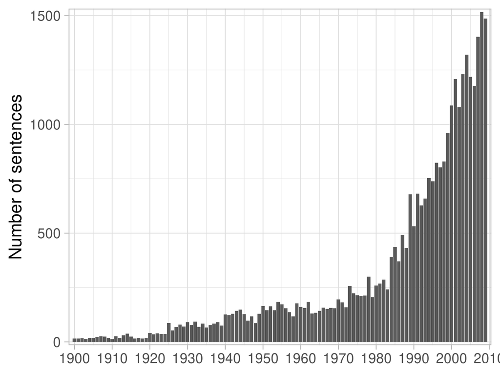

### Closest sentence from ‘rational’ and ‘rationality’ of the backbone community

| Sentence | Title | Year | Journal | Authors | Words Similarity |
| --- | --- | --- | --- | --- | --- |
| : Modeling Limited Rationality.” | [Economic Valuation by the Method of Paired Comparison, with Emphasis on Evaluation of the Transitivity Axiom](https://http://www.jstor.org/stable/3147054) | 1998 | Land Economics | George L. Peterson, Thomas C. Brown | 0.835 |
| When making their decisions, the agents are assumed to be boundedly rational in two ways. | A dynamic migration model with uncertainty | 1994 | Journal of Economic Dynamics and Control | El-Gamal M.A. | 0.834 |
| This paper is based on the assumption of rational behaviors, which is not particularly realistic (Jap, 2002, 2003). | [Supplier coalitions in on-line reverse auctions: Validity requirements and profit distribution scheme](https://doi.org/10.1016/j.ijpe.2004.10.017) | 2006 | International Journal of Production Economics | Jin M. | 0.832 |
| (P2)associated with the individual rationality constraint. | Long-sighted principal and myopic agents | 1998 | Journal of Mathematical Economics | Demange G. | 0.825 |
| In this paper we tend to take the second view, but formulate the issue of rationality in a somewhat distinctive way. | Household accounts, mental accounts, and savings behaviour: Some old economics rediscovered? | 1995 | Journal of Economic Psychology | Winnett A. | 0.825 |
| When rationality is identified with utility-maximization at the level of particular choices, a choice is rational if and only if it maximizes the expected utility. | [Is the disposition of constrained maximization chosen rationally?](https://doi.org/10.1007/s11238-005-3449-8) | 2005 | Theory and Decision | Roh Y. | 0.824 |
| This discussion is an example of a more general tendency to define rationality not in substantive terms, with an agent’s choices deemed rational (or not), but in procedural terms, applying the labels … | [Modeling Knowledge in Economic Analysis](https://http://www.jstor.org/stable/3217177) | 2004 | Journal of Economic Literature | Larry Samuelson | 0.823 |
| rationality must itself be rational, if only in the weaker bounded sense.4 The argument being put forth here is that the decision to choose some long-run level of rational behavior is itself the outco… | Rationally determined irrationality: An extension of the thesis of rationality as anti-entropic | 1989 | Journal of Economic Psychology | Devinney T. | 0.821 |
| In this article we argue that the problem lies in the standard definition of rationality, which is narrow and exclusively based on testing whether or not we optimize expected utility. | [The topology of fear](https://doi.org/10.1016/j.jmateco.2009.06.006) | 2009 | Journal of Mathematical Economics | Chichilnisky G. | 0.820 |
| rationality in a general setup. | [Recurrent Hyperinflations and Learning](https://http://www.jstor.org/stable/3132138) | 2003 | The American Economic Review | Albert Marcet, Juan P. Nicolini | 0.820 |
| pretation implied by rationality models. | [Institutions and Credible Commitment](https://http://www.jstor.org/stable/40751576) | 1993 | Journal of Institutional and Theoretical Economics (JITE) / Zeitschrift für die gesamte Staatswissenschaft | Douglass C. North | 0.816 |
| First, I present a model of limited rationality based on the approach described above. | [How to Decide How to Decide How to…: Modeling Limited Rationality](https://http://www.jstor.org/stable/2938176) | 1991 | Econometrica | Barton L. Lipman | 0.816 |
| Though the particular manifestation of bounded rationality may play a role here, e.g. | [Legal Responses to Bounded Rationality in German Administration: Comment](https://http://www.jstor.org/stable/40753030) | 1994 | Journal of Institutional and Theoretical Economics (JITE) / Zeitschrift für die gesamte Staatswissenschaft | Rupert Windisch | 0.816 |
| Contrary to the conventional wisdom, the present model concludes that under rational | [Rational Expectations and the Optimal Foreign Exchange Regimes](https://http://www.jstor.org/stable/134676) | 1982 | The Canadian Journal of Economics / Revue canadienne d’Economique | Kenneth S. Chan | 0.815 |
| Depending on whether one believes in the ideal of full rationality or not (we deliberately do not take a stance on this issue here), there are two ways to interpret the contributions of this paper. | [Equilibrium stock return dynamics under alternative rules of learning about hidden states](https://doi.org/10.1016/j.jedc.2003.09.003) | 2004 | Journal of Economic Dynamics and Control | Brandt M.W. | 0.815 |
| RELAXATION OF RATIONALITY POSTULATES A not uncommon activity of decision, game, and economic theorists since the fifties has been to call attention to the strength of various postulates of rationality… | [Rationality and bounded rationality](https://doi.org/10.1006/game.1997.0585) | 1997 | Games and Economic Behavior | Aumann R.J. | 0.815 |
| –individual rationality constraints(1)∀iUi(ci)≥0∀ci∈Δi | [A political economy analysis of preferential public procurement policies](https://doi.org/10.1016/j.ejpoleco.2004.03.006) | 2005 | European Journal of Political Economy | Mougeot M. | 0.814 |
| In this regard, we refer to the concept of rationality expressed by Kreps (1998) and McFadden (1999). | [Layers and mechanisms: A new taxonomy for the Bullwhip Effect](https://doi.org/10.1016/j.ijpe.2005.10.001) | 2006 | International Journal of Production Economics | Miragliotta G. | 0.814 |
| In this setting of bounded rationality, there are multiple groups of agents, who condition their expectations on different types of information. | [Behavioural heterogeneity and shift-contagion: Evidence from the Asian crisis](https://doi.org/10.1016/j.jedc.2009.06.002) | 2009 | Journal of Economic Dynamics and Control | de Jong E. | 0.814 |
| The paper is structured as follows; in the next section we outline the generally accepted description of rationality, and using this description, we define the three orders of rationality that the exp… | [An experiment on rational insurance decisions](https://doi.org/10.1023/A:1015559127778) | 2001 | Theory and Decision | Watt R. | 0.812 |
| Bounded rationality models study the implications of different assumptions on the rationality of agents for the outcomes of the strategic situations with which they are dealing. | [Computational Complexity and Communication: Coordination in Two-Player Games](https://http://www.jstor.org/stable/3082024) | 2002 | Econometrica | Amparo Urbano, Jose E. Vila | 0.812 |

### Closest sentences of the backbone community’s centroid

Sentence

Title

Year

Journal

Authors

Similarity to Backbone Centroid

6. ieS This assumption of rationality is very strong and, as the authors point out, can be weakened somewhat.

[On the Applicability of Game Theory in Economics: A Survey](https://http://www.jstor.org/stable/3438941)

1966

The Swedish Journal of Economics

Jan Odhnoff

0.883

(Theoretical arguments against the primacy of the rationality assumptions are raised later in this essay.)

[The Approach of Institutional Economics](https://http://www.jstor.org/stable/2564954)

1998

Journal of Economic Literature

Geoffrey M. Hodgson

0.865

An important approach to discussing the notion of rationality may be found in .

[Choice functions: Rationality re-examined](https://doi.org/10.1023/A:1005202626761)

2000

Theory and Decision

Subiza B.

0.858

However, the implications of more “rationality” will be considered, as well as whether the label is always being correctly applied.4 Two related ideas will be presented.

[Contract Theory and the Moderation of Inflation by Recession and by Controls](https://http://www.jstor.org/stable/2534370)

1976

Brookings Papers on Economic Activity

Martin Neil Baily, William D. Nordhaus, Christopher A. Sims

0.856

Alternative models based on more stringent assumptions of rationality tend to show that this is not necessarily the case.

[A note on critical masses, network externalities and converters](https://doi.org/10.1016/j.ijindorg.2004.01.005)

2004

International Journal of Industrial Organization

Andreozzi L.

0.851

As a result of this controversy several alternatives to the rationality assumption have been suggested over time.

[Responders Versus Non-Responders: A New Perspective on Heterogeneity](https://http://www.jstor.org/stable/2234428)

1991

The Economic Journal

John Haltiwanger, Michael Waldman

0.849

Though the particular manifestation of bounded rationality may play a role here, e.g.

[Legal Responses to Bounded Rationality in German Administration: Comment](https://http://www.jstor.org/stable/40753030)

1994

Journal of Institutional and Theoretical Economics (JITE) / Zeitschrift für die gesamte Staatswissenschaft

Rupert Windisch

0.847

This paper will analyze views of rationality that could underlie such claims.

[On the possibility of rational dilemmas: An Axiomatic Approach](https://doi.org/10.1017/S0266267100005095)

1993

Economics and Philosophy

Cubitt R.

0.845

For this reason, it is interesting to explore implications of the previous analyses in terms of the alternatives to the unconstrained rationality assumption that have been proposed.

An analytic approach to the study of gun control policies

2001

Socio Economic Planning Sciences

Correa H.

0.844

The concept of near-rationality is introduced.

[A Near-Rational Model of the Business Cycle, With Wage and Price Inertia](https://http://www.jstor.org/stable/1882925)

1985

The Quarterly Journal of Economics

George A. Akerlof, Janet L. Yellen

0.843

This particular extension of the concept of rationality seems to have made an appearance in the literature only very recently (Copeland (

[Market Efficiency Before and After the Crash](https://http://www.jstor.org/stable/24437222)

1989

Fiscal Studies

LAURENCE S. COPELAND

0.843

Depending on whether one believes in the ideal of full rationality or not (we deliberately do not take a stance on this issue here), there are two ways to interpret the contributions of this paper.

[Equilibrium stock return dynamics under alternative rules of learning about hidden states](https://doi.org/10.1016/j.jedc.2003.09.003)

2004

Journal of Economic Dynamics and Control

Brandt M.W.

0.841

In this regard, we refer to the concept of rationality expressed by Kreps (1998) and McFadden (1999).

[Layers and mechanisms: A new taxonomy for the Bullwhip Effect](https://doi.org/10.1016/j.ijpe.2005.10.001)

2006

International Journal of Production Economics

Miragliotta G.

0.841

First, we introduce individual rationality, an innocuous restriction that might be viewed as implicit in Hermalin and Katz’s statement.

[Implementing the First Best in an Agency Relationship with Renegotiation: A Corrigendum](https://http://www.jstor.org/stable/2692228)

2001

Econometrica

Aaron S. Edlin, Benjamin E. Hermalin

0.841

In Section 3, I discuss alternative ways, and propose a certain way, of defining ‘rationality’.

[The epistemic structure of a theory of a game](https://doi.org/10.1007/BF01079204)

1994

Theory and Decision

Bacharach M.

0.840

### Closest sentences of each HDBSCAN cluster’s centroid composing the backbone community

| Sentence | Title | Year | Journal | Authors | Similarity to HDSBSCAN Centroid |
| --- | --- | --- | --- | --- | --- |
| Here is presented a frtlitful field for the work of a speculative philosopller; but this paper is presumed to treat only o-f actualities, of stubborn, difficult, irresistible facts, and I shall not ve… | [Conciliation and Arbitration in the Coal Mining Industry](https://www.jstor.org/stable/10.2307/2485768) | 1902 | Publications of the American Economic Association | Herman Justi | 0.632 |
| the soundness of such underlying theories. | [Notes on Imports Versus Home Production, and Home Versus Foreign Investments](https://http://www.jstor.org/stable/2221170) | 1905 | The Economic Journal | Robert Giffen | 0.614 |
| At one point we find, for example, such marks of staleness as tedious mathematical elaborations of truisms in the theory of exchange; at another point a brilliant but uncrystallized theory of interest… | [Jevons’ “Theory of Political Economy.”](https://http://www.jstor.org/stable/1804593) | 1912 | The American Economic Review | Allyn A. Young | 0.591 |
| In this paper an attempt is made to demonstrate the fundamental importance of this distinction, and to indicate its logical significance. | [The Social Point of View in Economics](https://http://www.jstor.org/stable/1884931) | 1913 | The Quarterly Journal of Economics | Lewis H. Haney | 0.585 |
| Under such circumstances the point at issue becomes more than a mere question of theory. | [Mercantile and Agricultural Economics](https://http://www.jstor.org/stable/1823122) | 1918 | Journal of Political Economy | C. S. Duncan | 0.584 |
| The assumption, on which a theory is built, is thus treated as if its own truth to fact were demonstrated by the convenience of the theory based upon it; and the yet more hazardous corollary of practi… | [Economic Theory and Fiscal Policy](https://http://www.jstor.org/stable/2221360) | 1904 | The Economic Journal | L. L. Price | 0.583 |
| This result may be reached from various points of view. | [Value in Its Relation to Interest](https://http://www.jstor.org/stable/1819589) | 1901 | Journal of Political Economy | R. S. Padan | 0.573 |
| Tllere are certain considerations that make such a view reasonable. | [Rent in Modern Economic Theory: An Essay in Distribution](https://www.jstor.org/stable/10.2307/2485785) | 1902 | Publications of the American Economic Association | Alvin Saunders Johnson | 0.573 |
| selves as admitting a truth in the theory, provided, “other things remain equal/’ but directly deny that other things do remain 1 Moody’s Magazinef September, 1906. | [The Standard of Value and Prices](https://http://www.jstor.org/stable/1820833) | 1907 | Journal of Political Economy | Ralph H. Hess | 0.569 |
| Apart from the fact that we are dealing with the guesses of interested parties and not with facts, attention should be called to certain general principles. | [The Regulation of Public Service Corporations: The Vagaries of Valuation](https://http://www.jstor.org/stable/1827702) | 1914 | The American Economic Review | John H. Gray | 0.566 |

#### Closes sentences 4_18_1900-1919: student, adams, trustworthy, reasonings, summed (1900-1919)

Sentence

Title

Year

Journal

Authors

Similarity to HDSBSCAN Centroid

mined if men were to act in certain ways under certain assumed circumstances.

[The Futility of Marginal Utility](https://http://www.jstor.org/stable/1820794)

1910

Journal of Political Economy

E. H. Downey

0.511

A folly committed by about 25 persons in a million cannot be said to be an essential part of human nature, and if this number remains the same year after year, it is because there is no reason why it should vary, as long as its causes, which (not lying in human nature) must lie in outward circumstances, remain unaltered.

[On Collective Phenomena and the Scientific Value of Statistical Data](https://www.jstor.org/stable/10.2307/2999937)

1906

Publications of the American Economic Association

Ernest G. F. Gryzanovski

0.503

Under the Darwinian norm it must be held that men’s reasoning is largely controlled by other than logical, intellectual forces; that the conclusion reached by public or class opinion is as much, or more, a matter of sentiment than of logical inference; and that the sentiment which animates men, singly or collectively, is as much, or more, an outcome of habit and native propensity as of calculated material interest.

[The Socialist Economics of Karl Marx and His Followers](https://http://www.jstor.org/stable/1883435)

1907

The Quarterly Journal of Economics

Thorstein Veblen

0.499

.. “The true raison d’etre of theory is that it supplies a machinery to aid us in reasoning about those motives of human action which are measurable.”

[The Statistical Complement of Pure Economics](https://http://www.jstor.org/stable/1883964)

1908

The Quarterly Journal of Economics

Henry L. Moore

0.484

This control of the life of society by the material exigencies takes effect thru men’s taking thought of material (economic) advantages and disadvantages, and choosing that which will yield the fuller material measure of life.

[The Socialist Economics of Karl Marx and His Followers](https://http://www.jstor.org/stable/1883435)

1907

The Quarterly Journal of Economics

Thorstein Veblen

0.483

In order to learn how men will act in a given situation, or how a change in the situation will modify their behavior, it is surely more practical to observe their behavior than to attempt to discover by introspection or otherwise what they might be supposed to do if actuated by a certain motive operating alone.

[Some Problems of Logical Method in Political Economy](https://http://www.jstor.org/stable/1819612)

1917

Journal of Political Economy

J. Viner

0.479

3I0-30) to explain it away, a flavor of utilitarian calculation about this, which, when he first wrote, was inevitable; but that does not concern us just now.

[An Appeal to “The Sober Reader”](https://http://www.jstor.org/stable/1819626)

1916

Journal of Political Economy

Frank A. Fetter

0.479

The result of this unfortunate insulation is that scientific men are unfamiliar with affairs, while business shows a quite remarkable neglect of the most obvious and assured results of science, or, if you like it better, shows a complete freedom from scientific bias.

[The Nature of the Industrial Struggle](https://http://www.jstor.org/stable/2222291)

1917

The Economic Journal

H. S. Foxwell

0.478

What men have learned to accept as good and definitive for the guidance of conduct and of human relations remains true and definitive and unimpeachable until the exigencies of a later, altered situation enforce a variation from the norms anld canons of the past, and so give rise to a modification of the habits of thought that decide what is, for the time, right in human conduct.

[The Preconceptions of Economic Science](https://http://www.jstor.org/stable/1883770)

1900

The Quarterly Journal of Economics

Thorstein Veblen

0.473

1. Some may regard the members of society as merely conscious of the existence of like ideas in the minds of their fellows; (2) others may go further, and make society depend upon a consciousness of like interests and purposes, and a consciousness not merely that those like interests and purposes exist but that each one is conscious that every other is aware of his interests and purposes.

[The Social Point of View in Economics](https://http://www.jstor.org/stable/1884931)

1913

The Quarterly Journal of Economics

Lewis H. Haney

0.471

| Sentence | Title | Year | Journal | Authors | Similarity to HDSBSCAN Centroid |
| --- | --- | --- | --- | --- | --- |
| Given corresponding conditions, like doctrines may be anticipateddiffering only as the personal equation shades the image or as new instruments of precision render it more exact. | [The Economist’s Spiral](https://http://www.jstor.org/stable/1801764) | 1922 | The American Economic Review | Jacob H. Hollander | 0.618 |
| His answer is in terms of the logico-methodological system more especially of Rickert and Windelband, by pointing to the necessity of strictly separating empirical knowledge from value-judgments. | [The Life and Work of Max Weber](https://http://www.jstor.org/stable/1885770) | 1923 | The Quarterly Journal of Economics | Carl Diehl | 0.607 |
| Our interest in simplicity and definiteness has at some point to yield to other interests with which it comes into conflict and which cannot be denied. | [Fact and Metaphysics in Economic Psychology](https://http://www.jstor.org/stable/1807116) | 1925 | The American Economic Review | Frank H. Knight | 0.605 |
| the principle under consideration. | [Theoretical Considerations Relating to Supply](https://http://www.jstor.org/stable/1820866) | 1927 | Journal of Political Economy | Henry Schultz | 0.594 |
| Such a theory, quite inchoate as it is, is given a tentative statement in the propositions which follow. | [A Theory of the Rate of Wages](https://http://www.jstor.org/stable/1884753) | 1922 | The Quarterly Journal of Economics | Walton H. Hamilton | 0.583 |
| On the plane of popular argumentation these conclusions might be taken to settle the practical issue. | [Co-operative Societies and Income Tax](https://http://www.jstor.org/stable/2223009) | 1920 | The Economic Journal | A. C. Pigou | 0.574 |
| Here, as in the case of other assumptions, it is illegitimate to draw practical conclusions from a “tendency,” however real, without taking account of contradictory tendencies also, and getting the fa… | [The Ethics of Competition](https://http://www.jstor.org/stable/1884053) | 1923 | The Quarterly Journal of Economics | Frank H. Knight | 0.570 |
| They develop their argument partly by means of a series of hypothetical “Cases,” partly with the aid of more general reasoning and an appeal to statistics. | [The Monetary Doctrines of Messrs. Foster and Catchings](https://http://www.jstor.org/stable/1885921) | 1929 | The Quarterly Journal of Economics | D. H. Robertson | 0.568 |
| Insistence on the test of consequences in all fields. | [Notes on the Life and Work of Simon Nelson Patten](https://http://www.jstor.org/stable/1822302) | 1923 | Journal of Political Economy | Rexford G. Tugwell | 0.566 |
| It is natural that attempts to fit an empirical generalization into the existing body of a priori knowledge and thus transform it into a rational law should begin by analogy, and it is desirable at th… | [Is There a Biological Law of Human Population Growth?](https://http://www.jstor.org/stable/1884883) | 1927 | The Quarterly Journal of Economics | A. B. Wolfe | 0.565 |

| Sentence | Title | Year | Journal | Authors | Similarity to HDSBSCAN Centroid |
| --- | --- | --- | --- | --- | --- |
| The ideas of a mental and of a social mechanism are plainly present in the essay, but he insists that “reason” is free to play, or not to play, its part well in the process of the equilibration of “mo… | [Economics and the Idea of Natural Laws](https://http://www.jstor.org/stable/1885439) | 1929 | The Quarterly Journal of Economics | O. H. Taylor | 0.650 |
| In practice, our contention is that it must be assumed both that force is more than phenomenal uniformity of sequence, and that human motives are more than mechanical forces If the practical necessiti… | [Economic Psychology and the Value Problem](https://http://www.jstor.org/stable/1882434) | 1925 | The Quarterly Journal of Economics | Frank H. Knight | 0.645 |
| The motives of individuals, which are the ultimate “forces” dealt with in this type of theory, are themselves changeable, and do change, as civilization develops; nor can we afford to admit that this … | [Economics and the Idea of Natural Laws](https://http://www.jstor.org/stable/1885439) | 1929 | The Quarterly Journal of Economics | O. H. Taylor | 0.631 |
| For, if we acknowledge that man’s behavior is not uniquely volitional, but is a natural phenomenon, we see at once that it must be, like all other phenomena, an affair of antecedent and consequent and… | [The Emancipation of Economics](https://http://www.jstor.org/stable/1809282) | 1924 | The American Economic Review | Lawrence K. Frank | 0.626 |
| He deduces certain laws of necessity, of variety, of harmony, of cost, of grouping, and of negative utility.2 But they are based on his own conception of human nature again, which, of course, being mo… | [Human Nature in Economic Theory](https://http://www.jstor.org/stable/1822708) | 1922 | Journal of Political Economy | Rexford G. Tugwell | 0.625 |
| They are not objectively observable, not scientific data, except in a sense which makes the hedonistic analysis purely a tautology.5 Furthermore, he argues, attempts to apply scientific logic to value… | [Professor Knight on Psychology](https://http://www.jstor.org/stable/1885818) | 1925 | The Quarterly Journal of Economics | Morris A. Copeland | 0.614 |
| Motives will not be disregarded, but they will be treated as problems requiring study, instead of being taken for granted as constituting explanations. | [Quantitative Analysis in Economic Theory](https://http://www.jstor.org/stable/1808475) | 1925 | The American Economic Review | Wesley C. Mitchell | 0.606 |
| That is, we have to recognize men’s conscious interests not only as existent and causal and explanatory in the descriptive, scientific sense, as data in a uniformity of sequence, but as causal and exp… | [Fact and Metaphysics in Economic Psychology](https://http://www.jstor.org/stable/1807116) | 1925 | The American Economic Review | Frank H. Knight | 0.603 |
| Given this instrument of analysis the investigator may compare with it the actual record of events in many different instances and thus attempt to “understand” them, each in its individual uniqueness,… | [“Capitalism” in Recent German Literature: Sombart and Weber (Concluded)](https://http://www.jstor.org/stable/1822319) | 1929 | Journal of Political Economy | Talcott Parsons | 0.603 |
| Second, that it is not an individual motive. | [Motives and Standards in Industry](https://http://www.jstor.org/stable/2222913) | 1923 | The Economic Journal | D. H. Macgregor | 0.603 |

| Sentence | Title | Year | Journal | Authors | Similarity to HDSBSCAN Centroid |
| --- | --- | --- | --- | --- | --- |
| Optimistic interpretations of the rationalisation process will generally be found to be based upon the assumption that what is true in some cases is necessarily true in all. | [Rationalisation and Technological Unemployment](https://http://www.jstor.org/stable/2224241) | 1930 | The Economic Journal | T. E. Gregory | 0.662 |
| But in the world as it is, where this is not known, the terms “rational” and “sensible” are usually applied to the expectations , or the process of arriving at the expectations , that one line of cond… | [Expectation and Rational Conduct](https://http://www.jstor.org/stable/41793308) | 1937 | Zeitschrift für Nationalökonomie / Journal of Economics | T. W. Hutchison | 0.647 |
| But such a view is hardly in accord with common sense; the ordinary meaning of rationality is anticipation-motivation “correctly” directing action in relation to the future. | [The Quantity of Capital and the Rate of Interest: II](https://http://www.jstor.org/stable/1824134) | 1936 | Journal of Political Economy | Frank H. Knight | 0.630 |
| It should be noted that the ideal type of rational action in the present passage includes the further condition that the objective relation between niens and ends is correctly grasped by the actor. | [A New Approach to the Methodology of the Social Sciences](https://http://www.jstor.org/stable/2626877) | 1937 | Economica | Alfred Stonier, Karl Bode | 0.625 |
| Granting that the assumption of the rational pursuit of gain is a simplying assumption, one may ask whether it does great violence to reality. | [Thoughts on Perusal of Wesley Mitchell’s Collected Essays](https://http://www.jstor.org/stable/1829688) | 1939 | Journal of Political Economy | A. B. Wolfe | 0.607 |
| Of course, the principle must be applied rationally. | [A Statistical Study of Bank Clearings, 1875-1914](https://http://www.jstor.org/stable/1927180) | 1930 | The Review of Economics and Statistics | Edwin Frickey | 0.606 |
| An individual in planning for the future may ’rationally” plan for ups and downs in the distribution of his expenditure over time. | [Some Issues in the Economics of Stationary States](https://http://www.jstor.org/stable/1802721) | 1936 | The American Economic Review | Frank H. Knight | 0.602 |
| This is the assumption of rational conduct, i.e., conduct in accordance with a plan, which will be discussed in more detail below. | [Collected Works of Carl Menger](https://http://www.jstor.org/stable/1891101) | 1936 | The Quarterly Journal of Economics | Alan R. Sweezy | 0.600 |
| The terms “sensible” and “rational” cannot then be applied to conduct under conditions of perfect foresight in the same sense in which they are usually loosely applied to conduct in the world as it is… | [Expectation and Rational Conduct](https://http://www.jstor.org/stable/41793308) | 1937 | Zeitschrift für Nationalökonomie / Journal of Economics | T. W. Hutchison | 0.599 |
| That would involve a wider meaning of rationality than is under consideration here. | [Wants and Activities in Marshall](https://http://www.jstor.org/stable/1883923) | 1931 | The Quarterly Journal of Economics | Talcott Parsons | 0.596 |

Sentence

Title

Year

Journal

Authors

Similarity to HDSBSCAN Centroid

The theories to be taken up explicitly in the remainder of this study will be chosen with a view not to encyclopedic completeness, but rather to illustrate each of the principal logical possibilities inherent in the situation just sketched.

[Sociological Elements in Economic Thought](https://http://www.jstor.org/stable/1883862)

1935

The Quarterly Journal of Economics

Talcott Parsons

0.679

Sometimes more emphasis has been laid on the purely hypothetical nature of the principle as a starting point for a deductive argument, while sometimes it is urged, rather, that the principle is in fact, roughly at any rate, an empirically true generalisation2).

[Expectation and Rational Conduct](https://http://www.jstor.org/stable/41793308)

1937

Zeitschrift für Nationalökonomie / Journal of Economics

T. W. Hutchison

0.643

The different cases resulting from the two assumptions may be expected to call for different decisions in matters of B.I.S.

[Notes on the International Bank and the Creation of Credit](https://http://www.jstor.org/stable/2548226)

1930

Economica

P. Barrett Whale

0.615

14. of the neo-classical treatment of the theory of interest, it should be noted that circular reasoning (such as he here attacks) can be found in all partial analyses of isolated factors in which it is necessarily assumed that “other things remain equal.”

[Mr. Keynes on Underemployment Equilibrium](https://http://www.jstor.org/stable/1824136)

1936

Journal of Political Economy

Alvin H. Hansen

0.607

The theory here considered is more fundamental or simple; it is logically prior to the considerations regarding lack

[An Essay in Dynamic Theory](https://http://www.jstor.org/stable/2225181)

1939

The Economic Journal

R. F. Harrod

0.602

There must be some presumption about the field in which the events take place.

[Francis Ysidro Edgeworth](https://http://www.jstor.org/stable/1906895)

1934

Econometrica

Arthur L. Bowley

0.599

In this analysis I show that three different meanings have been confused in the interpretation of this principle.

[Do Synthetic Propositions a Priori Exist in Economics: A Reply to Dr. Bernardelli](https://http://www.jstor.org/stable/2548958)

1937

Economica

Felix Kaufmann

0.596

When once the connection between objective facts and anticipations has been made, theory comes again into its rights; and it will not be able to complain of a lack of opportunities.

[A Suggestion for Simplifying the Theory of Money](https://http://www.jstor.org/stable/2549103)

1935

Economica

J. R. Hicks

0.592

We shall see later whether this particular assumption has any merits which would justify one in regarding it as a particularly significant, or as representing in any sense the normal case.

[Utility Analysis and Interest](https://http://www.jstor.org/stable/2225131)

1936

The Economic Journal

F. A. v. Hayek

0.591

Once these assumptions have been specified and have gained general acceptance as the limits within which deductive speculation must proceed, any new elements subsequently discovered which play a role in shaping the course of events are likely to be put down as ” causes of indeterminateness” since the human mind finds it easier to alter the conclusions arrived at within an accepted framework, than to alter the framework itself.

[A Classificatory Note on the Determinateness of Equilibrium](https://http://www.jstor.org/stable/2967618)

1934

The Review of Economic Studies

Nicholas Kaldor

0.586

| Sentence | Title | Year | Journal | Authors | Similarity to HDSBSCAN Centroid |
| --- | --- | --- | --- | --- | --- |
| Since the war some excellent philosophical things have been written about what has been termed the psychological or behavioristic equilibrium theory of history. | [ECONOMIC PLANNING AS APPLIED TO AGRICULTURE](https://www.jstor.org/stable/10.2307/44643291) | 1932 | Proceedings of the Annual Meeting (Western Farm Economics Association) | M. L. Wilson | 0.590 |
| In light of such propositions the course of history may be predicted and social judgments of the current scheme fashioned. | [Types of Institutionalism](https://http://www.jstor.org/stable/1822897) | 1932 | Journal of Political Economy | Abram L. Harris | 0.548 |
| From this it draws the conclusion that the correlations between these different social phenomena can be stated in terms of general laws, which allow the formation of reasonably valid interpretations o… | [On Medieval History as a Social Study](https://http://www.jstor.org/stable/2548572) | 1934 | Economica | Eileen Power | 0.538 |
| reached by public or class opinion is as much, or more, a matter of sentiment than of logical inference; and that the sentiment which animates men, singly or collectively, is as much, or more, an outc… | [Economic Evolution: Dialectical and Darwinian](https://http://www.jstor.org/stable/1830603) | 1934 | Journal of Political Economy | Abram L. Harris | 0.526 |
| To gain in depth what is lost in extent, it is then necessary to enlarge the frame of the theoretical schema, adding to the residues and to the social flexibility the consideration of two other elemen… | [Vilfredo Pareto](https://http://www.jstor.org/stable/1910081) | 1938 | Econometrica | Luigi Amoroso | 0.523 |
| For in so far as ends - in this case the integrated systems of ultimate ends of individuals - are real factors in action, to the same degree they cannot be completely determined in their nature or lim… | [Some Reflections on “The Nature and Significance of Economics”](https://http://www.jstor.org/stable/1882825) | 1934 | The Quarterly Journal of Economics | Talcott Parsons | 0.499 |
| If one deals with a social philosophy, one may derive from precisely measured facts the starting points and a notion as to the limited character of the conclusions, in so far as an application to real… | [Static and Dynamic Economics](https://http://www.jstor.org/stable/1802588) | 1930 | The American Economic Review | Simon Kuznets | 0.497 |
| in the absence of - a framework of socially integrated ultimate ends is unreal and I think very nearly unusable, it does not follow that within such a framework certain elements of action cannot usefu… | [Some Reflections on “The Nature and Significance of Economics”](https://http://www.jstor.org/stable/1882825) | 1934 | The Quarterly Journal of Economics | Talcott Parsons | 0.497 |
| Underlying its generalizations of human action, therefore, is the “belief in a meliorative trend” which exercises “a constraining guidance over the course of causes and effects.” | [Types of Institutionalism](https://http://www.jstor.org/stable/1822897) | 1932 | Journal of Political Economy | Abram L. Harris | 0.491 |
| Applying the same considerations to man, he that would pass judgment upon all human activities, movements, relations, etc., in accordance with the principle of utility, must first become acquainted wi… | [Types of Institutionalism](https://http://www.jstor.org/stable/1822897) | 1932 | Journal of Political Economy | Abram L. Harris | 0.491 |

| Sentence | Title | Year | Journal | Authors | Similarity to HDSBSCAN Centroid |
| --- | --- | --- | --- | --- | --- |
| Here the assumption is indefinite in meaning, involving arbitrary limitations on the business man’s expectations of consequences, which involve logical dilemmas, and involving also simplification of t… | [Mathematical Economists and Others: A Plea for Communicability](https://http://www.jstor.org/stable/1907065) | 1947 | Econometrica | J. M. Clark | 0.643 |
| Another example is offered of belief-valuation conflicts, in which the reader will note a relationship to that conflict pointed up above (for, as Myrdal shows, beliefs and valuations tend to form syst… | [The Bureau of Agricultural Economics under Fire: A Study in Valuation Conflicts](https://http://www.jstor.org/stable/1232500) | 1946 | Journal of Farm Economics | Charles M. Hardin | 0.628 |
| 9 The effect of assumptions Nos. | [Monetary Effects of Wartime Social Security Taxes](https://http://www.jstor.org/stable/1826620) | 1942 | Journal of Political Economy | Alex Moses Rosenson | 0.624 |
| The important problem is which set of assumptions most nearly fits the actual situation at a given time. | [The Future of Keynesian Economics](https://http://www.jstor.org/stable/1811442) | 1945 | The American Economic Review | David McCord Wright | 0.609 |
| Some will seem to involve assumptions which conflict with elements in the present situation, and therefore to involve the further assumption that special factors will arise, of which there is no evide… | [The Expectational Dynamics of the Individual](https://http://www.jstor.org/stable/2549459) | 1943 | Economica | G. L. Shackle | 0.607 |
| The obvious type of assumption to make if satisfactory conclusions are wanted is that the business man attaches quantitative ” probabilities ” to the different contingencies he considers possible. | [Uncertainty and Inducements to Invest](https://http://www.jstor.org/stable/2967417) | 1940 | The Review of Economic Studies | Albert Gailord Hart | 0.604 |
| When the working out of generalizations on the basis of the unreal and relatively few assumptions described earlier is abandoned, one is faced with a bewildering array of conditions about which assump… | [Price Policies](https://http://www.jstor.org/stable/1052213) | 1945 | Southern Economic Journal | A. G. Abramson | 0.601 |
| We proceed on a different set of assumptions. | [Comparisions of Power Cost for Atomic and Conventional Steam Stations](https://http://www.jstor.org/stable/1927747) | 1949 | The Review of Economics and Statistics | Walter Isard, John B. Lansing | 0.601 |
| Second, to generalize the problem of the “conjectural hypotheses” made by one competitor as to his rival’s behavior. | [Equilibrium in Monopolistic Competition](https://http://www.jstor.org/stable/1881668) | 1940 | The Quarterly Journal of Economics | A. Smithies | 0.598 |
| In this instance, our fundamental assumptions are less extensive and, accordingly, less remote from reality; but the theoretical analysis here becomes necessarily less clear-cut and more difficult. | [ECONOMIC STRUCTURE AND PLANNING](https://http://www.jstor.org/stable/40747258) | 1948 | Zeitschrift für die gesamte Staatswissenschaft / Journal of Institutional and Theoretical Economics | THEO SURÁNYI-UNGER | 0.594 |

| Sentence | Title | Year | Journal | Authors | Similarity to HDSBSCAN Centroid |
| --- | --- | --- | --- | --- | --- |
| This short analysis shows that we cannot speak of an isolated rational act, if we mean by this an act resulting from deliberated choice, but only of a system of rational acts.’ | [The Problem of Rationality in the Social World](https://http://www.jstor.org/stable/2549460) | 1943 | Economica | Alfred Schuetz | 0.690 |
| It seems that we have to distinguish between the rationality of knowledge which is a prerequisite of the rational choice and the rationality of the choice itself. | [The Problem of Rationality in the Social World](https://http://www.jstor.org/stable/2549460) | 1943 | Economica | Alfred Schuetz | 0.683 |
| Rational individual behavior can be considered to require that the ranking of a given change be unaffected by the number of steps in which that change is made. | [Measuring Marginal Utility by Reactions to Risk](https://http://www.jstor.org/stable/1906925) | 1945 | Econometrica | William Vickrey | 0.657 |
| If the laws deduced from the postulate of rationality are to serve as a basis of making predictions about the decisions of units encountered in experience, this postulate must be treated as an empiric… | [The Scope and Method of Economics](https://http://www.jstor.org/stable/2296113) | 1945 | The Review of Economic Studies | O. Lange | 0.655 |
| Rationality of knowledge is given only if all the elements from which the actor has to choose are clearly and distinctly conceived by him. | [The Problem of Rationality in the Social World](https://http://www.jstor.org/stable/2549460) | 1943 | Economica | Alfred Schuetz | 0.624 |
| Thus, the postulate of rationality is a short-cut to the discovery of laws governing the decisions of units and to the prediction of their actions under given circumstances. | [The Scope and Method of Economics](https://http://www.jstor.org/stable/2296113) | 1945 | The Review of Economic Studies | O. Lange | 0.618 |
| It has been only in recent years that the whole field of “irrational” behavior responses as related to “ideologies” has received considerable and rather sudden attention from the American social scien… | [Ideology as a Means of Social Control, I](https://http://www.jstor.org/stable/3483886) | 1943 | The American Journal of Economics and Sociology | Joseph S. Roucek | 0.607 |
| In order to answer this question we must analyse the various equivocal implications which are hidden in the term ” rationality” as it is applied to the level of every-day experience. | [The Problem of Rationality in the Social World](https://http://www.jstor.org/stable/2549460) | 1943 | Economica | Alfred Schuetz | 0.606 |
| A rational act presupposes, according to the interpretation of other authors, a choice between two or more means toward the same end, or even between two different ends, and a selection of the most ap… | [The Problem of Rationality in the Social World](https://http://www.jstor.org/stable/2549460) | 1943 | Economica | Alfred Schuetz | 0.603 |
| THE POSTULATE OF RATIONALITY. | [The Scope and Method of Economics](https://http://www.jstor.org/stable/2296113) | 1945 | The Review of Economic Studies | O. Lange | 0.602 |

| Sentence | Title | Year | Journal | Authors | Similarity to HDSBSCAN Centroid |
| --- | --- | --- | --- | --- | --- |
| One may perhaps put aside the logical incoherences when one is faced with rival claims to certainty; one of them, but only one, may be justified in the claim, and the wrong one may actually gain power… | [The Modern Party State](https://http://www.jstor.org/stable/137721) | 1949 | The Canadian Journal of Economics and Political Science / Revue canadienne d’Economique et de Science politique | H. McD. Clokie | 0.594 |
| It is only in the very simplest instances that it can be shown briefly and without any technical apparatus how the independent actions of individuals will produce an order which is no part of their in… | [Scientism and the Study of Society. Part I](https://http://www.jstor.org/stable/2549540) | 1942 | Economica | F. A. v. Hayek | 0.568 |
| It may be supposed that the social events in reality attributable to the motives of free men are rather to be subject to “causal laws” of the natural science type. | [The Welfare Economics of Heinrich Pesch](https://http://www.jstor.org/stable/1882259) | 1949 | The Quarterly Journal of Economics | Richard E. Mulcahy, S.J. | 0.565 |
| Any discipline of knowledge, whether theoretical or historical, can, however, deal only with certain selected aspects of the real world; and in the theoretical sciences the principle of selection is t… | [Scientism and the Study of Society. Part II](https://http://www.jstor.org/stable/2549653) | 1943 | Economica | F. A. v. Hayek | 0.551 |
| Other results of his analysis he introduced by means of the device of retaining the original-ideological-statement as an “absolute” (i.e., abstract) law while admitting the existence of counteracting … | [Science and Ideology](https://http://www.jstor.org/stable/1812737) | 1949 | The American Economic Review | Joseph A. Schumpeter | 0.542 |
| To him every specific act has a specific cause and, though among these causes may be a Variety of social forces including those powerful forces which we call ideas, he is inclined to see these forces … | [The East India Company in Eighteenth-Century Politics](https://http://www.jstor.org/stable/2590689) | 1947 | The Economic History Review | L. S. Sutherland | 0.534 |
| Here much will depend upon the flux in men’s ideas, mentioned but not discussed earlier in this paper. | [The Effects of the War on Price Policies and Price Making](https://http://www.jstor.org/stable/1815138) | 1942 | The American Economic Review | John D. Sumner | 0.533 |
| M. R. Cohen, Reasonz anid Nature, p. 356: ” If, then, social phenomena depenid upon more factors than we can readily manipulate, even the doctrine of universal determinism will not guarantee an attain… | [Scientism and the Study of Society. Part I](https://http://www.jstor.org/stable/2549540) | 1942 | Economica | F. A. v. Hayek | 0.532 |
| Social life depends more and more on a consensus with respect to values or purposes that lie beyond ends defined by the psychological fact of desire, much as given ends lie beyond mechanical effects o… | [Immutable Law in Economics: Its Reality and Limitations](https://http://www.jstor.org/stable/1818199) | 1946 | The American Economic Review | Frank H. Knight | 0.528 |
| But if they follow a purely logical or mathematical pattern, why should it be necessary to presuppose any particular institutional order? | [Economic Planning in a Democratic Society](https://http://www.jstor.org/stable/3158972) | 1943 | The Journal of Land & Public Utility Economics | Dudley F. Pegrum | 0.520 |